# UVic Biology R Handbook

## Multi-panel plots

Example using Soils data.

We have pH, N, and P we can plot, by contour and by depth - that can be a 2 by 3 multi-panel plot.

Two ways:

1. Use par(mfrow=c(nrow, ncol)) where nrow is number of rows and ncol is number of columns in your multi-panel.

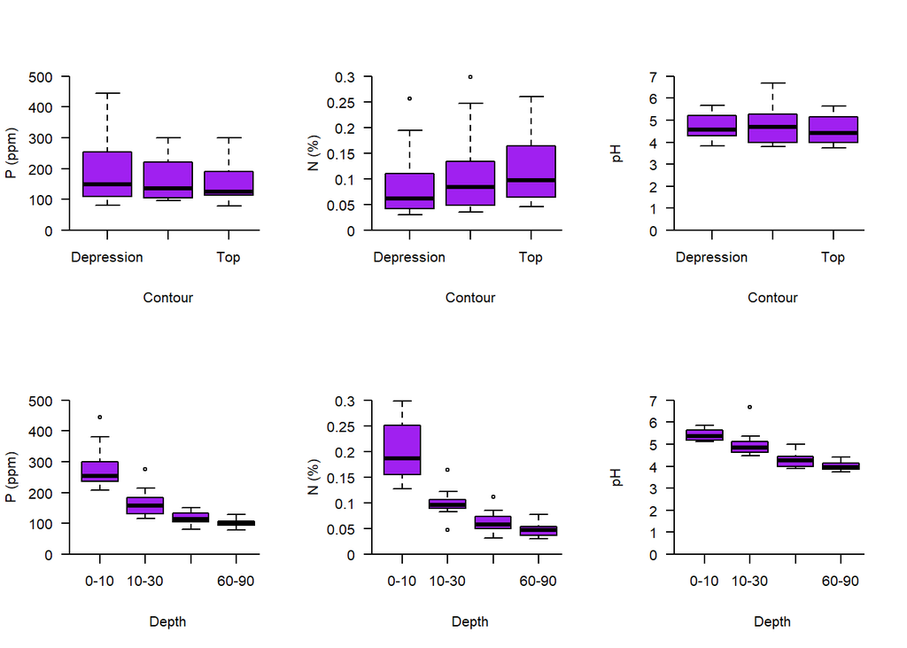

```r
#Use Soils data as example:
library(carData)
data(Soils)

par(mfrow=c(2,3))
#boxplot of P by Contour:
b1<-boxplot(P~Contour, data=Soils, col="purple", frame=F, ylim=c(0,500), axes=F, ylab="P (ppm)", xlab="Contour")
axis(1, labels=levels(Soils$Contour), at=1:3, pos=0)
axis(2, labels=seq(0,500,100), at=seq(0,500,100), las=2)
segments(0,0,3.5,0)

#boxplot of N by Contour:
b2<-boxplot(N~Contour, data=Soils, col="purple", frame=F, ylim=c(0,0.3), axes=F,ylab="N (%)", xlab="Contour")
axis(1, labels=levels(Soils$Contour), at=1:3, pos=0)
axis(2, labels=seq(0,0.3,0.05), at=seq(0,0.3,0.05),las=2)
segments(0,0,3.5,0)

#boxplot of pH by Contour:
b3<-boxplot(pH~Contour, data=Soils, col="purple", frame=F, ylim=c(0,7), axes=F, ylab="pH", xlab="Contour")
axis(1, labels=levels(Soils$Contour), at=1:3, pos=0)
axis(2, labels=seq(0,7,1), at=seq(0,7,1), las=2)
segments(0,0,3.5,0)

#boxplot of P by Depth:
b4<-boxplot(P~Depth, data=Soils, col="purple", frame=F, ylim=c(0,500), axes=F, ylab="P (ppm)", xlab="Depth")
axis(1, labels=levels(Soils$Depth), at=1:4, pos=0)
axis(2, labels=seq(0,500,100), at=seq(0,500,100), las=2)
segments(0,0,4.5,0)

#boxplot of N by Depth:
b5<-boxplot(N~Depth, data=Soils, col="purple", frame=F, ylim=c(0,0.3), axes=F,ylab="N (%)", xlab="Depth")
axis(1, labels=levels(Soils$Depth), at=1:4, pos=0)
axis(2, labels=seq(0,0.3,0.05), at=seq(0,0.3,0.05),las=2)
segments(0,0,4.5,0)

#boxplot of pH by Contour:
b6<-boxplot(pH~Depth, data=Soils, col="purple", frame=F, ylim=c(0,7), axes=F, ylab="pH", xlab="Depth")
axis(1, labels=levels(Soils$Depth), at=1:4, pos=0)
axis(2, labels=seq(0,7,1), at=seq(0,7,1), las=2)
segments(0,0,4.5,0)
```

2. Specify the position of plots in a matrix:

```r
#Take a look at the matrix:
matrix(1:6, byrow=TRUE, ncol=3) #use ncol to specify number of columns
```

```
##      [,1] [,2] [,3]
## [1,]    1    2    3
## [2,]    4    5    6
```

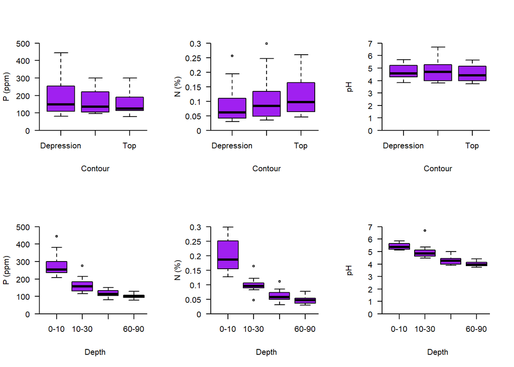

```r
#First plot will be upper left, second upper middle, third, upper left, etc.

nf<-layout(matrix(1:6, byrow=TRUE, ncol=3)) #use a matrix to specify layout

#call the plots again
#boxplot of P by Contour:
b1<-boxplot(P~Contour, data=Soils, col="purple", frame=F, ylim=c(0,500), axes=F, ylab="P (ppm)", xlab="Contour")
axis(1, labels=levels(Soils$Contour), at=1:3, pos=0)
axis(2, labels=seq(0,500,100), at=seq(0,500,100), las=2)
segments(0,0,3.5,0)

#boxplot of N by Contour:
b2<-boxplot(N~Contour, data=Soils, col="purple", frame=F, ylim=c(0,0.3), axes=F,ylab="N (%)", xlab="Contour")
axis(1, labels=levels(Soils$Contour), at=1:3, pos=0)
axis(2, labels=seq(0,0.3,0.05), at=seq(0,0.3,0.05),las=2)
segments(0,0,3.5,0)

#boxplot of pH by Contour:
b3<-boxplot(pH~Contour, data=Soils, col="purple", frame=F, ylim=c(0,7), axes=F, ylab="pH", xlab="Contour")
axis(1, labels=levels(Soils$Contour), at=1:3, pos=0)
axis(2, labels=seq(0,7,1), at=seq(0,7,1), las=2)
segments(0,0,3.5,0)

#boxplot of P by Depth:
b4<-boxplot(P~Depth, data=Soils, col="purple", frame=F, ylim=c(0,500), axes=F, ylab="P (ppm)", xlab="Depth")
axis(1, labels=levels(Soils$Depth), at=1:4, pos=0)
axis(2, labels=seq(0,500,100), at=seq(0,500,100), las=2)
segments(0,0,4.5,0)

#boxplot of N by Depth:
b5<-boxplot(N~Depth, data=Soils, col="purple", frame=F, ylim=c(0,0.3), axes=F,ylab="N (%)", xlab="Depth")
axis(1, labels=levels(Soils$Depth), at=1:4, pos=0)
axis(2, labels=seq(0,0.3,0.05), at=seq(0,0.3,0.05),las=2)
segments(0,0,4.5,0)

#boxplot of pH by Contour:
b6<-boxplot(pH~Depth, data=Soils, col="purple", frame=F, ylim=c(0,7), axes=F, ylab="pH", xlab="Depth")
axis(1, labels=levels(Soils$Depth), at=1:4, pos=0)
axis(2, labels=seq(0,7,1), at=seq(0,7,1), las=2)
segments(0,0,4.5,0)
```

You can also use layout() and matrix() to change the relative size of the plots by having one plot take up more positions in the matrix.

Example: I want the P,N, and pH plots by contour on top, but add a fourth of density by contour which spans the bottom of the multi-panel plot.

```r
#Take a look at the matrix:
matrix(c(1:3,4,4,4), byrow=TRUE, ncol=3) #use ncol to specify number of columns. I have three 4's because of the fourth plot will occupy the space of three plots (ie the three above it)
```

```
##      [,1] [,2] [,3]
## [1,]    1    2    3
## [2,]    4    4    4
```

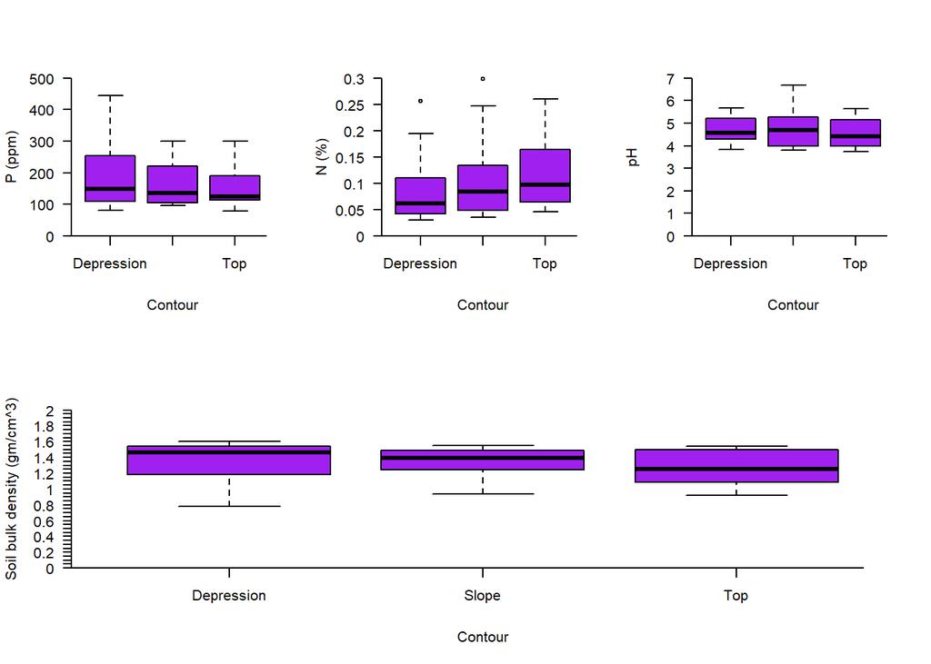

```r
nf<-layout(matrix(c(1:3,4,4,4), byrow=TRUE, ncol=3)) #use a matrix to specify layout


#boxplot of P by Contour:
boxplot(P~Contour, data=Soils, col="purple", frame=F, ylim=c(0,500), axes=F, ylab="P (ppm)", xlab="Contour")
axis(1, labels=levels(Soils$Contour), at=1:3, pos=0)
axis(2, labels=seq(0,500,100), at=seq(0,500,100), las=2)
segments(0,0,3.5,0)

#boxplot of N by Contour:
boxplot(N~Contour, data=Soils, col="purple", frame=F, ylim=c(0,0.3), axes=F,ylab="N (%)", xlab="Contour")
axis(1, labels=levels(Soils$Contour), at=1:3, pos=0)
axis(2, labels=seq(0,0.3,0.05), at=seq(0,0.3,0.05),las=2)
segments(0,0,3.5,0)

#boxplot of pH by Contour:
boxplot(pH~Contour, data=Soils, col="purple", frame=F, ylim=c(0,7), axes=F, ylab="pH", xlab="Contour")
axis(1, labels=levels(Soils$Contour), at=1:3, pos=0)
axis(2, labels=seq(0,7,1), at=seq(0,7,1), las=2)
segments(0,0,3.5,0)

#boxplot of Soil density by Contour:
boxplot(Dens~Contour, data=Soils, col="purple", frame=F, ylim=c(0,2), axes=F, ylab="Soil bulk density (gm/cm^3)", xlab="Contour")
axis(1, labels=levels(Soils$Contour), at=1:3, pos=0)
axis(2, labels=seq(0,2,0.05), at=seq(0,2,0.05), las=2)
segments(0,0,3.5,0)
```

### Add a), b), c) labels to multi-panel plots

Use mtext to label multi-panel plots

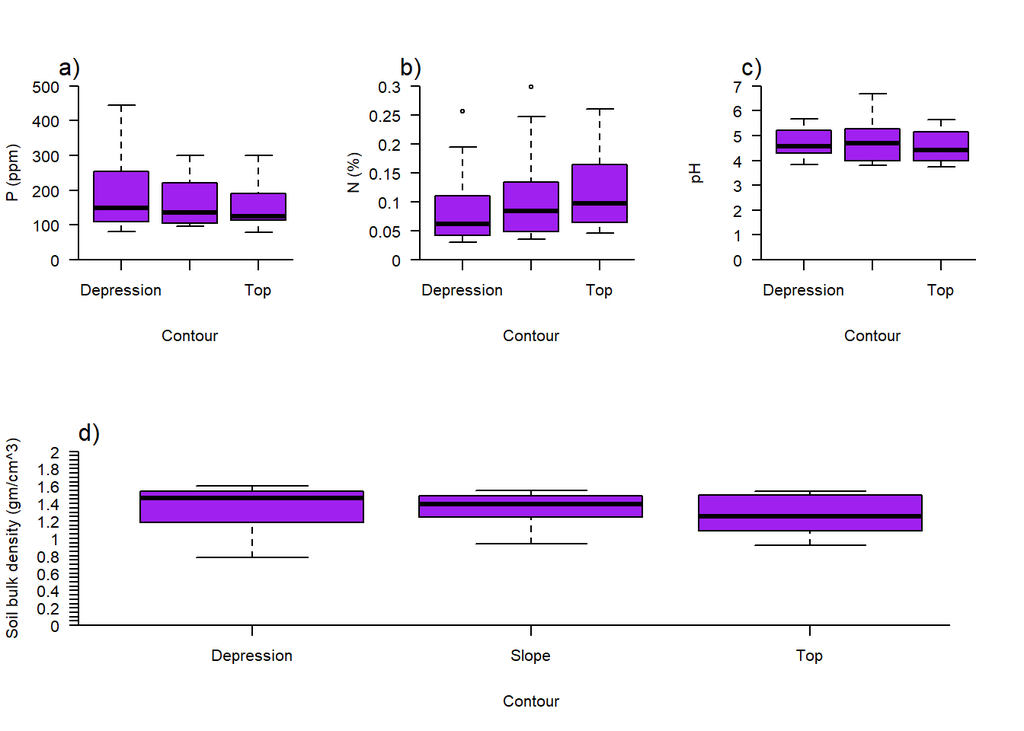

```r
nf<-layout(matrix(c(1:3,4,4,4), byrow=TRUE, ncol=3)) #use a matrix to specify layout

#boxplot of P by Contour:
boxplot(P~Contour, data=Soils, col="purple", frame=F, ylim=c(0,500), axes=F, ylab="P (ppm)", xlab="Contour")
axis(1, labels=levels(Soils$Contour), at=1:3, pos=0)
axis(2, labels=seq(0,500,100), at=seq(0,500,100), las=2)
segments(0,0,3.5,0)
mtext("a)", side=3, adj=-0.1, line=0)

#boxplot of N by Contour:
boxplot(N~Contour, data=Soils, col="purple", frame=F, ylim=c(0,0.3), axes=F,ylab="N (%)", xlab="Contour")
axis(1, labels=levels(Soils$Contour), at=1:3, pos=0)
axis(2, labels=seq(0,0.3,0.05), at=seq(0,0.3,0.05),las=2)
segments(0,0,3.5,0)
mtext("b)", side=3, adj=-0.1, line=0)

#boxplot of pH by Contour:
boxplot(pH~Contour, data=Soils, col="purple", frame=F, ylim=c(0,7), axes=F, ylab="pH", xlab="Contour")
axis(1, labels=levels(Soils$Contour), at=1:3, pos=0)
axis(2, labels=seq(0,7,1), at=seq(0,7,1), las=2)
segments(0,0,3.5,0)
mtext("c)", side=3, adj=-0.1, line=0)

#boxplot of Soil density by Contour:
boxplot(Dens~Contour, data=Soils, col="purple", frame=F, ylim=c(0,2), axes=F, ylab="Soil bulk density (gm/cm^3)", xlab="Contour")
axis(1, labels=levels(Soils$Contour), at=1:3, pos=0)
axis(2, labels=seq(0,2,0.05), at=seq(0,2,0.05), las=2)
segments(0,0,3.5,0)
mtext("d)", side=3, adj=0, line=0)
```

## Change margins of a plot

Use par(mar=c(#,#,#,#)) to change the inner margins and par(oma=c(#,#,#,#)) to change outer margins. First number is bottom, second is left, third is top, fourth is right.

Use par(mar=c(), oma=c()) to change both together.

```r
#Take a look at the matrix:
matrix(c(1:3,4,4,4), byrow=TRUE, ncol=3) #use ncol to specify number of columns. I have three 4's because of the fourth plot will occupy the space of three plots (ie the three above it)
```

```
##      [,1] [,2] [,3]
## [1,]    1    2    3
## [2,]    4    4    4
```

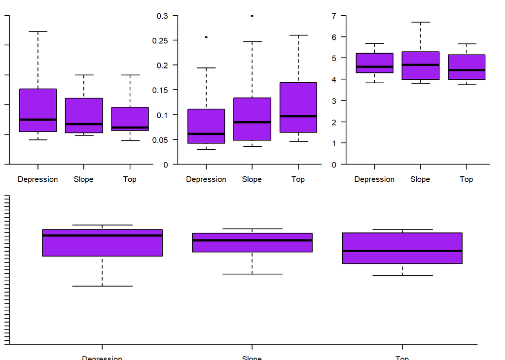

```r
nf<-layout(matrix(c(1:3,4,4,4), byrow=TRUE, ncol=3)) #use a matrix to specify layout

par(mar=c(1,1,1,1)) #change the margins

#boxplot of P by Contour:
boxplot(P~Contour, data=Soils, col="purple", frame=F, ylim=c(0,500), axes=F, ylab="P (ppm)", xlab="Contour")
axis(1, labels=levels(Soils$Contour), at=1:3, pos=0)
axis(2, labels=seq(0,500,100), at=seq(0,500,100), las=2)
segments(0,0,3.5,0)

#boxplot of N by Contour:
boxplot(N~Contour, data=Soils, col="purple", frame=F, ylim=c(0,0.3), axes=F,ylab="N (%)", xlab="Contour")
axis(1, labels=levels(Soils$Contour), at=1:3, pos=0)
axis(2, labels=seq(0,0.3,0.05), at=seq(0,0.3,0.05),las=2)
segments(0,0,3.5,0)

#boxplot of pH by Contour:
boxplot(pH~Contour, data=Soils, col="purple", frame=F, ylim=c(0,7), axes=F, ylab="pH", xlab="Contour")
axis(1, labels=levels(Soils$Contour), at=1:3, pos=0)
axis(2, labels=seq(0,7,1), at=seq(0,7,1), las=2)
segments(0,0,3.5,0)

#boxplot of Soil density by Contour:
boxplot(Dens~Contour, data=Soils, col="purple", frame=F, ylim=c(0,2), axes=F, ylab="Soil bulk density (gm/cm^3)", xlab="Contour")
axis(1, labels=levels(Soils$Contour), at=1:3, pos=0)
axis(2, labels=seq(0,2,0.05), at=seq(0,2,0.05), las=2)
segments(0,0,3.5,0)
```

The inner marings are smaller so the plots are closer together, but all the labels are cut off. Trying making the marings bigger, especially those with labels.

```r
#Take a look at the matrix:
matrix(c(1:3,4,4,4), byrow=TRUE, ncol=3) #use ncol to specify number of columns. I have three 4's because of the fourth plot will occupy the space of three plots (ie the three above it)
```

```
##      [,1] [,2] [,3]
## [1,]    1    2    3
## [2,]    4    4    4
```

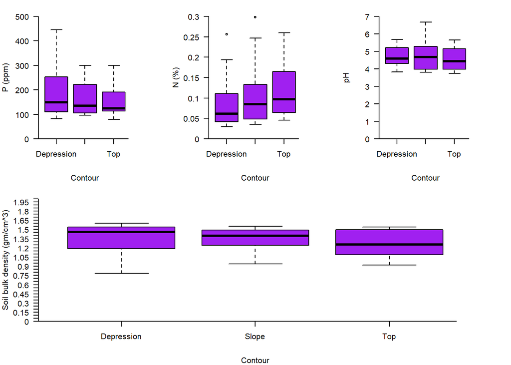

```r
nf<-layout(matrix(c(1:3,4,4,4), byrow=TRUE, ncol=3)) #use a matrix to specify layout

par(mar=c(4,4,1.2,4)) #change the margins

#boxplot of P by Contour:
boxplot(P~Contour, data=Soils, col="purple", frame=F, ylim=c(0,500), axes=F, ylab="P (ppm)", xlab="Contour")
axis(1, labels=levels(Soils$Contour), at=1:3, pos=0)
axis(2, labels=seq(0,500,100), at=seq(0,500,100), las=2)
segments(0,0,3.5,0)

#boxplot of N by Contour:
boxplot(N~Contour, data=Soils, col="purple", frame=F, ylim=c(0,0.3), axes=F,ylab="N (%)", xlab="Contour")
axis(1, labels=levels(Soils$Contour), at=1:3, pos=0)
axis(2, labels=seq(0,0.3,0.05), at=seq(0,0.3,0.05),las=2)
segments(0,0,3.5,0)

#boxplot of pH by Contour:
boxplot(pH~Contour, data=Soils, col="purple", frame=F, ylim=c(0,7), axes=F, ylab="pH", xlab="Contour")
axis(1, labels=levels(Soils$Contour), at=1:3, pos=0)
axis(2, labels=seq(0,7,1), at=seq(0,7,1), las=2)
segments(0,0,3.5,0)

#boxplot of Soil density by Contour:
boxplot(Dens~Contour, data=Soils, col="purple", frame=F, ylim=c(0,2), axes=F, ylab="Soil bulk density (gm/cm^3)", xlab="Contour")
axis(1, labels=levels(Soils$Contour), at=1:3, pos=0)
axis(2, labels=seq(0,2,0.05), at=seq(0,2,0.05), las=2)
segments(0,0,3.5,0)
```

# Basic statistical models and tests

Linear regression, ANOVAs, and t-tests are all linear models and can be done with the function lm (ie linear model). However, ANOVAs and t-tests also have their own functions.

Generalized linear models are extensions of the linear model for non-normal distributions.

Linear or generalized mixed models incorporate random effects. Generalized additive models and polynomial regression account for non-linearity in the response.

Non-linear models incorporate non-linearity in the parameters.

## T-tests

### One sample-test

```r
#This is a subset of data of stable isotopes for nitrogen taken from 10 sixgill shark embryo livers and the liver of their mother. Are these 10 values significantly different from the mother's value?

pup_liver_isotopes<-c(12.78,12.52,12.69,12.43,12.23,12.33, 12.29,12.21,12.40,12.55) # c() is concatenate - brings together values into a single vector.
mom_liver_value<-13.05

t.test(pup_liver_isotopes, mu=mom_liver_value, alternative = "two.sided") #two-tailed one sample t-test where null hypothesis value (mu) is the mom's nitrogen isotope value. Can change to "one.sided" for one-tailed hypothesis testing.
```

```
##
##  One Sample t-test
##
## data:  pup_liver_isotopes
## t = -10.027, df = 9, p-value = 3.498e-06
## alternative hypothesis: true mean is not equal to 13.05
## 95 percent confidence interval:
##  12.30606 12.57994
## sample estimates:
## mean of x
##    12.443
```

```r
#Test assumptions:
#Normality:
shapiro.test(pup_liver_isotopes) # p-value > 0.05 so data are normally distributed
```

```
##
##  Shapiro-Wilk normality test
##
## data:  pup_liver_isotopes
## W = 0.94613, p-value = 0.623
```

### Paired t-test

```r
#What about comparing nitrogen isotope values between liver and muscle, a sample of each taken from each embryo?

pup_liver_isotopes<-c(12.78,12.52,12.69,12.43,12.23,12.33, 12.29,12.21,12.40,12.55) # same as above

pup_muscle_isotopes<-c(14.43,15.72,15.77,15.39,15.42,16.85,15.56,15.93,15.58,15.09) # order is the same in each vector (ie it goes pup 1, then pup 2, etc. for both liver and muscle)

t.test(pup_liver_isotopes, pup_muscle_isotopes, paired=TRUE) #each vector must be numeric with the order of samples the same in each
```

```
##
##  Paired t-test
##
## data:  pup_liver_isotopes and pup_muscle_isotopes
## t = -13.445, df = 9, p-value = 2.907e-07
## alternative hypothesis: true difference in means is not equal to 0
## 95 percent confidence interval:
##  -3.657796 -2.604204
## sample estimates:
## mean of the differences
##                  -3.131
```

```r
#Test assumptions:
#Normality of differences:
pup_differences<-(pup_liver_isotopes-pup_muscle_isotopes) #set up a numeric vector with the differences
shapiro.test(pup_differences) # p-value > 0.05 so the differences are normally distributed
```

```
##
##  Shapiro-Wilk normality test
##
## data:  pup_differences
## W = 0.91767, p-value = 0.3379
```

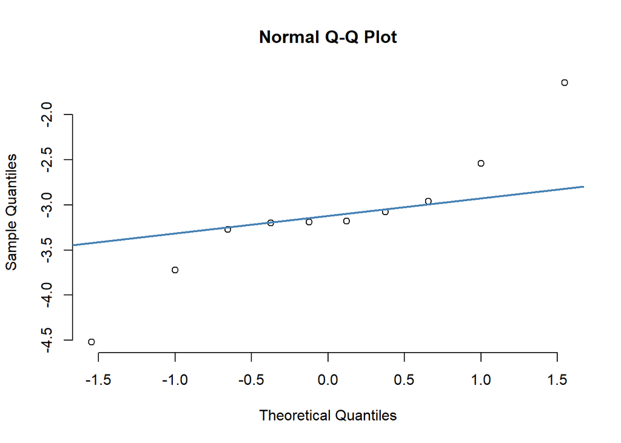

```r
#QQ plot on the differences
qqnorm(pup_differences, pch = 1, frame = FALSE)
qqline(pup_differences, col = "steelblue", lwd = 2)
```

### Two-sample t-test

```r
#Two marine protected areas in South Africa, one designed for fish with lots of kelp and reef habitat, another designed for whales in a big, sandy bay. From videos taken at multiple random sites in each, a community of marine fish, crustacean, and cephalopod species was recorded. The Shannon diversity was calculated at each site (see Community ecology section). Do the two marine protected areas differ on average in their Shannon diversity?

#Here are two ways to have your data stored in R:
#You can have them each as vectors:
WhaleSanctuary=c(1.8816523, 1.8389828, 1.3239195, 0.6931472,  0.6615632,1.2299186, 1.9963156, 1.0045784, 0.3767702,2.0468186)

KelpMPA=c(1.3835889, 1.7118451, 1.0567522, 0.9973048, 1.9783942, 1.1156818, 1.3214234, 1.9923252, 1.2984907, 1.3025272)

#You can also store them together in a data frame (see Data frame section):
MPA_Data<-data.frame(MPA=c(rep("WhaleSanctuary", length(WhaleSanctuary)), rep("KelpMPA", length(KelpMPA))), ShannonDiversity=c(WhaleSanctuary, KelpMPA))

#With group1, group2 as seperate vectors:
t.test(WhaleSanctuary, KelpMPA, var.equal = TRUE)
```

```
##
##  Two Sample t-test
##
## data:  WhaleSanctuary and KelpMPA
## t = -0.4908, df = 18, p-value = 0.6295
## alternative hypothesis: true difference in means is not equal to 0
## 95 percent confidence interval:
##  -0.5833327  0.3623993
## sample estimates:
## mean of x mean of y
##  1.305367  1.415833
```

```r
#or with y~x and x is categorical with only two groups (binary):
t.test(ShannonDiversity~MPA, data= MPA_Data, var.equal=TRUE)# as a data frame
```

```
##
##  Two Sample t-test
##
## data:  ShannonDiversity by MPA
## t = 0.4908, df = 18, p-value = 0.6295
## alternative hypothesis: true difference in means is not equal to 0
## 95 percent confidence interval:
##  -0.3623993  0.5833327
## sample estimates:
##        mean in group KelpMPA mean in group WhaleSanctuary
##                     1.415833                     1.305367
```

```r
# ~ symbol means "as a funciton of" - used to code many statistical tests in R

#Output shows mean Shannon diversity of KelpMPA is greater but NOT significantly based on alpha=0.05.

#Test assumptions:
#Normality of each broup:
shapiro.test(WhaleSanctuary)
```

```
##
##  Shapiro-Wilk normality test
##
## data:  WhaleSanctuary
## W = 0.91132, p-value = 0.2902
```

```r
shapiro.test(KelpMPA)
```

```
##
##  Shapiro-Wilk normality test
##
## data:  KelpMPA
## W = 0.87925, p-value = 0.1279
```

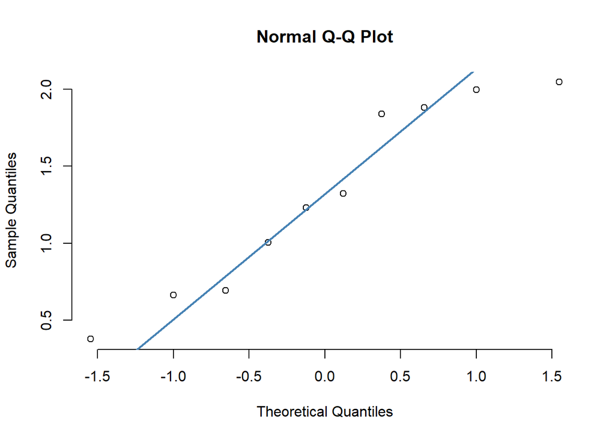

```r
#p-value > 0.05 in both so they are normally distributed

#QQ plot for checking normality (example is just for Whale Sanctuary)
qqnorm(WhaleSanctuary, pch = 1, frame = FALSE)
qqline(WhaleSanctuary, col = "steelblue", lwd = 2)
```

```r
#Equal variances
#With group1, group2 as separate objects:
var.test(WhaleSanctuary, KelpMPA) #performs F-test
```

```
##
##  F test to compare two variances
##
## data:  WhaleSanctuary and KelpMPA
## F = 2.9062, num df = 9, denom df = 9, p-value = 0.1278
## alternative hypothesis: true ratio of variances is not equal to 1
## 95 percent confidence interval:
##   0.7218591 11.7003468
## sample estimates:
## ratio of variances
##           2.906201
```

```r
#or with y~x and x is categorical with only two groups (binary):
var.test(ShannonDiversity~MPA, data=MPA_Data)
```

```
##
##  F test to compare two variances
##
## data:  ShannonDiversity by MPA
## F = 0.34409, num df = 9, denom df = 9, p-value = 0.1278
## alternative hypothesis: true ratio of variances is not equal to 1
## 95 percent confidence interval:
##  0.08546755 1.38531184
## sample estimates:
## ratio of variances
##          0.3440919
```

```r
bartlett.test(ShannonDiversity~MPA, data=MPA_Data) #Perform Bartlett's test
```

```
##
##  Bartlett test of homogeneity of variances
##
## data:  ShannonDiversity by MPA
## Bartlett's K-squared = 2.3191, df = 1, p-value = 0.1278
```

```r
library(car) #for Levene's test - remember to run install.packages("car") once to install the package or this line of code will not work!
leveneTest(ShannonDiversity~MPA, data=MPA_Data) #Levene's test
```

```
## Levene's Test for Homogeneity of Variance (center = median)
##       Df F value  Pr(>F)
## group  1  4.1301 0.05715 .
##       18
## ---
## Signif. codes:  0 '***' 0.001 '**' 0.01 '*' 0.05 '.' 0.1 ' ' 1
```

```r
#If assumption of equality of variance is NOT meet, perform Welch's two-sample t-test by changing to var.equal=FALSE
t.test(ShannonDiversity~MPA, data= MPA_Data, var.equal=FALSE)
```

```
##
##  Welch Two Sample t-test
##
## data:  ShannonDiversity by MPA
## t = 0.4908, df = 14.538, p-value = 0.6309
## alternative hypothesis: true difference in means is not equal to 0
## 95 percent confidence interval:
##  -0.3706017  0.5915351
## sample estimates:
##        mean in group KelpMPA mean in group WhaleSanctuary
##                     1.415833                     1.305367
```

### Non-parametric versions of the t-test

NOTE: Check out Generalized Linear Models (GLMs) below that do not assume normality but are still parametric - especially if you have count, proportion, or presence/absence or yes/no data. These are preferable to non-parametric tests.

```r
# Mann-Whitney U Test/Wilcoxon rank sum test for two-sample t-test
#With y~x and x is binary (categorical with two groups) as the argument:
wilcox.test(ShannonDiversity~MPA, data=MPA_Data) #see two-sample t-test section for the data
```

```
##
##  Wilcoxon rank sum exact test
##
## data:  ShannonDiversity by MPA
## W = 54, p-value = 0.7959
## alternative hypothesis: true location shift is not equal to 0
```

```r
#or with group1, group2 as seperate vectors as arguments:
wilcox.test(KelpMPA, WhaleSanctuary)
```

```
##
##  Wilcoxon rank sum exact test
##
## data:  KelpMPA and WhaleSanctuary
## W = 54, p-value = 0.7959
## alternative hypothesis: true location shift is not equal to 0
```

```r
# Wilcoxon signed rank test for paired samples:
wilcox.test(pup_liver_isotopes, pup_muscle_isotopes,paired=TRUE) #see paired sample t-test section for the data. The order in each vector is the same (ie first element of each refers to values from shark 1, second element in each is shark 2, etc.)
```

```
##
##  Wilcoxon signed rank exact test
##
## data:  pup_liver_isotopes and pup_muscle_isotopes
## V = 0, p-value = 0.001953
## alternative hypothesis: true location shift is not equal to 0
```

## ANOVA

```r
#Read in data on soils
library(carData) #remember to install.packages(carData) before first use
data("Soils") #some packages have data sets saved in them. The data() function retrieves them - in this case loading a data frame called Soils
head(Soils)
```

```
##   Group Contour Depth Gp Block   pH     N Dens   P    Ca   Mg    K   Na Conduc
## 1     1     Top  0-10 T0     1 5.40 0.188 0.92 215 16.35 7.65 0.72 1.14   1.09
## 2     1     Top  0-10 T0     2 5.65 0.165 1.04 208 12.25 5.15 0.71 0.94   1.35
## 3     1     Top  0-10 T0     3 5.14 0.260 0.95 300 13.02 5.68 0.68 0.60   1.41
## 4     1     Top  0-10 T0     4 5.14 0.169 1.10 248 11.92 7.88 1.09 1.01   1.64
## 5     2     Top 10-30 T1     1 5.14 0.164 1.12 174 14.17 8.12 0.70 2.17   1.85
## 6     2     Top 10-30 T1     2 5.10 0.094 1.22 129  8.55 6.92 0.81 2.67   3.18
```

```r
#Focusing on pH - measurements at different contours of topography and soil depths at four different areas (blocks). Does pH depend on depth or contour, when controlling for the area of sampling?

#Run an ANOVA, saving the output to an object I made up called a.out
#works as y ~ x1 + x2 or y ~ x1*x2 for interations
#Remember ~ means "is a function of"
a.out<-aov(pH~Contour*Depth+Block, data=Soils) # the * specifies an interaction between Depth and Contour as well as the main effects of Contour and Depth on their own.
#could also write as: aov(pH~Contour+Depth+Block+Contour:Depth, data=Soils). The : symbol is for specifying interactions on their own, without the main effects.
#Both A:B and A*B would work for interaction
#Three-way interation would be A:B:C or A*B*C

summary(a.out) #get the ANOVA table with p-values
```

```
##               Df Sum Sq Mean Sq F value   Pr(>F)
## Contour        2  0.261   0.130   1.013   0.3743
## Depth          3 14.959   4.986  38.742 6.41e-11 ***
## Block          3  1.232   0.411   3.192   0.0362 *
## Contour:Depth  6  0.516   0.086   0.668   0.6759
## Residuals     33  4.247   0.129
## ---
## Signif. codes:  0 '***' 0.001 '**' 0.01 '*' 0.05 '.' 0.1 ' ' 1
```

```r
#If you want the coefficients table (ie ANOVA expressed as a linear model)
a.model.out<-lm(pH~Contour*Depth+Block, data=Soils)
summary(a.model.out) # gives you the effect sizes, the differences between each group and the strength of the interaction (how much the effect changes due to each level of the interaction)
```

```
##
## Call:
## lm(formula = pH ~ Contour * Depth + Block, data = Soils)
##
## Residuals:
##      Min       1Q   Median       3Q      Max
## -0.62396 -0.16813  0.02688  0.13063  1.15354
##
## Coefficients:
##                         Estimate Std. Error t value Pr(>|t|)
## (Intercept)               5.1573     0.2006  25.716  < 2e-16 ***
## ContourSlope              0.1550     0.2537   0.611 0.545380
## ContourTop               -0.0200     0.2537  -0.079 0.937636
## Depth10-30               -0.4725     0.2537  -1.863 0.071443 .
## Depth30-60               -0.9900     0.2537  -3.903 0.000443 ***
## Depth60-90               -1.1800     0.2537  -4.652 5.13e-05 ***
## Block2                    0.2433     0.1465   1.661 0.106103
## Block3                    0.1083     0.1465   0.740 0.464730
## Block4                    0.4292     0.1465   2.930 0.006105 **
## ContourSlope:Depth10-30   0.2475     0.3588   0.690 0.495091
## ContourTop:Depth10-30    -0.0100     0.3588  -0.028 0.977930
## ContourSlope:Depth30-60  -0.2500     0.3588  -0.697 0.490776
## ContourTop:Depth30-60    -0.1375     0.3588  -0.383 0.703979
## ContourSlope:Depth60-90  -0.4000     0.3588  -1.115 0.272921
## ContourTop:Depth60-90    -0.2600     0.3588  -0.725 0.473728
## ---
## Signif. codes:  0 '***' 0.001 '**' 0.01 '*' 0.05 '.' 0.1 ' ' 1
##
## Residual standard error: 0.3588 on 33 degrees of freedom
## Multiple R-squared:  0.7998, Adjusted R-squared:  0.7149
## F-statistic: 9.417 on 14 and 33 DF,  p-value: 7.405e-08
```

```r
#The interaction was not significant, so what if I want to run without it?
a.out2<-update(a.out, ~.-Contour:Depth) # the period (.) means everything. This says update a.out, but with the response (pH) as a function of (~) everything (.) minus the interaction.
summary(a.out2)
```

```
##             Df Sum Sq Mean Sq F value   Pr(>F)
## Contour      2  0.261   0.130   1.067   0.3538
## Depth        3 14.959   4.986  40.827 4.13e-12 ***
## Block        3  1.232   0.411   3.364   0.0282 *
## Residuals   39  4.763   0.122
## ---
## Signif. codes:  0 '***' 0.001 '**' 0.01 '*' 0.05 '.' 0.1 ' ' 1
```

### Tukey post-hoc test

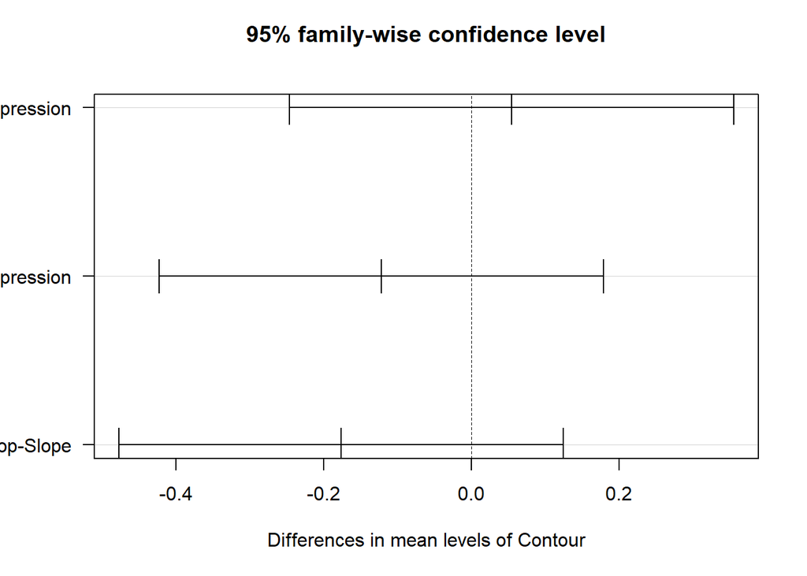

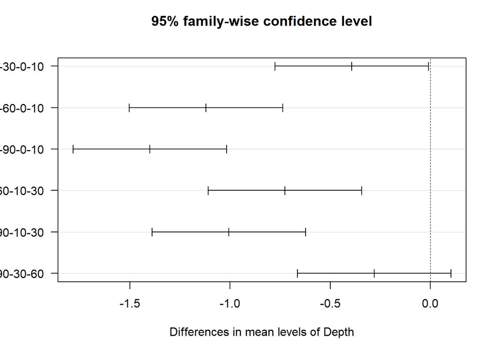

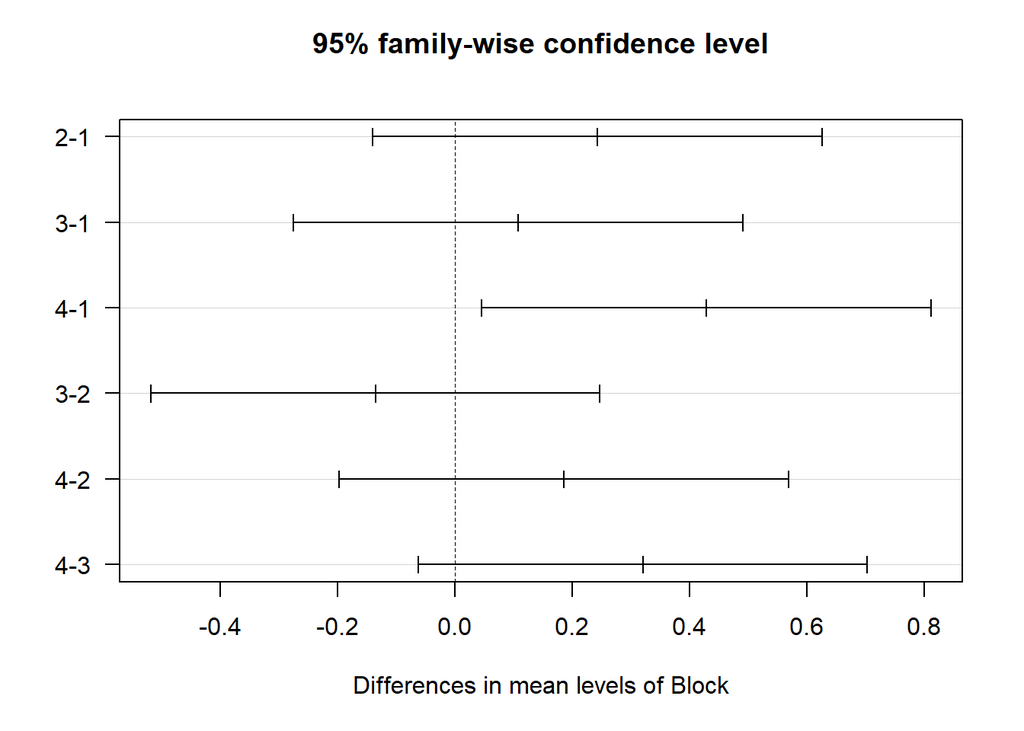

```r
tukey.plot.test<-TukeyHSD(a.out2) #run a Tukey post-hoc test for the above ANOVA
plot(tukey.plot.test, las = 1) # the significant comparisons have error bars NOT overlapping with zero.
```

### Interaction plots

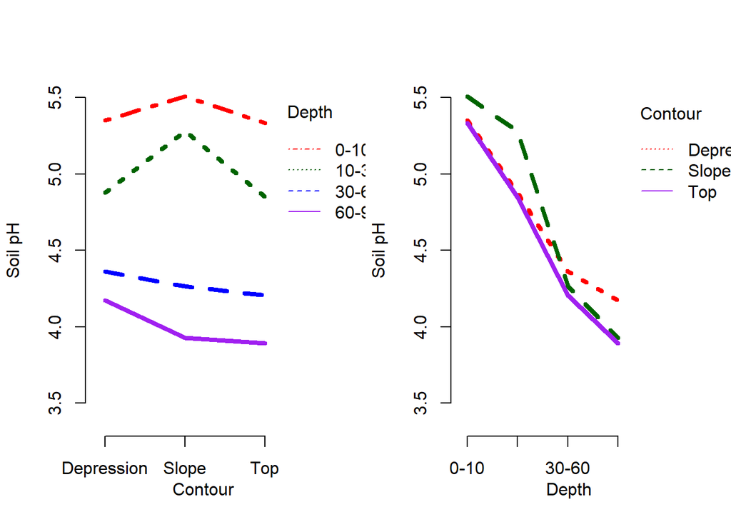

```r
par(mfrow=c(1,2)) #set plotting window to be 1 row and 2 columns
#Show how the effect of contour on soil pH changes at different depths
interaction.plot(x.factor=Soils$Contour,
                 trace.factor=Soils$Depth,
                 response=Soils$pH,
                 trace.label="Depth", xlab="Contour",
                 ylab="Soil pH",
                 col=c("red", "darkgreen", "blue", "purple"),
                 lwd=4, bty="n", ylim=c(3.5,5.5), xtick=TRUE)

#Show how the effect of depth on soil pH changes at different contours
interaction.plot(x.factor=Soils$Depth,
                 trace.factor=Soils$Contour,
                 response=Soils$pH,
                 trace.label="Contour", xlab="Depth",
                 ylab="Soil pH",
                 col=c("red", "darkgreen", "purple"),
                 lwd=4, bty="n", ylim=c(3.5,5.5), xtick=TRUE)
```

### Model diagnostics (are assumptions met?)

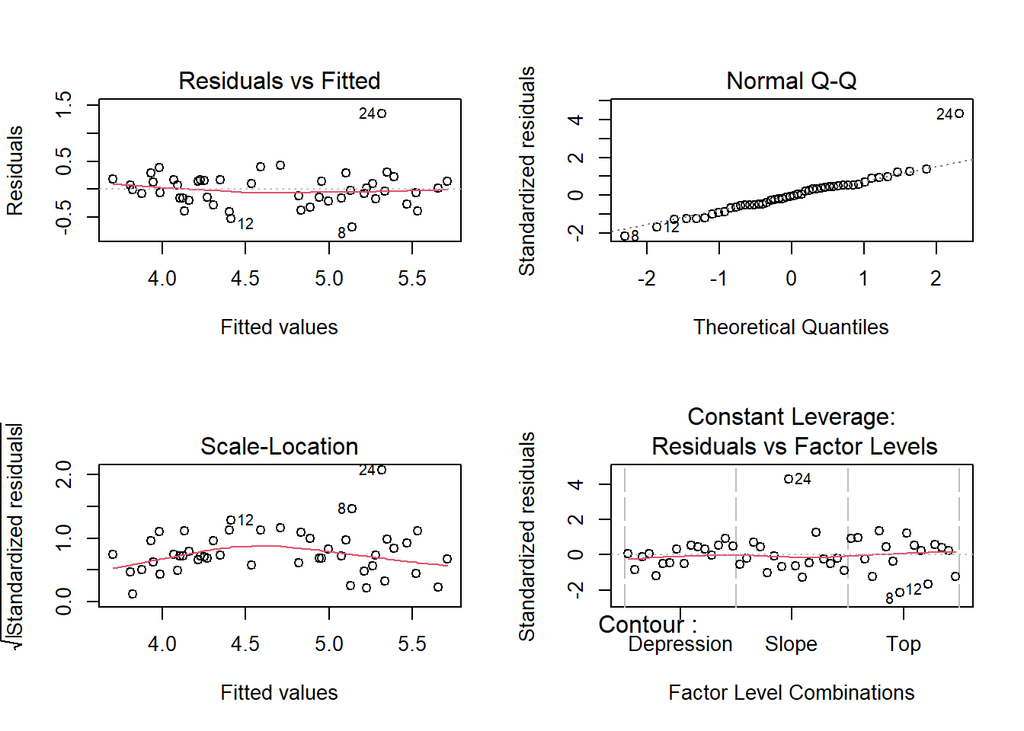

```r
#Examine diagnostic plots (ie Q-Q plot and residual vs fitted) for the ANOVA:
par(mfrow=c(2,2))
plot(a.out2) # Examine residual vs fitted for issues with equal variance
```

```r
#Testing normality of residuals (although can use Q-Q plot above)
shapiro.test(a.out2$residuals)
```

```
##
##  Shapiro-Wilk normality test
##
## data:  a.out2$residuals
## W = 0.90079, p-value = 0.0006667
```

### Non-parametric Kruskal-Wallis Test when normality not met

NOTE: Check out Generalized Linear Models (GLMs) below that do not assume normality but are still parametric - especially if you have count, proportion, or presence/absence or yes/no data. These are preferable to non-parametric tests.

```r
kruskal.test(pH~Depth, data = Soils) #Remember: assumption of equality of variance still required
```

```
##
##  Kruskal-Wallis rank sum test
##
## data:  pH by Depth
## Kruskal-Wallis chi-squared = 36.976, df = 3, p-value = 4.656e-08
```

```r
#pairwise test with Bonferroni correction for multiple testing:
#the function requires the list of y values to be seperated from the categories of the factor (Contour) by a comma:
pairwise.wilcox.test(Soils$pH, Soils$Depth,
                 p.adjust.method = "bonferroni") # get p-values of each comparison
```

```
##
##  Pairwise comparisons using Wilcoxon rank sum test with continuity correction
##
## data:  Soils$pH and Soils$Depth
##
##       0-10    10-30   30-60
## 10-30 0.01917 -       -
## 30-60 0.00022 0.00354 -
## 60-90 0.00022 0.00022 0.14569
##
## P value adjustment method: bonferroni
```

## Simple linear regression

Linear regression builds on ANOVAs, letting explanatory variables be continuous numbers. In fact, an ANOVA is just a linear regression for categorical variables.

Linear regression estimates the linear relationship (ie intercept and slope) between a continuous response variable and an explanatory variable. The slope represents your effect size (strength of th relationship).

You can get significance of the relationship (ie p-values) two ways: 1. ANOVA using the anova() function. 2. One-sample t-test asking if the slope is significantly different from zero using the summary() function.

For linear regression, these two methods are mathematically the same.

Linear regression assumptions: 1. Independence of observations 2. Variance in the response is the same for all values of the explanatory variable (homoscedasticity/equality of variance). 3. Residuals are normally distributed.

The basic function in R for linear regression is lm() - linear model. Use: lm(response~explanatory, data=name of data frame)

Example: can you predict brain size from body size in mammals?

```r
#install.packages("MASS")
library(MASS) #example mammal data is in this package
data(mammals) #load the data from the MASS package
head(mammals) #see first six rows
```

```
##                    body brain
## Arctic fox        3.385  44.5
## Owl monkey        0.480  15.5
## Mountain beaver   1.350   8.1
## Cow             465.000 423.0
## Grey wolf        36.330 119.5
## Goat             27.660 115.0
```

```r
#Run the regression of brain size against body size:
lm.mammals<-lm(brain~body, data=mammals)

#p-value by anova:
anova(lm.mammals)
```

```
## Analysis of Variance Table
##
## Response: brain
##           Df   Sum Sq  Mean Sq F value    Pr(>F)
## body       1 46068314 46068314  411.19 < 2.2e-16 ***
## Residuals 60  6722239   112037
## ---
## Signif. codes:  0 '***' 0.001 '**' 0.01 '*' 0.05 '.' 0.1 ' ' 1
```

```r
#slope (effect size), intercept, and p-value by summary:
summary(lm.mammals)
```

```
##
## Call:
## lm(formula = brain ~ body, data = mammals)
##
## Residuals:
##     Min      1Q  Median      3Q     Max
## -810.07  -88.52  -79.64  -13.02 2050.33
##
## Coefficients:
##             Estimate Std. Error t value Pr(>|t|)
## (Intercept) 91.00440   43.55258    2.09   0.0409 *
## body         0.96650    0.04766   20.28   <2e-16 ***
## ---
## Signif. codes:  0 '***' 0.001 '**' 0.01 '*' 0.05 '.' 0.1 ' ' 1
##
## Residual standard error: 334.7 on 60 degrees of freedom
## Multiple R-squared:  0.8727, Adjusted R-squared:  0.8705
## F-statistic: 411.2 on 1 and 60 DF,  p-value: < 2.2e-16
```

### Model diagnostics

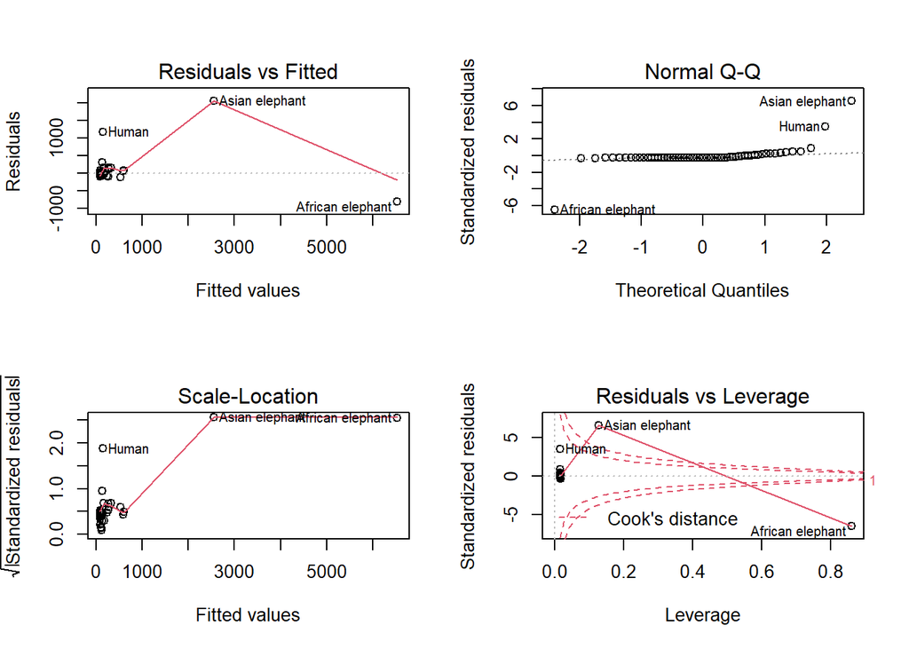

```r
par(mfrow=c(2,2)) # plotting window is a 2x2 grid for four plots
plot(lm.mammals) #the two elephants are obvious outliers
```

```r
shapiro.test(lm.mammals$residuals) #the residuals are not normally distributed
```

```
##
##  Shapiro-Wilk normality test
##
## data:  lm.mammals$residuals
## W = 0.41112, p-value = 2.316e-14
```

### Regression on transformed data

The two elephants had such large body sizes they became outliers. Perhaps the relationship is better expressed between log(body size) and log(brain size). Taking the log reduces the influence of large observations (making the data less skewed).

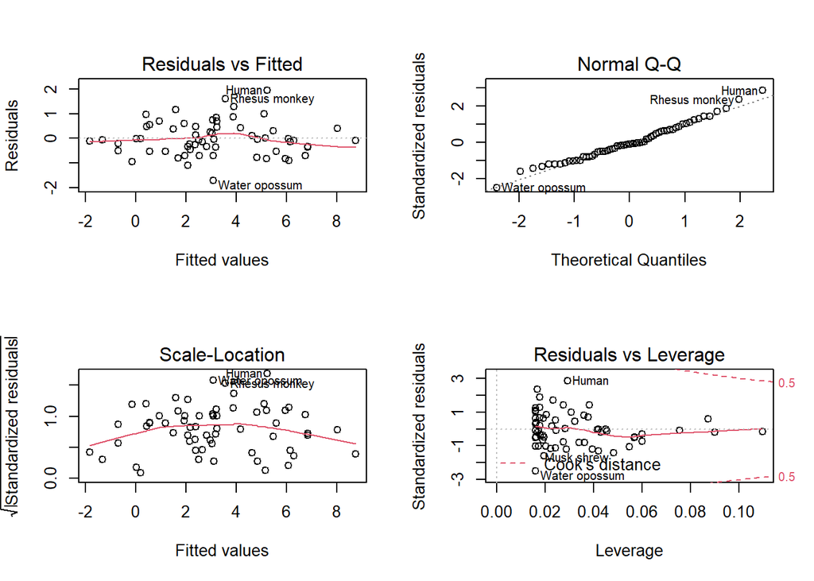

```r
#The linear regression with each variable log-transformed:
#in R, log means ln (ie base e).

lm.log_mammals<-lm(log(brain)~log(body), data=mammals)

par(mfrow=c(2,2))
plot(lm.log_mammals) # the skewness is reduced, the plots are easier to read
```

```r
shapiro.test(lm.log_mammals$residuals) #the residuals are now normally distributed
```

```
##
##  Shapiro-Wilk normality test
##
## data:  lm.log_mammals$residuals
## W = 0.98268, p-value = 0.5293
```

```r
#slope, intercept, and p-value:
summary(lm.log_mammals)
```

```
##
## Call:
## lm(formula = log(brain) ~ log(body), data = mammals)
##
## Residuals:
##      Min       1Q   Median       3Q      Max
## -1.71550 -0.49228 -0.06162  0.43597  1.94829
##
## Coefficients:
##             Estimate Std. Error t value Pr(>|t|)
## (Intercept)  2.13479    0.09604   22.23   <2e-16 ***
## log(body)    0.75169    0.02846   26.41   <2e-16 ***
## ---
## Signif. codes:  0 '***' 0.001 '**' 0.01 '*' 0.05 '.' 0.1 ' ' 1
##
## Residual standard error: 0.6943 on 60 degrees of freedom
## Multiple R-squared:  0.9208, Adjusted R-squared:  0.9195
## F-statistic: 697.4 on 1 and 60 DF,  p-value: < 2.2e-16
```

## Mutliple regression

Multiple regression is used to estimate the relationship between multiple explanatory variables and a continuous response variable.

The explanatory variables can be continuous or categorical. A mix of continuous and categorical explanatory variables is often called an ANCOVA.

Interactions among explanatory variables in how they affect the response can also be explored. Use: lm(response~X1+X2+X1*X2+…, data=name of data). Here X1, etc. refer to explanatory variables. The asterisk denotes an interaction.

Example: Predicting zooplankton biomass at Guadeloupe. A transect line was run across a reef at Guadeloupe and zooplanton biomass and environmental variables were measured.

Raw data available from http://www.esapubs.org/archive/ecol/E085/050/#suppl-1.htm#anchorFilelist

```r
zooplankton_data<-read.csv("c:/Users/gjosg/Dropbox/R_Handbook_2020_UVic/Data/guadeloupe.csv", header=TRUE)

head(zooplankton_data)
```

```
##      Site Transect_Dist Ln_zoo_biomass_small Ln_zoo_biomass_large Diss_Oxygen
## 1 Site_01          0.00              1.04416               0.0334        7.70
## 2 Site_02          0.24              1.98965               0.7159        7.06
## 3 Site_03          0.36              1.33184              -0.0356        7.91
## 4 Site_04          0.60              1.10327               0.3514        7.56
## 5 Site_05          0.60              0.41871              -0.3624        7.18
## 6 Site_06          0.69              1.35841               0.4725        6.89
##   Salinity Wind_speed Phytoplankton_biomass Turbidity Swell_height
## 1    36.40        3.0                0.3781       1.5          0.2
## 2    36.86        3.4                0.7576       1.6          0.2
## 3    37.02        5.5                0.5857       1.6          0.3
## 4    36.92        6.7                0.7035       1.2          0.4
## 5    36.65        7.0                0.7035       1.2          0.4
## 6    36.85        6.7                0.5857       1.2          0.4
```

```r
# Response variable: log-transformed zooplankton biomasses of two size classes
# Spatial variable: coordinate (km) of the sampling site along the transect.
# Environmental variables: dissolved oxygen (mg/L), salinity (psu), wind speed (m/s), phytoplankton biomass (log-transformed, original units: ?g/L), turbidity (NTU), swell height (m).

#First combine biomass of the two size classes into single biomass measurement:
zooplankton_data$Ln_zoo_biomass<-log(exp(zooplankton_data$Ln_zoo_biomass_small)+exp(zooplankton_data$Ln_zoo_biomass_large)) #because I received the data log-transformed, I use exp to put back into original units, sum the two classes together, then log-transform the data again.

#Model zooplankton biomass as a function of distance along transect, dissolved oxygen, salinity, wind speed, and phytoplankton biomass. I've decided to model an interaction between dissolved oxygen and salinity as an example. You can include all possible interactions if you want, and have enough data to do so.

#run the multiple regression model:
lm.multiple<-lm(Ln_zoo_biomass~Transect_Dist+Diss_Oxygen*Salinity+Wind_speed+Phytoplankton_biomass, data=zooplankton_data)

#get the slopes, intercept, and p-values:
summary(lm.multiple)
```

```
##
## Call:
## lm(formula = Ln_zoo_biomass ~ Transect_Dist + Diss_Oxygen * Salinity +
##     Wind_speed + Phytoplankton_biomass, data = zooplankton_data)
##
## Residuals:
##      Min       1Q   Median       3Q      Max
## -1.00373 -0.29471 -0.02697  0.32406  0.88978
##
## Coefficients:
##                        Estimate Std. Error t value Pr(>|t|)
## (Intercept)           302.57544  194.30749   1.557   0.1266
## Transect_Dist          -0.16595    0.08923  -1.860   0.0696 .
## Diss_Oxygen           -43.50459   27.32714  -1.592   0.1185
## Salinity               -8.05392    5.22850  -1.540   0.1306
## Wind_speed              0.02065    0.03494   0.591   0.5575
## Phytoplankton_biomass  -0.07659    0.45382  -0.169   0.8668
## Diss_Oxygen:Salinity    1.16578    0.73533   1.585   0.1200
## ---
## Signif. codes:  0 '***' 0.001 '**' 0.01 '*' 0.05 '.' 0.1 ' ' 1
##
## Residual standard error: 0.4764 on 44 degrees of freedom
## Multiple R-squared:  0.4753, Adjusted R-squared:  0.4038
## F-statistic: 6.643 on 6 and 44 DF,  p-value: 4.723e-05
```

```r
anova(lm.multiple)
```

```
## Analysis of Variance Table
##
## Response: Ln_zoo_biomass
##                       Df Sum Sq Mean Sq F value    Pr(>F)
## Transect_Dist          1 7.0437  7.0437 31.0348 1.436e-06 ***
## Diss_Oxygen            1 1.2451  1.2451  5.4858   0.02376 *
## Salinity               1 0.1115  0.1115  0.4912   0.48707
## Wind_speed             1 0.0704  0.0704  0.3103   0.58032
## Phytoplankton_biomass  1 0.0054  0.0054  0.0236   0.87867
## Diss_Oxygen:Salinity   1 0.5705  0.5705  2.5135   0.12004
## Residuals             44 9.9863  0.2270
## ---
## Signif. codes:  0 '***' 0.001 '**' 0.01 '*' 0.05 '.' 0.1 ' ' 1
```

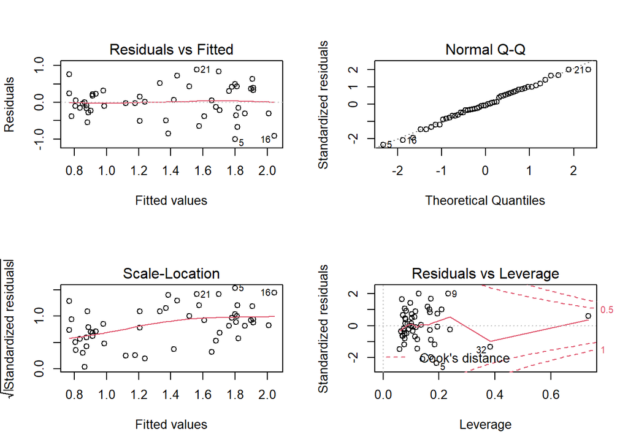

```r
#model diagnostic plots
par(mfrow=c(2,2))
plot(lm.multiple)
```

```r
#normality of the residuals:
shapiro.test(lm.multiple$residuals)
```

```
##
##  Shapiro-Wilk normality test
##
## data:  lm.multiple$residuals
## W = 0.9889, p-value = 0.9121
```

### ANCOVA

ANCOVA is a special kind of linear regression where a continuous covariate with the potential to confound an effect of interest is controlled for in the analysis. YOu can also control for interactions between categorical and continuous variables.

ANCOVA assumptions: 1. Independence of data 2. Linear relationship between response and the continuous covariate 3. Normality of residuals 4. Variance is equal across for all values of categorical and continuous variables

Additionally, if you do not include an interaction between categorical and continuous explanatory variables: 5. Slope is the same across all levels of categorical factor.

Use: lm(y~X1+X2, data=data); y=response, X1 is categorical factor, X2 is continuous variable With ineraction: lm(y~X1*X2, data=data)

Example: naked mole rats differ in activity levels (workers vs lazy caste members). You would expect differences in energy expenditure between these two castes. However, the two castes may differ in body size, which would also affect energy expenditure. If lazy rats are bigger, they will expend more energy independent of their activity level. The effect of body size needs to be controlled to see the effect of caste membership.

```r
MoleRats<-read.csv("c:/Users/gjosg/Dropbox/R_Handbook_2020_UVic/Data/MoleRats.csv", header=TRUE)
head(MoleRats)
```

```
##    caste   lnmass lnenergy
## 1 worker 3.850148 3.688879
## 2 worker 3.988984 3.688879
## 3 worker 4.110874 3.688879
## 4 worker 4.174387 3.663562
## 5 worker 4.248495 3.871201
## 6 worker 4.262680 3.850148
```

```r
ancova.out<-lm(lnenergy~lnmass+caste, data=MoleRats) #no interaction
ancova.int<-lm(lnenergy~lnmass*caste, data=MoleRats) #interaction allows for different slope for different groups

summary(ancova.int) #slopes, intercepts, p-values
```

```
##
## Call:
## lm(formula = lnenergy ~ lnmass * caste, data = MoleRats)
##
## Residuals:
##      Min       1Q   Median       3Q      Max
## -0.72004 -0.17990  0.05631  0.19551  0.43128
##
## Coefficients:
##                    Estimate Std. Error t value Pr(>|t|)
## (Intercept)          1.2939     1.6691   0.775   0.4441
## lnmass               0.6069     0.3428   1.771   0.0865 .
## casteworker         -1.5713     1.9518  -0.805   0.4269
## lnmass:casteworker   0.4186     0.4147   1.009   0.3206
## ---
## Signif. codes:  0 '***' 0.001 '**' 0.01 '*' 0.05 '.' 0.1 ' ' 1
##
## Residual standard error: 0.2965 on 31 degrees of freedom
## Multiple R-squared:  0.4278, Adjusted R-squared:  0.3725
## F-statistic: 7.727 on 3 and 31 DF,  p-value: 0.0005391
```

```r
summary(ancova.out) #slopes, intercepts, p-values
```

```
##
## Call:
## lm(formula = lnenergy ~ lnmass + caste, data = MoleRats)
##
## Residuals:
##      Min       1Q   Median       3Q      Max
## -0.73388 -0.19371  0.01317  0.17578  0.47673
##
## Coefficients:
##             Estimate Std. Error t value Pr(>|t|)
## (Intercept) -0.09687    0.94230  -0.103   0.9188
## lnmass       0.89282    0.19303   4.625 5.89e-05 ***
## casteworker  0.39334    0.14611   2.692   0.0112 *
## ---
## Signif. codes:  0 '***' 0.001 '**' 0.01 '*' 0.05 '.' 0.1 ' ' 1
##
## Residual standard error: 0.2966 on 32 degrees of freedom
## Multiple R-squared:  0.409,  Adjusted R-squared:  0.3721
## F-statistic: 11.07 on 2 and 32 DF,  p-value: 0.0002213
```

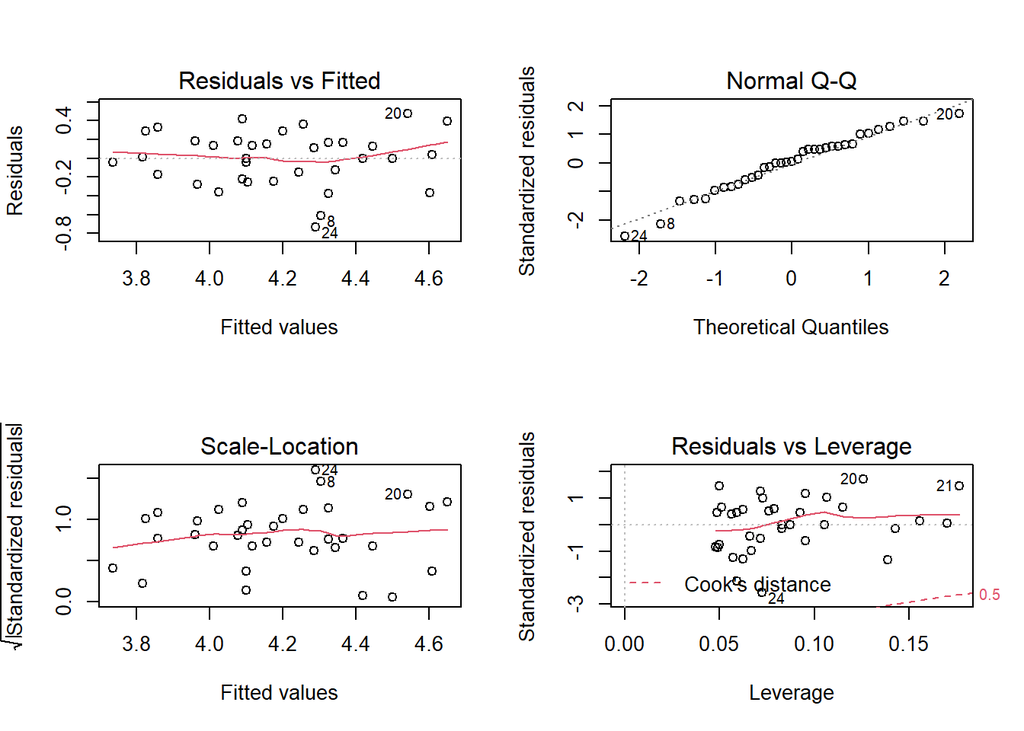

```r
#Diagnostic plots
par(mfrow=c(2,2))
plot(ancova.out)
```

### Plot of data for ANCOVA

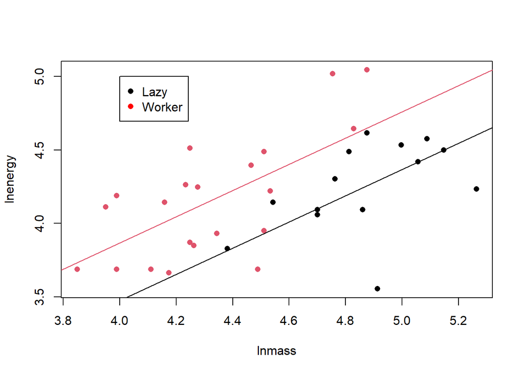

```r
plot(lnenergy~lnmass, col=as.factor(caste), data=MoleRats, pch=16) #I factor "caste", as that means it will be represented by a number in the plot function - and the col argument uses numbers to denote colours.
abline(ancova.out$coefficients[1], ancova.out$coefficients[2]) # line for lazy mole rats (which are the baseline)
abline(ancova.out$coefficients[1]+ancova.out$coefficients[3], ancova.out$coefficients[2], col=2) #adds difference to the intercept due to worker caste
legend(4,5,c("Lazy", "Worker"), col=c("black", "red"), pch=16) #adds a legend at x=4 y=5
```

## Generalized linear models

Generalized linear models (GLMs) model relationships in data that are not normal. For instance, count data inherently have a variance that increases with the mean. Modelling based on the Poisson or negative binomial distribution is more appropriate than the normal distribution.

### Poisson regression

The Poisson distribution is for count data where the variance equals the mean.

Use: glm(y~X1+X2+…, family = “poisson”, data = name of data) where y = response and X1, etc. = explanatory variables.

Example: Understand how counts of scallopped hammerhead sharks made at a seamount in the Pacific have changed through time and what relationship they have to sea surface temperature (SST) and a measure of the El Nino (ONI) while controlling for visibility.

```r
hammerhead_sharks<-read.csv("c:/Users/gjosg/Dropbox/R_Handbook_2020_UVic/Data/Hammerheads.csv", header=TRUE)
head(hammerhead_sharks)
```

```
##   Year SiteCode Visibility DiverCode Hammerheads   SST   ONI
## 1 2012      110         12         9           1 29.40 -0.38
## 2 2018      103         15         3          20 29.53 -0.41
## 3 2016      103         12         4          15 27.13 -0.74
## 4 2007      101         30         3          20 29.18  0.32
## 5 2019      112         24        43          40 27.77  0.13
## 6 2007      111          9         3          15 25.53 -1.60
```

```r
#Run the GLM:
glm.poisson<-glm(Hammerheads~Year+SST+ONI+Visibility, family = "poisson", data=hammerhead_sharks, na.action = "na.fail") #model the relationship between hammerhead counts and year, SST, ONI, and visibility assuming Poisson distribution. na.action="na.fail" means the model will not run if NAs exist in any of the explanatory variables - this is necessary for the dredge function below but can be deleted otherwise.

#Get the coefficients (intercept, slopes) and p-values from a Wald's Z-test:
summary(glm.poisson)
```

```
##
## Call:
## glm(formula = Hammerheads ~ Year + SST + ONI + Visibility, family = "poisson",
##     data = hammerhead_sharks, na.action = "na.fail")
##
## Deviance Residuals:
##      Min        1Q    Median        3Q       Max
## -14.7753   -5.9476   -3.4142    0.6047   27.3578
##
## Coefficients:
##               Estimate Std. Error z value Pr(>|z|)
## (Intercept) 77.9619713  4.2585183   18.31   <2e-16 ***
## Year        -0.0374011  0.0021315  -17.55   <2e-16 ***
## SST         -0.0007929  0.0113555   -0.07    0.944
## ONI         -0.4120340  0.0164040  -25.12   <2e-16 ***
## Visibility   0.0184108  0.0014657   12.56   <2e-16 ***
## ---
## Signif. codes:  0 '***' 0.001 '**' 0.01 '*' 0.05 '.' 0.1 ' ' 1
##
## (Dispersion parameter for poisson family taken to be 1)
##
##     Null deviance: 13827  on 269  degrees of freedom
## Residual deviance: 12164  on 265  degrees of freedom
## AIC: 13124
##
## Number of Fisher Scoring iterations: 6
```

```r
#Get the AIC:
AIC(glm.poisson)
```

```
## [1] 13123.66
```

```r
#Compare AIC among suite of candidate models:
#install.packages("MuMIn")
library(MuMIn) #dredge function is in MuMIn

glm.poisson.dredge<-dredge(glm.poisson) #list of all possible sub-models (each differing in one explanatory variable)
```

```
## Fixed term is "(Intercept)"
```

```r
glm.poisson.dredge
```

```
## Global model call: glm(formula = Hammerheads ~ Year + SST + ONI + Visibility, family = "poisson",
##     data = hammerhead_sharks, na.action = "na.fail")
## ---
## Model selection table
##    (Intrc)     ONI        SST   Vsblt     Year df    logLik    AICc   delta
## 14  77.980 -0.4124            0.01840 -0.03742  4 -6556.834 13121.8    0.00
## 16  77.960 -0.4120 -0.0007929 0.01841 -0.03740  5 -6556.832 13123.9    2.07
## 10  96.690 -0.4220                    -0.04656  3 -6629.686 13265.5  143.64
## 12  96.820 -0.4257  0.0085170         -0.04674  4 -6629.398 13266.9  145.13
## 8    3.441 -0.4450 -0.0292000 0.02775           4 -6709.064 13426.3  304.46
## 6    2.628 -0.4586            0.02775           3 -6712.380 13430.8  309.03
## 15  88.280         -0.0893000 0.02120 -0.04130  4 -6888.798 13785.7  663.93
## 4    3.850 -0.4741 -0.0246800                   3 -6899.962 13806.0  684.19
## 2    3.163 -0.4862                              2 -6902.370 13808.8  686.96
## 13  91.350                    0.02082 -0.04406  3 -6920.485 13847.1  725.24
```

[output cut: 24 more lines]

### Negative Binomial Models

When the variance of count data increases faster than the mean, the data are “overdispersed.”

The negative binomial distribution lets variance increase faster than the mean, and negative binomial models model this variance explicity with a dispersion parameter.

The glm function does not include the negative binomial family, so use the glm.nb() function from the MASS package.

Use: glm.nb(y~X1+X2+…, data= name of data) where y = response and X1, etc. = explanatory variables. No need for the “family” argument.

```r
library(MASS)
hammerhead_sharks<-read.csv("c:/Users/gjosg/Dropbox/R_Handbook_2020_UVic/Data/Hammerheads.csv", header=TRUE)
head(hammerhead_sharks)
```

```
##   Year SiteCode Visibility DiverCode Hammerheads   SST   ONI
## 1 2012      110         12         9           1 29.40 -0.38
## 2 2018      103         15         3          20 29.53 -0.41
## 3 2016      103         12         4          15 27.13 -0.74
## 4 2007      101         30         3          20 29.18  0.32
## 5 2019      112         24        43          40 27.77  0.13
## 6 2007      111          9         3          15 25.53 -1.60
```

```r
#Run the GLM:
glm.negbin<-glm.nb(Hammerheads~Year+SST+ONI+Visibility, data=hammerhead_sharks, na.action = "na.fail") #model the relationship between hammerhead counts and year, SST, ONI, and visibility assuming negative binomial distribution. na.action="na.fail" means the model will not run if NAs exist in any of the explanatory variables - this is necessary for the dredge function below but can be deleted otherwise.

#Get the coefficients (intercept, slopes) and p-values from a Wald's Z-test:
summary(glm.negbin)
```

```
##
## Call:
## glm.nb(formula = Hammerheads ~ Year + SST + ONI + Visibility,
##     data = hammerhead_sharks, na.action = "na.fail", init.theta = 0.3878566926,
##     link = log)
##
## Deviance Residuals:
##      Min        1Q    Median        3Q       Max
## -1.95444  -1.23959  -0.51512   0.09476   2.00302
##
## Coefficients:
##             Estimate Std. Error z value Pr(>|z|)
## (Intercept) 60.77788   35.31081   1.721 0.085210 .
## Year        -0.02710    0.01770  -1.531 0.125739
## SST         -0.13958    0.09636  -1.449 0.147455
## ONI         -0.42826    0.12985  -3.298 0.000974 ***
## Visibility   0.03533    0.01490   2.372 0.017707 *
## ---
## Signif. codes:  0 '***' 0.001 '**' 0.01 '*' 0.05 '.' 0.1 ' ' 1
##
## (Dispersion parameter for Negative Binomial(0.3879) family taken to be 1)
##
##     Null deviance: 340.97  on 269  degrees of freedom
## Residual deviance: 313.89  on 265  degrees of freedom
## AIC: 2120.4
##
## Number of Fisher Scoring iterations: 1
##
##
##               Theta:  0.3879
##           Std. Err.:  0.0337
##
##  2 x log-likelihood:  -2108.3870
```

```r
#Get the AIC and compare to Poisson model (since Poisson model is nested within negative binomial model):
AIC(glm.negbin, glm.poisson) # AIC of negative binomial model is much lower, indicating it has a better fit to the data than the Poisson model
```

```
##             df       AIC
## glm.negbin   6  2120.387
## glm.poisson  5 13123.663
```

```r
#Compare AIC among suite of candidate models:
#dredge function is in MuMIn package

glm.negbin.dredge<-dredge(glm.negbin) #list of all possible sub-models (each differing in one explanatory variable)
```

```
## Fixed term is "(Intercept)"
```

```r
glm.negbin.dredge
```

```
## Global model call: glm.nb(formula = Hammerheads ~ Year + SST + ONI + Visibility,
##     data = hammerhead_sharks, na.action = "na.fail", init.theta = 0.3878566926,
##     link = log)
## ---
## Model selection table
##    (Intrc)     ONI      SST   Vsblt     Year df    logLik   AICc delta weight
## 14  61.240 -0.4562          0.03107 -0.02922  5 -1054.962 2120.2  0.00  0.264
## 16  60.780 -0.4283 -0.13960 0.03533 -0.02710  6 -1054.194 2120.7  0.56  0.200
## 6    2.423 -0.5067          0.03735           4 -1056.462 2121.1  0.92  0.166
## 8    6.759 -0.4681 -0.15910 0.04185           5 -1055.465 2121.2  1.01  0.160
## 10  75.720 -0.4640                  -0.03612  4 -1056.932 2122.0  1.87  0.104
## 12  76.990 -0.4481 -0.08953         -0.03552  5 -1056.612 2123.5  3.30  0.051
## 2    3.149 -0.5427                            3 -1059.329 2124.7  4.60  0.026
## 4    5.956 -0.5213 -0.10100                   4 -1058.927 2126.0  5.85  0.014
## 15  83.280         -0.19390 0.03858 -0.03753  5 -1058.687 2127.6  7.45  0.006
## 13  88.120                  0.03209 -0.04256  4 -1060.234 2128.6  8.47  0.004
## 7    8.766         -0.23330 0.04998           4 -1060.969 2130.1  9.94  0.002
## 9  107.500                          -0.05189  3 -1062.199 2130.5 10.34  0.002
## 11 106.800         -0.13910         -0.04960  4 -1061.397 2130.9 10.79  0.001
## 5    2.405                  0.04429           3 -1063.263 2132.6 12.46  0.001
## 3    8.221         -0.17820                   3 -1065.811 2137.7 17.56  0.000
## 1    3.276                                    2 -1067.116 2138.3 18.13  0.000
## Models ranked by AICc(x)
```

### Binomial models (ie logistic regression)

Binomial distribution represents data that are counts of “successes” from a total number of trials or yes/no (ie successes from one trial - called the Bernoulli trial).

Bernoulli use: glm(y~X1+X2+…, family = “binomial”, data= name of data)

Bernoulli example: Relationship between whether or not (1 or 0) dengue was recorded any time between 1961 and 1990 and humidity, temperature, and tree cover in the DAAG package.

Binomial use: glm(y~X1+X2+…, weights=w, family = “binomial”, data= name of data) where “w” is the number of “trials” (ie the maximum possible count) and y is the proportion (ie between 0 and 1) of those total number of trails that were “successes.”

Binomial example: Test if an experimental herbicide is effective in removing invasive species. Look for the species at 10 replicate sites in each of the pesticide and control treatments. Data are number of quadrats that included the invasive species, as well as annual precipitation per site as a potential confounding variable. There were 15 quadrats maximum per site, but some sites received fewer quadrats.

```r
#install.packages("DAAG")
library(DAAG)
#load dengue data
data(dengue)
head(dengue)
```

```
##       humid  humid90      temp    temp90   h10pix h10pix90 trees trees90 NoYes
## 1 0.6713889 4.416667  2.037500  8.470835 17.35653 17.80861     0     1.5     0
## 2 7.6483340 8.167500 12.325000 14.925000 10.98361 11.69167     0     1.0     0
## 3 6.9790556 9.563058  6.925000 14.591660 17.50833 17.62528     0     1.2     0
## 4 1.1104163 1.825361  4.641665  6.046669 17.41763 17.51694     0     0.6     0
## 5 9.0270555 9.742751 18.175000 19.710000 13.84306 13.84306     0     0.0     0
## 6 8.9141113 9.516778 11.900000 16.643341 11.69167 11.69167     0     0.2     0
##   Xmin Xmax Ymin Ymax
## 1 70.5 74.5 38.0 35.5
## 2 62.5 64.5 35.5 34.5
## 3 68.5 69.5 36.0 35.0
## 4 67.0 68.0 35.0 34.0
## 5 61.0 64.5 33.5 32.0
## 6 64.5 65.5 36.5 35.0
```

```r
#Bernoulli example:
#Run the GLM for Bernoulli data:
glm.bernoulli<-glm(NoYes~humid+temp+trees, family = "binomial", data=dengue) #model the relationship between dengue presence and humidity, temperature, and tree cover assuming a Binomial distribution.

#Get the coefficients (intercept, slopes) and p-values from a Wald's Z-test:
summary(glm.bernoulli)
```

```
##
## Call:
## glm(formula = NoYes ~ humid + temp + trees, family = "binomial",
##     data = dengue)
##
## Deviance Residuals:
##     Min       1Q   Median       3Q      Max
## -2.7495  -0.3907  -0.2034   0.4829   3.5559
##
## Coefficients:
##              Estimate Std. Error z value Pr(>|z|)
## (Intercept) -6.621563   0.309908 -21.366   <2e-16 ***
## humid        0.298371   0.023364  12.770   <2e-16 ***
## temp         0.044742   0.021597   2.072   0.0383 *
## trees        0.001983   0.003645   0.544   0.5865
## ---
## Signif. codes:  0 '***' 0.001 '**' 0.01 '*' 0.05 '.' 0.1 ' ' 1
##
## (Dispersion parameter for binomial family taken to be 1)
##
##     Null deviance: 2695.4  on 1985  degrees of freedom
## Residual deviance: 1348.1  on 1982  degrees of freedom
##   (14 observations deleted due to missingness)
## AIC: 1356.1
##
## Number of Fisher Scoring iterations: 6
```

```r
#Get the AIC:
AIC(glm.bernoulli)
```

```
## [1] 1356.137
```

```r
#Binomial example:
invasive_data<-data.frame(Treatment=rep(c("Pesticide", "Control"), rep(10,2)), Number_of_Quadrats=c(15,15,11,14,15,15,13,14,15,15,12,10,15,15,15,14,15,15,13,15), InvasiveSpecies=c(4,3,5,4,2,1,1,8,6,3,4,7,8,10,14,6,6,5,7,6), Precip=c(383,654,1203,1200,784,489,964,451,478,1478,547,964,1577,621,573,871,654,982,784,1482)) #InvasiveSpecies represents number of quadrats that included the invasive species. Number_of_Quadrats is the number of quadrats placed at a site.
invasive_data$ProportionInvasive<-invasive_data$InvasiveSpecies/invasive_data$Number_of_Quadrats #create a column representing what proportion of total quadrats included the invasive species

#Run the GLM for Bernoulli data:
glm.binomial<-glm(ProportionInvasive~Treatment+Precip, weights=Number_of_Quadrats, family = "binomial", data=invasive_data) #model the relationship between invasive species presence and the treatment while controlling for precipitation effects, assuming a Binomial distribution.

#Get the coefficients (intercept, slopes) and p-values from a Wald's Z-test:
summary(glm.binomial)
```

```
##
## Call:
## glm(formula = ProportionInvasive ~ Treatment + Precip, family = "binomial",
##     data = invasive_data, weights = Number_of_Quadrats)
##
## Deviance Residuals:
##     Min       1Q   Median       3Q      Max
## -2.1495  -1.2007  -0.1489   0.8735   3.2182
##
## Coefficients:
##                      Estimate Std. Error z value Pr(>|z|)
## (Intercept)         0.5185172  0.3700638   1.401    0.161
## TreatmentPesticide -1.2049797  0.2619744  -4.600 4.23e-06 ***
## Precip             -0.0004571  0.0003594  -1.272    0.203
## ---
## Signif. codes:  0 '***' 0.001 '**' 0.01 '*' 0.05 '.' 0.1 ' ' 1
##
## (Dispersion parameter for binomial family taken to be 1)
##
##     Null deviance: 60.171  on 19  degrees of freedom
## Residual deviance: 37.590  on 17  degrees of freedom
## AIC: 99.755
##
## Number of Fisher Scoring iterations: 4
```

```r
#Get the AIC:
AIC(glm.binomial)
```

```
## [1] 99.75461
```

## Polynomial regression

You can model a polynomial relationship between a response and an explanatory variable using the poly() and I() functions.

poly(x, exponent) is for orthogonal polynomials (ensure polynomial terms are independent). I() is for regular polynomials.

Use: For quadratic 1. lm(y~poly(X1,2)+…, data=data name) 2. lm(y~X1+I(X1^2)+…, data=data name)

These functions can be expanded to higher degrees by changing the exponent in poly or adding more X terms in I().

The function can also be used in glm(). The example below expands on the scallopped hammerhead shark example from Poisson generalized linear models, now assuming a quadratic relationship between hammerhead count and sea surface temperature (SST).

```r
hammerhead_sharks<-read.csv("c:/Users/gjosg/Dropbox/R_Handbook_2020_UVic/Data/Hammerheads.csv", header=TRUE)
head(hammerhead_sharks)
```

```
##   Year SiteCode Visibility DiverCode Hammerheads   SST   ONI
## 1 2012      110         12         9           1 29.40 -0.38
## 2 2018      103         15         3          20 29.53 -0.41
## 3 2016      103         12         4          15 27.13 -0.74
## 4 2007      101         30         3          20 29.18  0.32
## 5 2019      112         24        43          40 27.77  0.13
## 6 2007      111          9         3          15 25.53 -1.60
```

```r
#Run the GLM (including original without quadratic for comparison):

#Orthogonal polynomial regression:
glm.poisson.quad.orth<-glm(Hammerheads~Year+poly(SST,2)+ONI+Visibility, family = "poisson", data=hammerhead_sharks, na.action = "na.fail") #model the relationship between hammerhead counts and year, SST, ONI, and visibility assuming Poisson distribution and quadratic relationship to SST. na.action="na.fail" means the model will not run if NAs exist in any of the explanatory variables - this is necessary for the dredge function below but can be deleted otherwise.

#Regular (not orthagonal) polynomial regression:
glm.poisson.quad<-glm(Hammerheads~Year+SST+I(SST^2)+ONI+Visibility, family = "poisson", data=hammerhead_sharks, na.action = "na.fail") #model the relationship between hammerhead counts and year, SST, ONI, and visibility assuming Poisson distribution and quadratic relationship to SST. na.action="na.fail" means the model will not run if NAs exist in any of the explanatory variables - this is necessary for the dredge function below but can be deleted otherwise.

glm.poisson<-glm(Hammerheads~Year+SST+ONI+Visibility, family = "poisson", data=hammerhead_sharks, na.action = "na.fail") #original from Poisson GLM example with no quadratic

#Get the coefficients (intercept, slopes) and p-values from a Wald's Z-test:
summary(glm.poisson.quad.orth)
```

```
##
## Call:
## glm(formula = Hammerheads ~ Year + poly(SST, 2) + ONI + Visibility,
##     family = "poisson", data = hammerhead_sharks, na.action = "na.fail")
##
## Deviance Residuals:
##     Min       1Q   Median       3Q      Max
## -14.373   -5.784   -2.997    1.267   25.262
##
## Coefficients:
##                Estimate Std. Error z value Pr(>|z|)
## (Intercept)   83.231993   4.334871  19.201  < 2e-16 ***
## Year          -0.040035   0.002153 -18.594  < 2e-16 ***
## poly(SST, 2)1 -0.852274   0.240575  -3.543 0.000396 ***
## poly(SST, 2)2 -5.658683   0.255964 -22.107  < 2e-16 ***
## ONI           -0.504934   0.017155 -29.433  < 2e-16 ***
## Visibility     0.015002   0.001490  10.068  < 2e-16 ***
## ---
## Signif. codes:  0 '***' 0.001 '**' 0.01 '*' 0.05 '.' 0.1 ' ' 1
##
## (Dispersion parameter for poisson family taken to be 1)
##
##     Null deviance: 13827  on 269  degrees of freedom
## Residual deviance: 11572  on 264  degrees of freedom
## AIC: 12533
##
## Number of Fisher Scoring iterations: 6
```

```r
summary(glm.poisson.quad)
```

```
##
## Call:
## glm(formula = Hammerheads ~ Year + SST + I(SST^2) + ONI + Visibility,
##     family = "poisson", data = hammerhead_sharks, na.action = "na.fail")
##
## Deviance Residuals:
##     Min       1Q   Median       3Q      Max
## -14.373   -5.784   -2.997    1.267   25.262
##
## Coefficients:
##               Estimate Std. Error z value Pr(>|z|)
## (Intercept) -1.073e+02  9.502e+00  -11.29   <2e-16 ***
## Year        -4.004e-02  2.153e-03  -18.59   <2e-16 ***
## SST          1.370e+01  6.196e-01   22.10   <2e-16 ***
## I(SST^2)    -2.458e-01  1.112e-02  -22.11   <2e-16 ***
## ONI         -5.049e-01  1.716e-02  -29.43   <2e-16 ***
## Visibility   1.500e-02  1.490e-03   10.07   <2e-16 ***
## ---
## Signif. codes:  0 '***' 0.001 '**' 0.01 '*' 0.05 '.' 0.1 ' ' 1
##
## (Dispersion parameter for poisson family taken to be 1)
##
##     Null deviance: 13827  on 269  degrees of freedom
## Residual deviance: 11572  on 264  degrees of freedom
## AIC: 12533
##
## Number of Fisher Scoring iterations: 6
```

```r
#Get the AIC:
AIC(glm.poisson, glm.poisson.quad.orth, glm.poisson.quad) #notice the choice of orthogonal or not does not change the fit (AIC)
```

```
##                       df      AIC
## glm.poisson            5 13123.66
## glm.poisson.quad.orth  6 12533.30
## glm.poisson.quad       6 12533.30
```

```r
#Compare AIC among suite of candidate models:
#install.packages("MuMIn")
library(MuMIn) #dredge function is in MuMIn

glm.poisson.dredge.quad<-dredge(glm.poisson.quad.orth) #list of all possible sub-models (each differing in one explanatory variable)
```

```
## Fixed term is "(Intercept)"
```

```r
glm.poisson.dredge.quad
```

```
## Global model call: glm(formula = Hammerheads ~ Year + poly(SST, 2) + ONI + Visibility,
##     family = "poisson", data = hammerhead_sharks, na.action = "na.fail")
## ---
## Model selection table
##      (Int)     ONI ply(SST,2)     Vsb      Yer df    logLik    AICc   delta
## 16  83.230 -0.5049          + 0.01500 -0.04003  6 -6260.652 12533.6    0.00
## 12  99.700 -0.5174          +         -0.04809  5 -6308.077 12626.4   92.76
## 8    2.609 -0.5419          + 0.02551           5 -6432.009 12874.2  340.62
## 14  77.980 -0.4124            0.01840 -0.03742  4 -6556.834 13121.8  588.20
## 4    3.099 -0.5728          +                   4 -6593.873 13195.9  662.27
## 10  96.690 -0.4220                    -0.04656  3 -6629.686 13265.5  731.84
## 6    2.628 -0.4586            0.02775           3 -6712.380 13430.8  897.23
## 15  91.520                  + 0.01858 -0.04414  5 -6723.126 13456.5  922.86
## 11 109.200                  +         -0.05274  4 -6790.485 13589.1 1055.50
## 2    3.163 -0.4862                              2 -6902.370 13808.8 1275.16
```

[output cut: 24 more lines]

## Generalized additive models

Generalized additive models (GAMs) are useful when a non-linear relationship is expected between the response and an explanatory variable, but the exact nature of that relationship is unknown. GAMs fit “splines” to the data - linear or polynomial (ie cubic) relationships to sections of the data that are joined at the “knots” (where the data were divided).

Use: gam(y~s(X1)+…, family=“poisson”, data=data name) where s(X1) means we are fitting a model with splines/non-linear relationship to X1. Can change “poisson” to “gaussian” (for normal) or “binomial” or “negbin” or other distributions.

The gam() function is in the mgcv package.

```r
#install.packages("mgcv")
library(mgcv)
hammerhead_sharks<-read.csv("c:/Users/gjosg/Dropbox/R_Handbook_2020_UVic/Data/Hammerheads.csv", header=TRUE)
head(hammerhead_sharks)
```

```
##   Year SiteCode Visibility DiverCode Hammerheads   SST   ONI
## 1 2012      110         12         9           1 29.40 -0.38
## 2 2018      103         15         3          20 29.53 -0.41
## 3 2016      103         12         4          15 27.13 -0.74
## 4 2007      101         30         3          20 29.18  0.32
## 5 2019      112         24        43          40 27.77  0.13
## 6 2007      111          9         3          15 25.53 -1.60
```

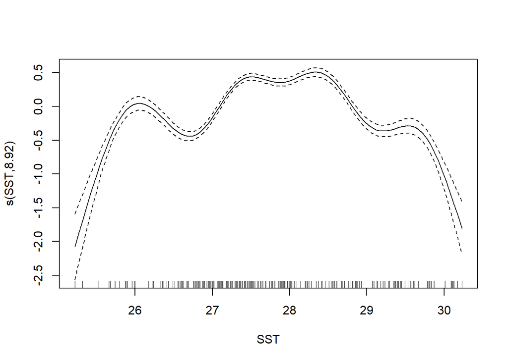

```r
#Run the GLM:
gam.out<-gam(Hammerheads~Year+s(SST)+ONI+Visibility, family = "poisson", data=hammerhead_sharks) #fit SST with a "smooth" term (ie splines)

#Visualize the non-linear relationship fit between hammerhead count and SST:
plot(gam.out)
```

```r
#Get the coefficients (intercept, slopes) and p-values from a Wald's Z-test:
summary(gam.out)
```

```
##
## Family: poisson
## Link function: log
##
## Formula:
## Hammerheads ~ Year + s(SST) + ONI + Visibility
##
## Parametric coefficients:
##              Estimate Std. Error z value Pr(>|z|)
## (Intercept) 78.675546   4.396564   17.89   <2e-16 ***
## Year        -0.037819   0.002183  -17.32   <2e-16 ***
## ONI         -0.551856   0.018054  -30.57   <2e-16 ***
## Visibility   0.018219   0.001591   11.45   <2e-16 ***
## ---
## Signif. codes:  0 '***' 0.001 '**' 0.01 '*' 0.05 '.' 0.1 ' ' 1
##
## Approximate significance of smooth terms:
##          edf Ref.df Chi.sq p-value
## s(SST) 8.916  8.998  825.9  <2e-16 ***
## ---
## Signif. codes:  0 '***' 0.001 '**' 0.01 '*' 0.05 '.' 0.1 ' ' 1
##
## R-sq.(adj) =  0.0953   Deviance explained =   19%
## UBRE = 40.558  Scale est. = 1         n = 270
```

```r
#Get the AIC:
AIC(gam.out)
```

```
## [1] 12169.96
```

## Non-linear models

Models that are linear in the parameters can be fit with gam or polynomials using lm() if non-linear relationships exist between response and explanatory variables, but models that are non-linear in the parameters need another function - nls().

Use: nls(y~“insert non-linear equation here”, start=list(“list starting values for parameters”), data=data name). The starting values are rough guesses to get the function started in fitting the model. See the example below. The “y” needs to be the name of your response variable in your data frame. The x value specified in your equation/formula needs to be called the same thing as its column in the data frame.

The von-Bertalanffy function is: Length (at age) = L_infinity(1-exp(-k(age-t0))) where t is the age and t0 is the age when length is zero and L_infinity is asymptotic maximum length.

```r
#make the von-Bertalanffy function

#Simulate some data for the example:
von_Bert<-function(age, t0, L_infinity, k) {L_infinity*(1-exp(-k*(age-t0)))} #von Bert function for simulating data in the next line.
salmon<-data.frame(age=rep(1:6, 20), length=rnorm(120, von_Bert(age=c(1:6), t0=0.63, L_infinity=927, k=0.79), sd=50)) # I have simulated some salmon age-length data with known parameters. We can check that the nls function gets the right values!

nonlin_mod<-nls(length~L_infinity*(1-exp(-k*(age-t0))),start=list(t0=0.2,L_infinity=1000,k=1), data=salmon) #I have my y "length" versus the von Bert formula, with "age" as my x. The nls function will search for the best fit values for the other parameters (t0, L_infinity, k) starting its search from the vaues given. List starting values for each parameter, make an educated guess (ie remember L_infinity is max length - use biological interpretations of parameters to estimate good starting values). The names of the y- and x-variables (ie length and age, respectively) must match that in the data frame.

summary(nonlin_mod) #get estimates and significance for each parameter
```

```
##
## Formula: length ~ L_infinity * (1 - exp(-k * (age - t0)))
##
## Parameters:
##             Estimate Std. Error t value Pr(>|t|)
## t0           0.57911    0.03572   16.21   <2e-16 ***
## L_infinity 931.72164   11.11423   83.83   <2e-16 ***
## k            0.76004    0.04431   17.15   <2e-16 ***
## ---
## Signif. codes:  0 '***' 0.001 '**' 0.01 '*' 0.05 '.' 0.1 ' ' 1
##
## Residual standard error: 52.43 on 117 degrees of freedom
##
## Number of iterations to convergence: 4
## Achieved convergence tolerance: 1.572e-08
```

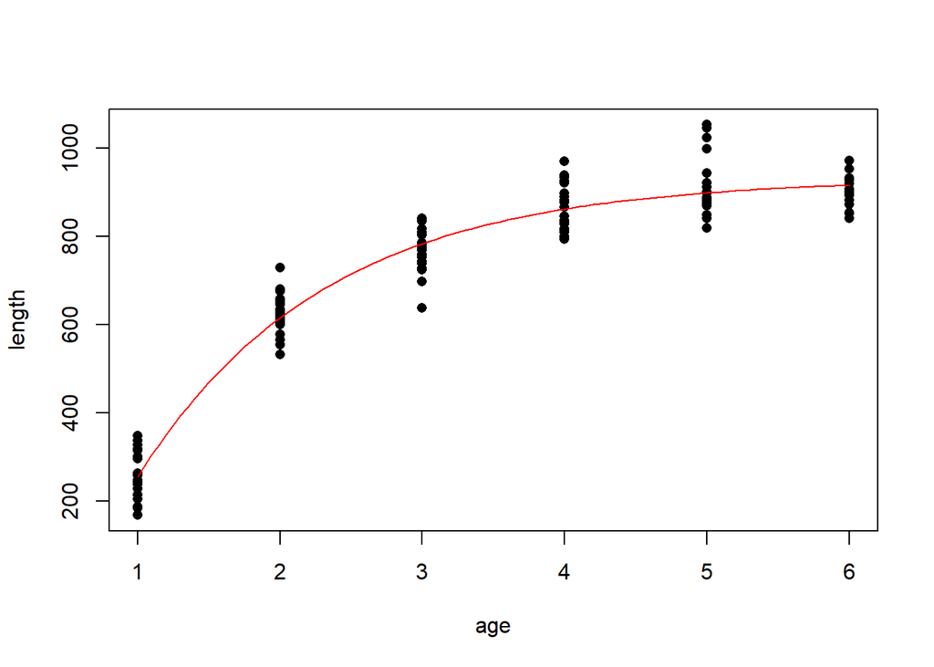

```r
#Plot the data and the curve:
plot(length~age, data=salmon, pch=16)
#get the model coefficients to plot the curve specified by the nls model:
t0_estimate<-coef(nonlin_mod)[1] #t0 is the first coefficient in coef(nonlin_mod)
L_infinity_estimate<-coef(nonlin_mod)[2] #L_infinity is the second coefficient in coef(nonlin_mod)
k_estimate<-coef(nonlin_mod)[3] #k is the third coefficient in coef(nonlin_mod)
age_x<-c(1:6) #want to plot for ages 1 to 6
curve(L_infinity_estimate*(1-exp(-k_estimate*(x-t0_estimate))), from=1, to=6, add=TRUE, col="red") #add the curve from the model to the plot. The curve() function gives the y-values (ie lengths) from the given expression/formula evaluating the x-value (in this case, age) from the value in "from" to the value in "to" - ie from age 1 to age 6. add=TRUE ensures the curve is added to the plot we just made above.
```

```r
#Get the AIC:
AIC(nonlin_mod)
```

```
## [1] 1295.796
```

## AIC and Likelihood Ratio Tests

AIC can be used to compare numerous candidate models based on their fit (likelihood), penalized by number of parameters to account for overfitting. The dredge function in the MuMIn package will calculate the AIC for all possible subsets of your model, and include delta-AICs and model weights.

Likelihood ratio tests are another way to assess significance of a parameter (besides t-tests/Wald z-tests provided by summary function). They will compare the increase in likelihood from a simpler model to a more complex one and give a p-value representing if that increase represents a significant increase in fit (meaning the model explains something more biologically) or if it is just overfitting. Models must be nested.

```r
hammerhead_sharks<-read.csv("c:/Users/gjosg/Dropbox/R_Handbook_2020_UVic/Data/Hammerheads.csv", header=TRUE)
head(hammerhead_sharks)
```

```
##   Year SiteCode Visibility DiverCode Hammerheads   SST   ONI
## 1 2012      110         12         9           1 29.40 -0.38
## 2 2018      103         15         3          20 29.53 -0.41
## 3 2016      103         12         4          15 27.13 -0.74
## 4 2007      101         30         3          20 29.18  0.32
## 5 2019      112         24        43          40 27.77  0.13
## 6 2007      111          9         3          15 25.53 -1.60
```

```r
#Run the GLM:
glm.poisson<-glm(Hammerheads~Year+SST+ONI+Visibility, family = "poisson", data=hammerhead_sharks, na.action = "na.fail") #model the relationship between hammerhead counts and year, SST, ONI, and visibility. na.action="na.fail" is needed for dredge() to work - it means the model will not run if there are NAs in any explanatory variable.

#Use the function AIC() to get the AIC of one or more models:
AIC(glm.poisson, update(glm.poisson, ~.-Year)) #compare AIC of full model to updated model lacking Year
```

```
##                                df      AIC
## glm.poisson                     5 13123.66
## update(glm.poisson, ~. - Year)  4 13426.13
```

```r
#dredge for the best candidate model among all possible subsets of your full model:
library(MuMIn)
dredge(glm.poisson)
```

```
## Fixed term is "(Intercept)"
```

```
## Global model call: glm(formula = Hammerheads ~ Year + SST + ONI + Visibility, family = "poisson",
##     data = hammerhead_sharks, na.action = "na.fail")
## ---
## Model selection table
##    (Intrc)     ONI        SST   Vsblt     Year df    logLik    AICc   delta
## 14  77.980 -0.4124            0.01840 -0.03742  4 -6556.834 13121.8    0.00
## 16  77.960 -0.4120 -0.0007929 0.01841 -0.03740  5 -6556.832 13123.9    2.07
## 10  96.690 -0.4220                    -0.04656  3 -6629.686 13265.5  143.64
## 12  96.820 -0.4257  0.0085170         -0.04674  4 -6629.398 13266.9  145.13
## 8    3.441 -0.4450 -0.0292000 0.02775           4 -6709.064 13426.3  304.46
## 6    2.628 -0.4586            0.02775           3 -6712.380 13430.8  309.03
## 15  88.280         -0.0893000 0.02120 -0.04130  4 -6888.798 13785.7  663.93
## 4    3.850 -0.4741 -0.0246800                   3 -6899.962 13806.0  684.19
## 2    3.163 -0.4862                              2 -6902.370 13808.8  686.96
## 13  91.350                    0.02082 -0.04406  3 -6920.485 13847.1  725.24
```

[output cut: 24 more lines]

# Permutation tests

Permutation tests are a type of non-parametric test used when the assumptions of a parametric test (ie t-tes, ANOVA, regression) are not met. Permutation tests resample from the data, ignoring the explanatory variables, to generate a null-distribution of the response variable assuming explanatory variables do not matter. The test compares the data to this null-distribution generated by permutation to see if the data fall within the center of the distribution (high p-value) or in the extremes (small p-value).

Use: adonis(y~x, data=data name) in the vegan package

oneway_test(y~x,data=data name) in the coin package

The coin package lets you calculate asymptotic p-values (like nonparametric tests) or approximate p-values (taking many random samples) or exact p-values (from all possible combinations).

Example: compare number of ant colonies in a field versus a forest

Example origin and more code here: https://mac-theobio.github.io/QMEE/permutation_examples.html

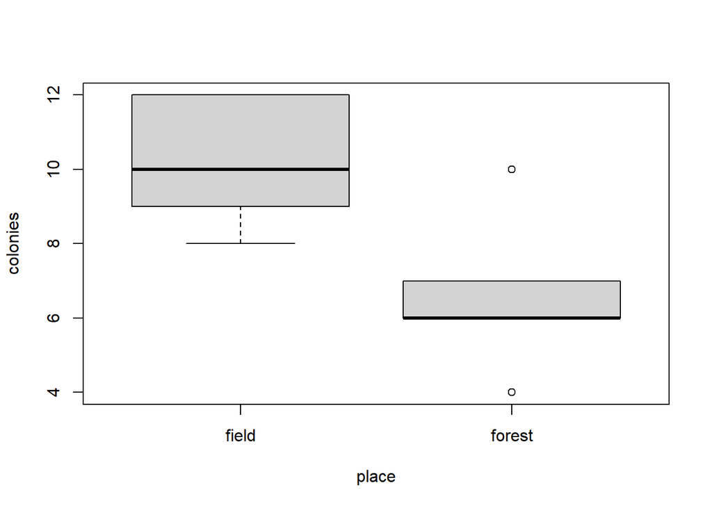

```r
#the data:
ants<-data.frame(place=rep(c("field", "forest"), rep(5,2)), colonies=c(12,9,12,10,8,6,4,6,7,10))

#plot the data:
boxplot(colonies~place, data=ants)
```

```r
#run a permutation test:
#install.packages("coin")
library(coin)
#your categorical variable needs to be a factor:
ants$place<-as.factor(ants$place)

#Asymptotic (the default - similar to rank-based non-parametric tests)
oneway_test(colonies~place,data=ants)
```

```
##
##  Asymptotic Two-Sample Fisher-Pitman Permutation Test
##
## data:  colonies by place (field, forest)
## Z = 2.1279, p-value = 0.03335
## alternative hypothesis: true mu is not equal to 0
```

```r
#Exact (all possible permutations):
oneway_test(colonies~place,data=ants,distribution="exact")
```

```
##
##  Exact Two-Sample Fisher-Pitman Permutation Test
##
## data:  colonies by place (field, forest)
## Z = 2.1279, p-value = 0.03968
## alternative hypothesis: true mu is not equal to 0
```

```r
#Approximate (random-sampling):
oneway_test(colonies~place,data=ants,distribution=approximate(nresample=9999))
```

```
##
##  Approximative Two-Sample Fisher-Pitman Permutation Test
##
## data:  colonies by place (field, forest)
## Z = 2.1279, p-value = 0.0401
## alternative hypothesis: true mu is not equal to 0
```

## Permutation test - manual approach

You can make your own permutation test, altering the test statistic calculated in each permutation using for loops.

For each permutation of the data, you will calculate some test statistics (difference in means between groups, a t-statistic, an F-statistic). At the end, you compile a distribution of these test statistics calculated from these permutations - a permutation-generated null distribution for your test statistic. Compare the test statistic of your actual data to this null distribution representing the permutations, and see if it falls in the extreme 5% (the tails). For a permutation test to replace an ANOVA, a F-statistic may be a good choice as a test statistic to calculate each permutation.

For more: https://mac-theobio.github.io/QMEE/permutation_examples.html

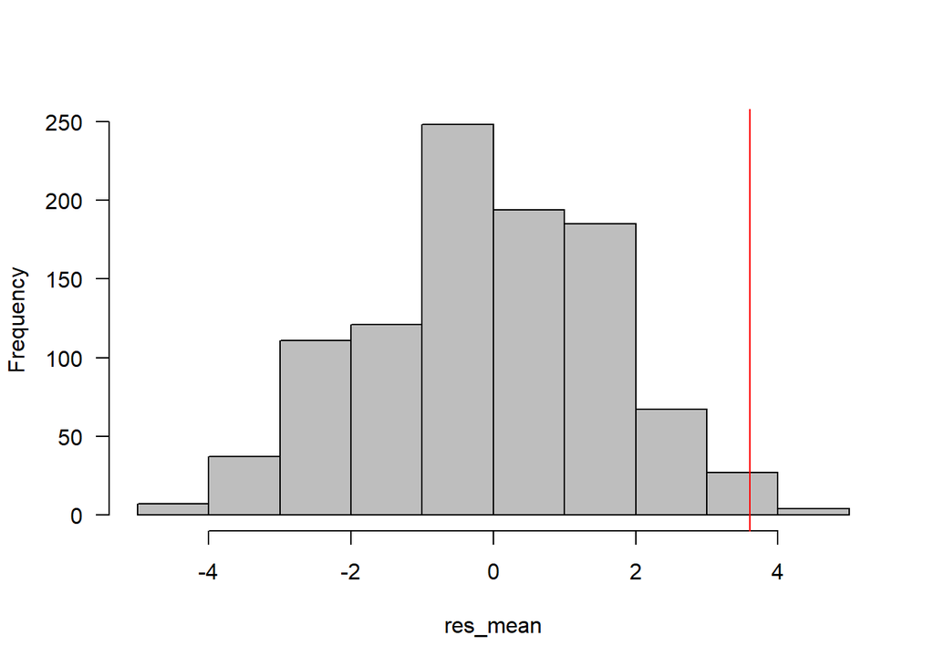

```r
set.seed(66) ##ensures random processes "start" at the same place in the computing, so each time you run this code, you will get the same answers, for reproducibility, despite it being random. Pick any number, as long as you keep it consistent every time you run this code.
nsim <- 1000 #number of simulations/permutations
res_mean <- numeric(nsim) ## make a numeric vector (ie stores numbers) to save the differences in means in each permutation
res_t <- numeric(nsim) ## make a numeric vector to save the t-statistics in each permutation
#this for loop will run the code in the {} nsim times.
for (i in 1:nsim) {
    ## standard approach: scramble response value
    perm <- sample(nrow(ants)) #sample all rows of ants in random order
    bdat <- transform(ants,colonies=colonies[perm]) #combine these randomly sampled rows with the explanatory variable column (ie forest or field) of the original data frame. This scrambles the response variable column across the explanatory variables.

## compute & store test statistic (eg. difference in means, t-statistic); store the value
# change this code for test statistic of your liking:
  #NOTE I give two examples (difference in means and t-statistic, but you need only one)
   #difference in means:
     agg <- aggregate(colonies~place,FUN=mean,data=bdat) #compute means by group (field vs forest)
  res_mean[i] <- agg$colonies[1]-agg$colonies[2] #save the difference in means for this permutation of the data in the numeric vector
  #t-statistic (difference in means divided by standard error):
    tt <- t.test(colonies~place,data=bdat,var.equal=TRUE) #calculate t-statistic
    res_t[i] <- tt$statistic #save this permutation's t-statistic in the numeric vector

}
obs_mean <- mean(ants[ants$place=="field","colonies"])-
    mean(ants[ants$place=="forest","colonies"]) #calculate your observed difference in means (from your actual data), which you will compare to the null distribution you just generated in the foor loop (saved in res_mean)
obs_t <- t.test(colonies~place,data=bdat,var.equal=TRUE)$statistic #calculate t-statistic for the observed data

## append the observed value to the list of results
res_mean <- c(res_mean,obs_mean) #your observed data count as a permutation, so you add it to the permutation results
res_t <- c(res_t,obs_t) #add observed t-statistic to permutation-generated t-statistics

#histogram representing your permutation-generated null distribution:
hist(res_mean,col="gray",las=1,main="")
abline(v=obs_mean,col="red") #red line for where the observed data fall (is it in the center or extreme?)
```

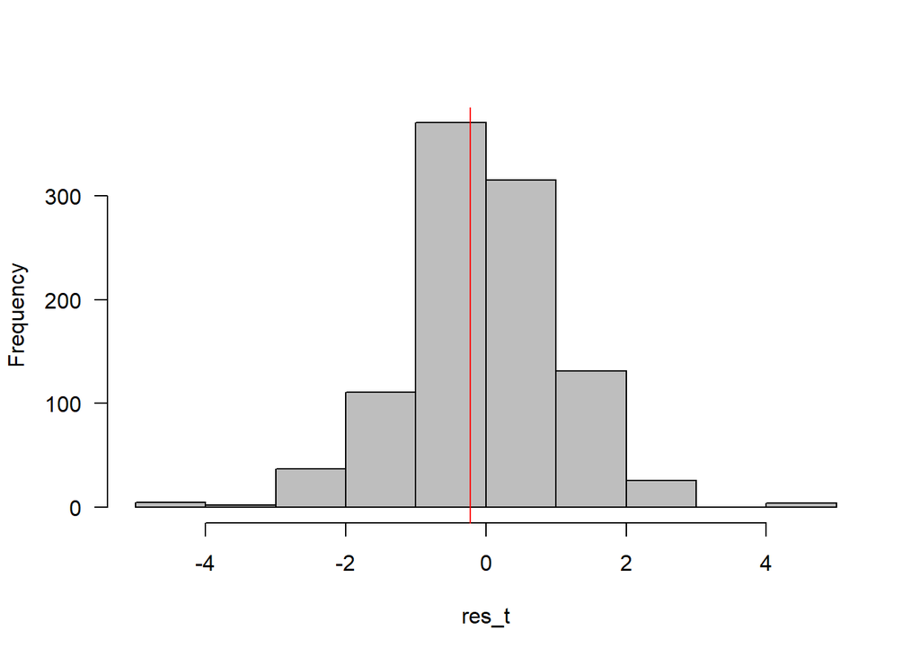

```r
#histogram using t-statistic as test statistic:
hist(res_t,col="gray",las=1,main="")
abline(v=obs_t,col="red")
```

```r
#Results of the permutation test:
mean(abs(res_mean)>=abs(obs_mean)) #p-value
```

```
## [1] 0.03396603
```

```r
mean(abs(res_t)>=abs(obs_t)) #p-value
```

```
## [1] 0.9170829
```

# Multivariate statistics

For when you have multiple response variables, and what to visual and investigate how they co-vary (especially used in community ecology with presence/absence or abundance of species as multiple responses across many sites).

Data should be set up as a “species by site” matrix - species (or other response variable) as columns and sites (or other sampling unit) as rows - matrix is filled in by values of each response (eg. species abundance) for each sampling unit (eg site).

The package “vegan” will handle most analyses.

The package “factoextra” helps make visualizations of ordination results.

For information on ordination, check out “Numerical Ecology with R” by Daniel Borcard, Francois Gillet, and Pierre Legendre.

This code loads the package and data for all the multivariate statistics examples.

```r
#install.packages("vegan")
library(vegan)
#install.packages("factoextra")
library(factoextra)
#load in example "dune" data set:
data(dune) #data on abundance of 30 species at 20 sites
head(dune)
```

```
##   Achimill Agrostol Airaprae Alopgeni Anthodor Bellpere Bromhord Chenalbu
## 1        1        0        0        0        0        0        0        0
## 2        3        0        0        2        0        3        4        0
## 3        0        4        0        7        0        2        0        0
## 4        0        8        0        2        0        2        3        0
## 5        2        0        0        0        4        2        2        0
## 6        2        0        0        0        3        0        0        0
##   Cirsarve Comapalu Eleopalu Elymrepe Empenigr Hyporadi Juncarti Juncbufo
## 1        0        0        0        4        0        0        0        0
## 2        0        0        0        4        0        0        0        0
## 3        0        0        0        4        0        0        0        0
## 4        2        0        0        4        0        0        0        0
## 5        0        0        0        4        0        0        0        0
## 6        0        0        0        0        0        0        0        0
##   Lolipere Planlanc Poaprat Poatriv Ranuflam Rumeacet Sagiproc Salirepe
## 1        7        0       4       2        0        0        0        0
## 2        5        0       4       7        0        0        0        0
## 3        6        0       5       6        0        0        0        0
## 4        5        0       4       5        0        0        5        0
## 5        2        5       2       6        0        5        0        0
## 6        6        5       3       4        0        6        0        0
##   Scorautu Trifprat Trifrepe Vicilath Bracruta Callcusp
## 1        0        0        0        0        0        0
## 2        5        0        5        0        0        0
## 3        2        0        2        0        2        0
## 4        2        0        1        0        2        0
## 5        3        2        2        0        2        0
## 6        3        5        5        0        6        0
```

```r
data(dune.env)#environmental data on those 20 sites
head(dune.env)
```

```
##    A1 Moisture Management      Use Manure
## 1 2.8        1         SF Haypastu      4
## 2 3.5        1         BF Haypastu      2
## 3 4.3        2         SF Haypastu      4
## 4 4.2        2         SF Haypastu      4
## 5 6.3        1         HF Hayfield      2
## 6 4.3        1         HF Haypastu      2
```

## Principal Component Analysis (PCA)

The function prcomp() runs a PCA in base R. The function rda() runs “redundancy analysis” (RDA) - which is a PCA constrained by explanatory variables. Use “~1” to indicate no explanatory variables and run just a PCA. You can include explanatory variables to run an RDA.

The FactoMineR package is also useful. Check out this video (and related videos) by the package author: https://www.youtube.com/watch?v=pks8m2ka7Pk.

Other plotting options: https://cran.r-project.org/web/packages/ggfortify/vignettes/plot_pca.html

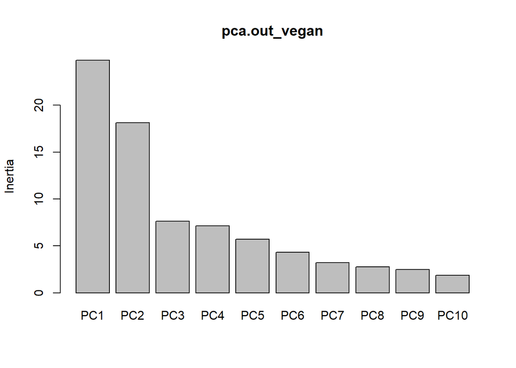

```r
#Two functions to run a PCA:

pca.out_base<-prcomp(dune)
pca.out_vegan<-rda(dune~1)

#Scree plots (percentage of variation explained by each principal component axis):
screeplot(pca.out_vegan) #drop-off after second axis, suggesting only first two axes need examining
```

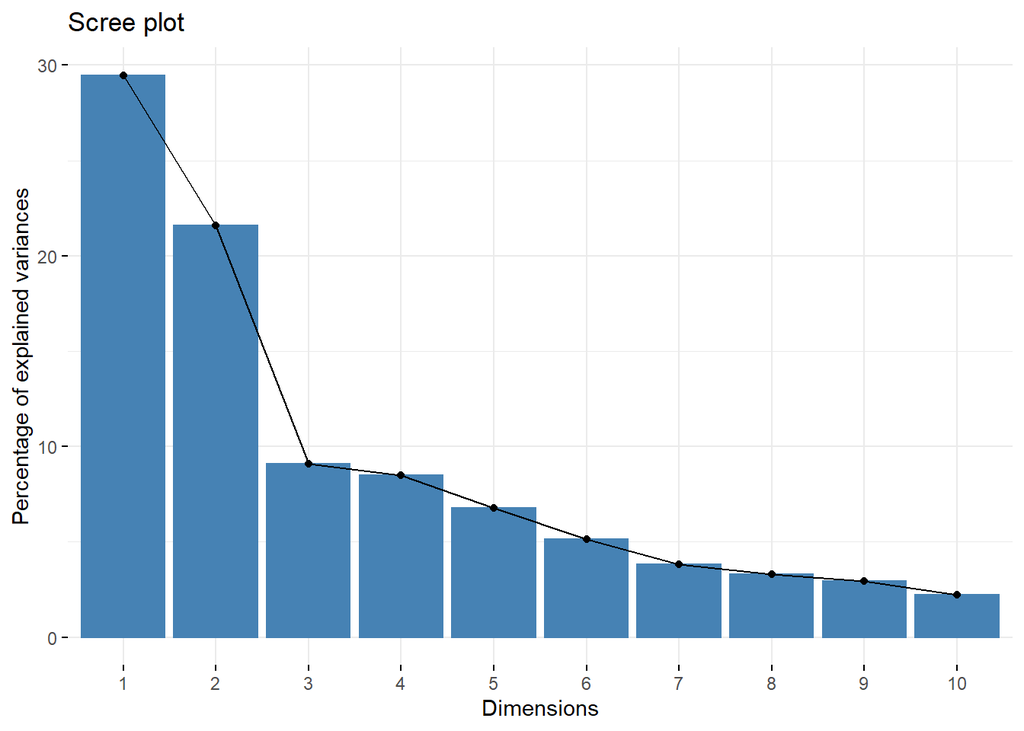

```r
fviz_eig(pca.out_base)
```

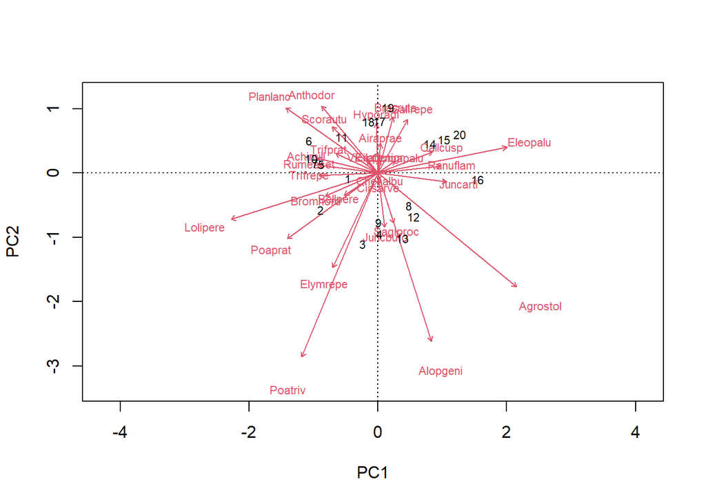

```r
#Examine biplots:
#scaling=1 (for individuals/sites/samples):
biplot(pca.out_vegan, scaling=1)
```

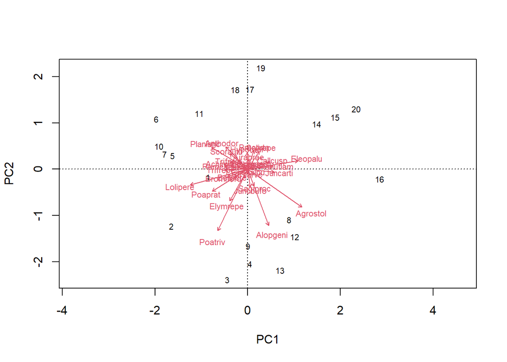

```r
#scaling=2 (for species/response):
biplot(pca.out_vegan, scaling=2)
```

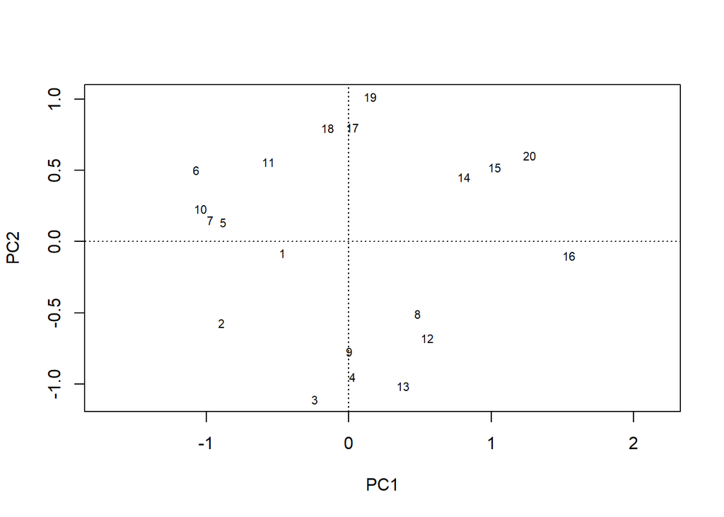

```r
#only show the individuals/sites/samples:
biplot(pca.out_vegan, scaling=1, display="sites")
```

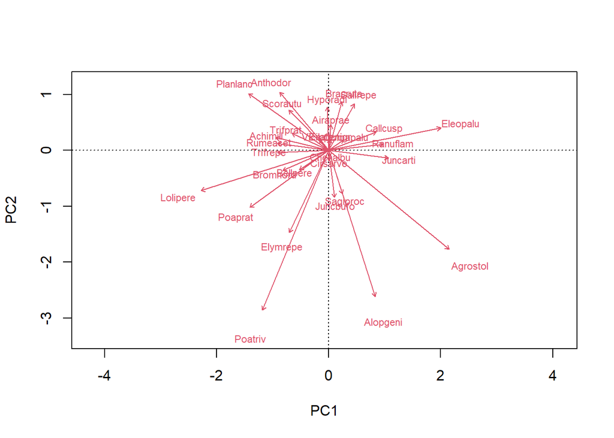

```r
#only show the species/response:
biplot(pca.out_vegan, scaling=1, display="species")
```

```r
#Summary of results - proportion of variance explained, species scores, PC values for each site.
summary(pca.out_vegan)
```

```
##
## Call:
## rda(formula = dune ~ 1)
##
## Partitioning of variance:
##               Inertia Proportion
## Total           84.12          1
## Unconstrained   84.12          1
##
## Eigenvalues, and their contribution to the variance
##
## Importance of components:
##                           PC1     PC2     PC3     PC4    PC5     PC6     PC7
## Eigenvalue            24.7953 18.1466 7.62913 7.15277 5.6950 4.33331 3.19936
## Proportion Explained   0.2947  0.2157 0.09069 0.08503 0.0677 0.05151 0.03803
## Cumulative Proportion  0.2947  0.5105 0.60115 0.68618 0.7539 0.80539 0.84342
##                           PC8    PC9    PC10    PC11    PC12    PC13     PC14
## Eigenvalue            2.78186 2.4820 1.85377 1.74712 1.31358 0.99051 0.637794
## Proportion Explained  0.03307 0.0295 0.02204 0.02077 0.01561 0.01177 0.007582
## Cumulative Proportion 0.87649 0.9060 0.92803 0.94880 0.96441 0.97619 0.983768
##                           PC15     PC16     PC17     PC18     PC19
## Eigenvalue            0.550827 0.350584 0.199556 0.148798 0.115753
## Proportion Explained  0.006548 0.004167 0.002372 0.001769 0.001376
## Cumulative Proportion 0.990316 0.994483 0.996855 0.998624 1.000000
##
## Scaling 2 for species and site scores
## * Species are scaled proportional to eigenvalues
## * Sites are unscaled: weighted dispersion equal on all dimensions
## * General scaling constant of scores:  6.322924
##
##
## Species scores
##
##                PC1      PC2       PC3       PC4      PC5       PC6
## Achimill -0.603786  0.12392  0.008464  0.159574  0.40871  0.127857
## Agrostol  1.373953 -0.96401  0.166905  0.266466 -0.08765  0.047368
## Airaprae  0.023415  0.25078 -0.194768 -0.326043  0.05574 -0.079619
## Alopgeni  0.531234 -1.42784 -0.505241 -0.042885 -0.44293  0.278566
## Anthodor -0.559138  0.56761 -0.476205  0.015781  0.34408 -0.135783
## Bellpere -0.333560 -0.18881  0.140638 -0.084177  0.12541  0.134771
```

[output cut: 34 more lines]

```
## 6  -1.97427  1.0802 -1.1501  3.3534 -1.52026  0.03127
## 7  -1.79263  0.3220 -0.2200  1.4714  0.01245 -0.42583
## 8   0.88980 -1.0905  0.9250  0.5165 -1.08897  0.94777
## 9   0.00904 -1.6570 -0.4661 -0.2826 -0.10821 -2.16570
## 10 -1.91463  0.4940  0.7058  0.2676  1.36985  2.62386
## 11 -1.04110  1.2081  1.4203 -0.9566 -2.71745  1.11200
## 12  1.01822 -1.4598 -3.2509 -0.3247 -1.75331  1.01550
## 13  0.69939 -2.1837 -2.2128 -0.4231  1.06502  0.65585
## 14  1.49047  0.9772  0.5447  0.2733  2.38875  2.47896
## 15  1.88644  1.1261  0.7271  0.7732  0.22113 -0.31750
## 16  2.84848 -0.2081  0.7041  2.1012  0.29311 -0.08124
## 17  0.04666  1.7279 -0.9135 -1.6663  1.80070 -1.55572
## 18 -0.26936  1.7157  0.1648 -0.5770 -2.10498  0.33880
## 19  0.28094  2.1901 -1.9865 -3.2341 -0.45760 -0.02389
## 20  2.34069  1.2991  0.9029  0.7178 -0.07573 -0.96909
```

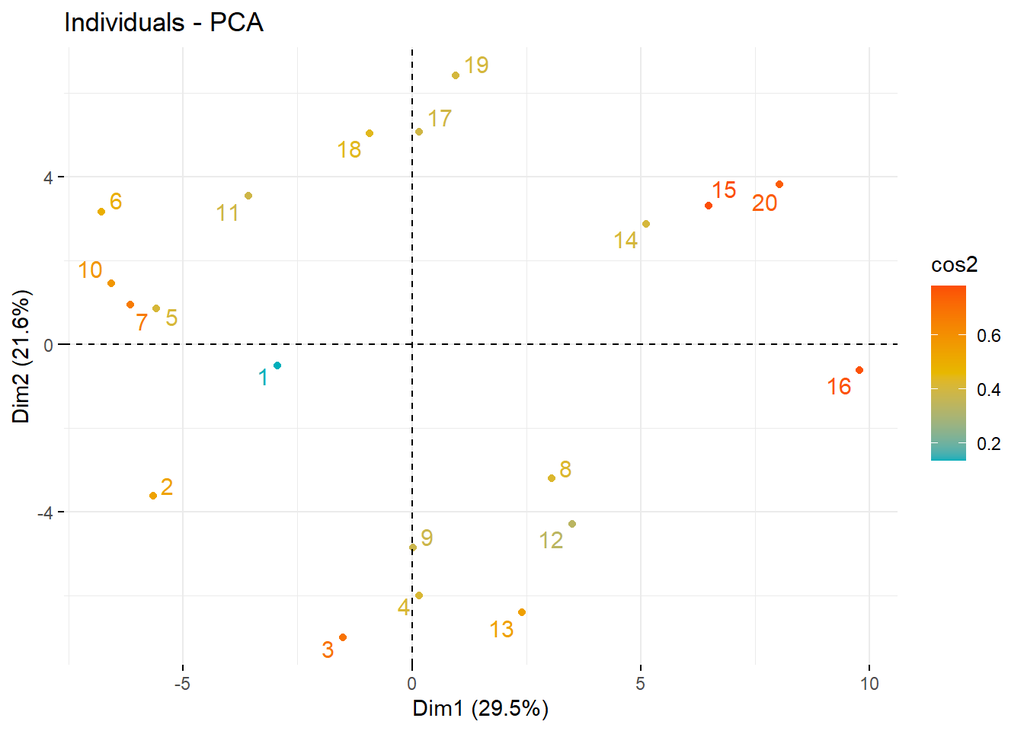

```r
#####Using factoextra on prcomp results:######
#check out: http://www.sthda.com/english/articles/31-principal-component-methods-in-r-practical-guide/118-principal-component-analysis-in-r-prcomp-vs-princomp/#package-for-pca-visualization

#Coloured plot of sites:
fviz_pca_ind(pca.out_base,
             col.ind = "cos2", # Color by the quality of representation (ie how well the site is represented by the PCA)
             gradient.cols = c("#00AFBB", "#E7B800", "#FC4E07"),
             repel = TRUE     # Avoid text overlapping
             )
```

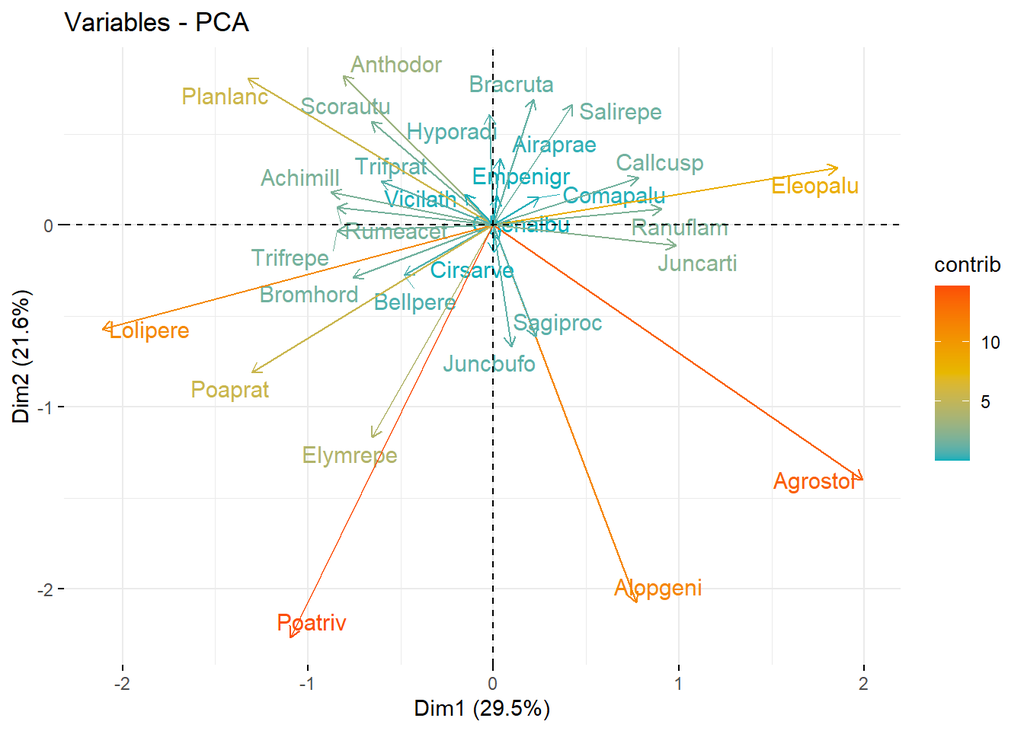

```r
#Plot of contributions of each species/response to each axis for base PCA:
fviz_pca_var(pca.out_base,
             col.var = "contrib", # Color by contributions to the PC
             gradient.cols = c("#00AFBB", "#E7B800", "#FC4E07"),
             repel = TRUE     # Avoid text overlapping
             )
```

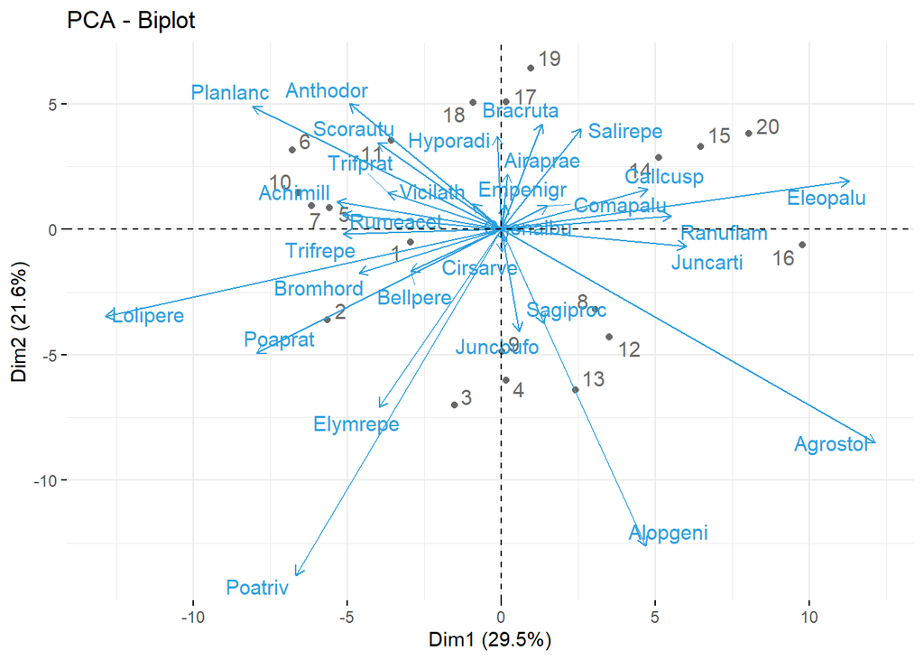

```r
#Coloured biplot of sites and species/responses
fviz_pca_biplot(pca.out_base, repel = TRUE,
                col.var = "#2E9FDF", # Response variables color
                col.ind = "#696969"  # Individuals color
                )
```

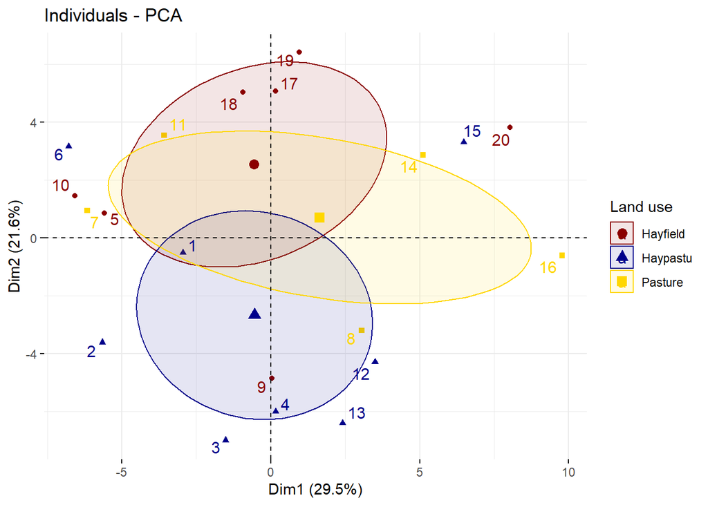

```r
#Visualize categorical grouping variable:
#Add ellipses representing the average and 95% confidence interval for sites by land use type (or other grouping variable)
fviz_pca_ind(pca.out_base,
             col.ind = as.character(dune.env$Use), # color by groups (in this case "Use")
             palette = c("darkred",  "darkblue", "gold"),
             addEllipses = TRUE, # Concentration ellipses
             ellipse.type = "confidence",
             legend.title = "Land use",
             repel = TRUE
             )
```

## Correspondence analysis

Correspondence analysis (CA) investigates relative relationships between groups of variables based on contigency table - ie interpret your “species by site” matrix as a contigency table of frequencies. For instance, unlike PCA, CA investigates variance in relative abundance or values among species/responses rather than using the absolute abundance or values in the column. Are some species or groups of species associated with some sites?

The function cca() in “vegan” runs a canonical correspondance analysis (CCA) - see below. But if you use “~1” it will run a normal CA.

Also check out ca() in the “ca” package, CA() in the FactoMineR package, and corresp() in the “MASS” package. Check out: https://www.gastonsanchez.com/visually-enforced/how-to/2012/07/19/Correspondence-Analysis/

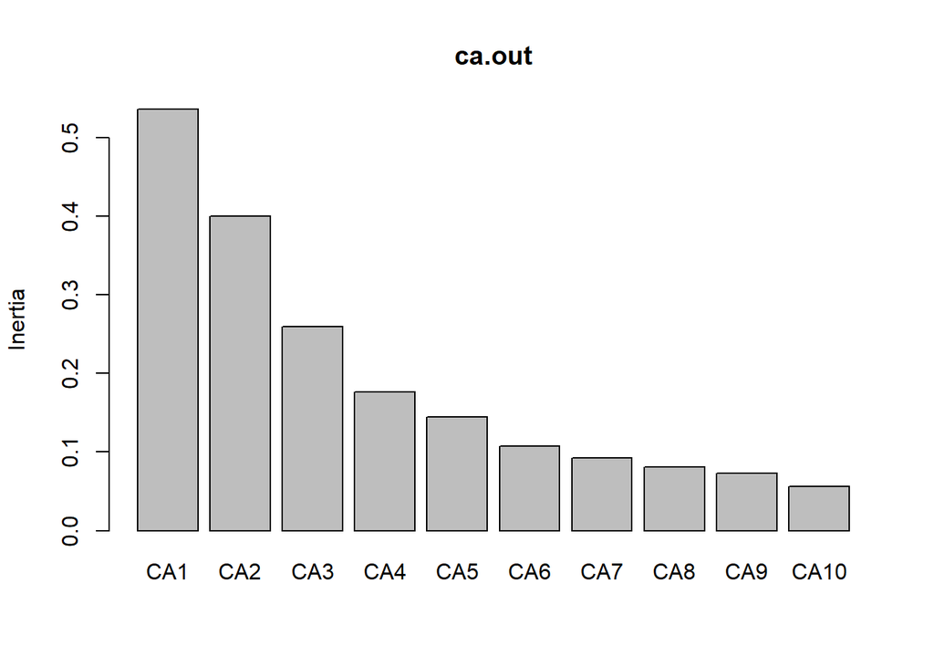

```r
#Run the CA:
ca.out<-cca(dune~1)

#Scree plots (percentage of variation explained by each principal component axis):
screeplot(ca.out) #drop-off after second axis, suggesting only first two axes need examining
```

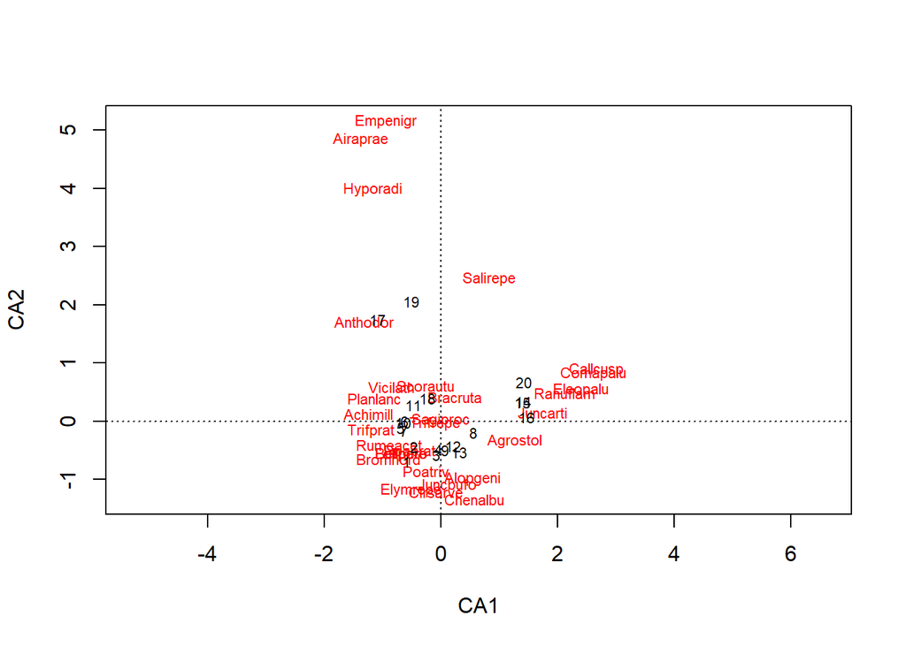

```r
#Examine biplots - NOTE use plot() here:
#scaling=1 (for individuals/sites/samples):
plot(ca.out, scaling=1)
```

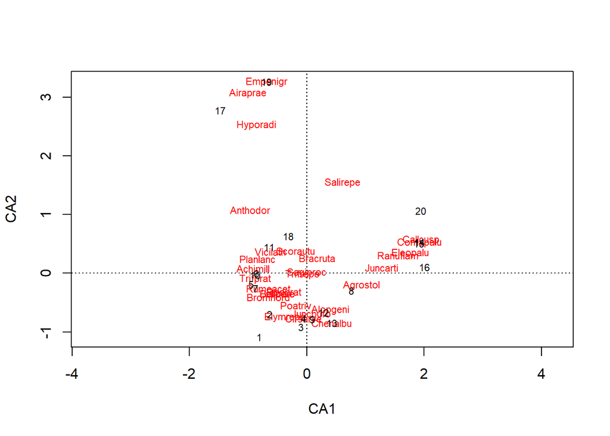

```r
#scaling=2 (for species/response):
plot(ca.out, scaling=2)
```

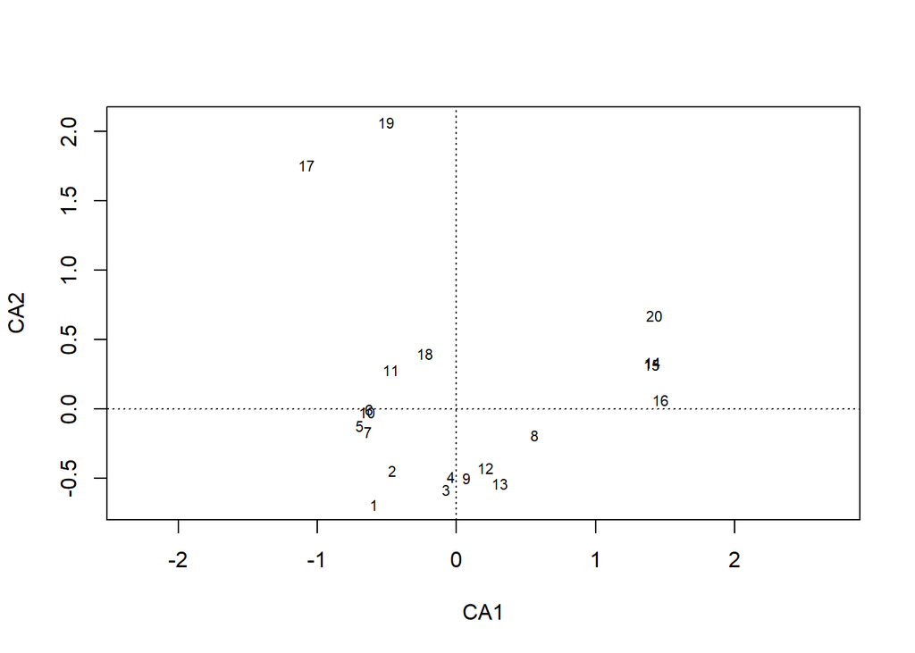

```r
#only show the individuals/sites/samples:
plot(ca.out, scaling=1, display="sites")
```

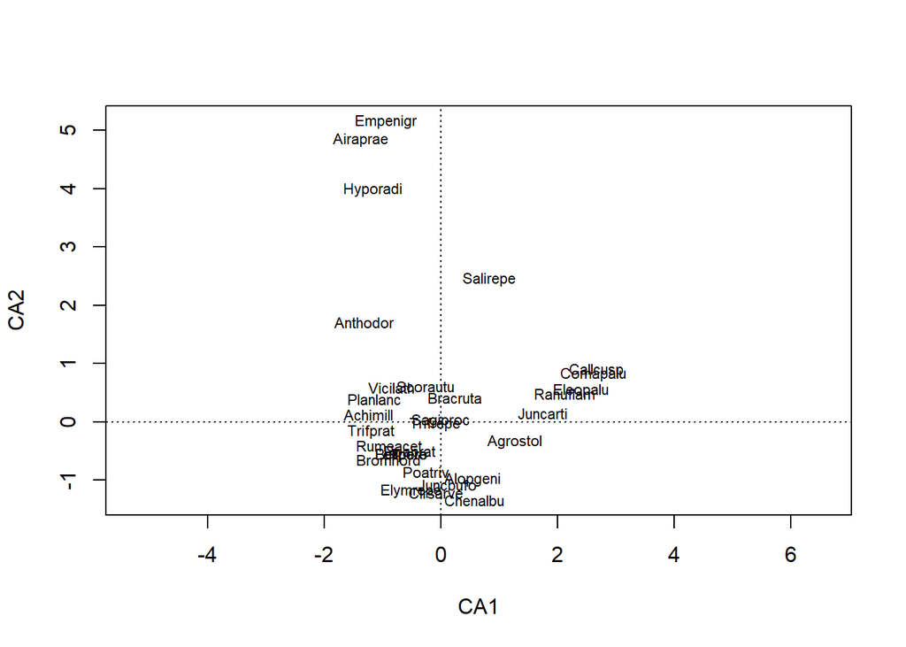

```r
#only show the species/response:
plot(ca.out, scaling=1, display="species")
```

```r
#Summary of results - proportion of variance explained, species scores, PC values for each site.
summary(ca.out)
```

```
##
## Call:
## cca(formula = dune ~ 1)
##
## Partitioning of scaled Chi-square:
##               Inertia Proportion
## Total           2.115          1
## Unconstrained   2.115          1
##
## Eigenvalues, and their contribution to the scaled Chi-square
##
## Importance of components:
##                          CA1    CA2    CA3     CA4     CA5     CA6     CA7
## Eigenvalue            0.5360 0.4001 0.2598 0.17598 0.14476 0.10791 0.09247
## Proportion Explained  0.2534 0.1892 0.1228 0.08319 0.06844 0.05102 0.04372
## Cumulative Proportion 0.2534 0.4426 0.5654 0.64858 0.71702 0.76804 0.81175
##                           CA8     CA9    CA10    CA11    CA12    CA13     CA14
## Eigenvalue            0.08091 0.07332 0.05630 0.04826 0.04125 0.03523 0.020529
## Proportion Explained  0.03825 0.03466 0.02661 0.02282 0.01950 0.01665 0.009705
## Cumulative Proportion 0.85000 0.88467 0.91128 0.93410 0.95360 0.97025 0.979955
##                           CA15     CA16     CA17     CA18     CA19
## Eigenvalue            0.014911 0.009074 0.007938 0.007002 0.003477
## Proportion Explained  0.007049 0.004290 0.003753 0.003310 0.001644
## Cumulative Proportion 0.987004 0.991293 0.995046 0.998356 1.000000
##
## Scaling 2 for species and site scores
## * Species are scaled proportional to eigenvalues
## * Sites are unscaled: weighted dispersion equal on all dimensions
##
##
## Species scores
##
##               CA1      CA2      CA3       CA4       CA5      CA6
## Achimill -0.90859  0.08461 -0.58636 -0.008919 -0.660183 -0.18877
## Agrostol  0.93378 -0.20651  0.28165  0.024293 -0.139326 -0.02256
## Airaprae -1.00434  3.06749  1.33773  0.194305 -1.081813 -0.53699
## Alopgeni  0.40088 -0.61839  0.85013  0.346740  0.016509  0.10169
## Anthodor -0.96676  1.08361 -0.17188  0.459788 -0.607533 -0.30425
## Bellpere -0.50018 -0.35503 -0.15239 -0.704153 -0.058546  0.07308
## Bromhord -0.65762 -0.40634 -0.30685 -0.496751 -0.561358  0.07004
```

[output cut: 33 more lines]

```
## 6  -0.85633 -0.0005408 -1.39735  1.59909  0.65494 -0.19386
## 7  -0.87149 -0.2547040 -0.86830  0.90468  0.17385 -0.03446
## 8   0.76268 -0.2968459  0.35648 -0.10772  0.17507 -0.36444
## 9   0.09693 -0.7864314  0.86492  0.40090  0.28704 -1.02783
## 10 -0.87885 -0.0353136 -0.82987 -0.68053 -0.75438  0.81070
## 11 -0.64223  0.4440332 -0.17371 -1.09684  1.37462  2.00626
## 12  0.28557 -0.6656161  1.64423  1.71496  0.65381  1.17376
## 13  0.42445 -0.8440195  1.59029  1.24876 -0.20748  0.87566
## 14  1.91996  0.5351062 -1.39863 -0.08575 -2.21317  2.43044
## 15  1.91384  0.5079036 -0.96567  0.04227 -0.50681  0.19370
## 16  2.00229  0.1090627 -0.33414  0.33760 -0.50097 -0.76159
## 17 -1.47545  2.7724102  0.40859  0.75117 -2.59425 -1.10122
## 18 -0.31241  0.6328355 -0.66501 -1.12728  2.65575  0.97565
## 19 -0.69027  3.2642026  1.95716 -0.17694 -0.07352 -0.16083
## 20  1.94438  1.0688809 -0.66595 -0.55317  1.59606 -1.70292
```

## Principal coordinates analysis (PCoA)

PCA and CA represent the Euclidean and Chi-square distance between sites/samples, respectively, in the ordination plots. In ecology, other ecological distance metrics are more appropriate to preserve and represent on the ordination (ie Bray-Curtis, Jaccard). Principal coordinates analysis (PCoA) analyses a matrix of dissimilarities (ie distances between pairs of sites/samples) computed from these other distance metrics.

The function capscale() in “vegan” runs PCoA. You include “~1” after your species by site matrix to run a PCoA and NOT a canonical analysis with explanatory variables (db-RDA - see below).

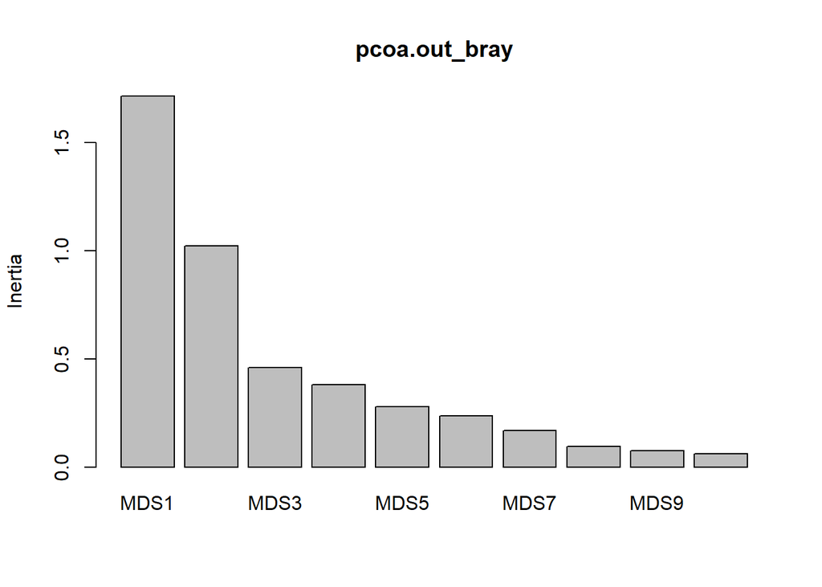

```r
#Run the PCoA (also called metric multidimensional scaline - MDS):

pcoa.out_bray<-capscale(dune~1, distance="bray") #Using Bray-Curtis distance
pcoa.out_jaccard<-capscale(dune~1, distance="jaccard") #Using Jaccard distance

#Distances can also be calculated first using vegdist from "vegan"
bray_dist<-vegdist(dune, distance="bray")
jaccard_dist<-vegdist(dune, distance="jaccard", binary=TRUE) #binary=TRUE caculates distance based on presence-absence data


#Scree plots (percentage of variation explained by each principal component axis):
screeplot(pcoa.out_bray) #drop-off after second axis, suggesting only first two axes need examining
```

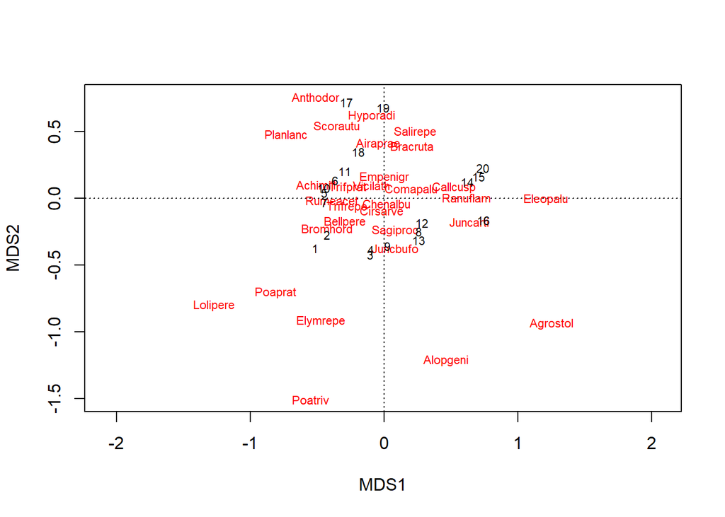

```r
#Examine biplots - NOTE use plot() here:
#scaling=1 (for individuals/sites/samples):
plot(pcoa.out_bray, scaling=1)
```

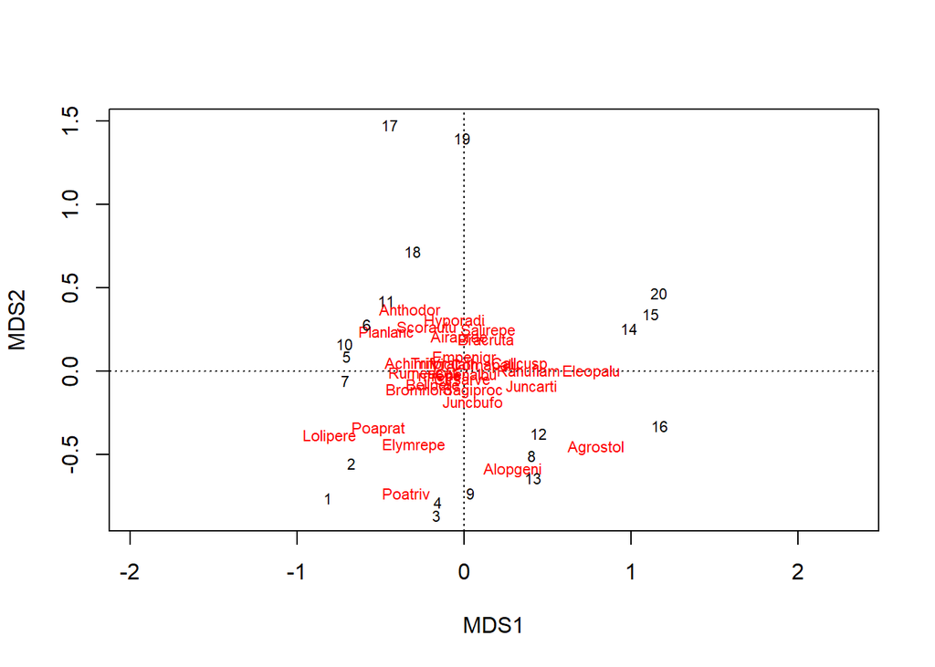

```r
#scaling=2 (for species/response):
plot(pcoa.out_bray, scaling=2)
```

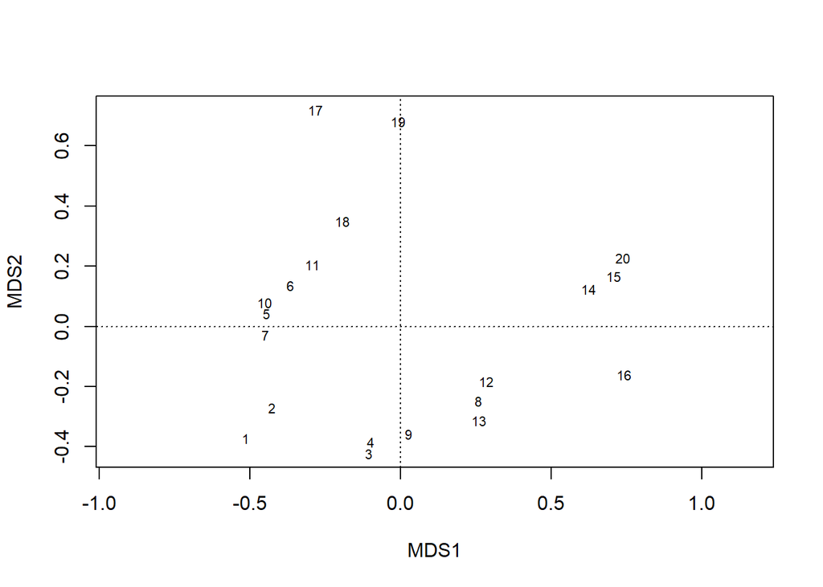

```r
#only show the individuals/sites/samples:
plot(pcoa.out_bray, scaling=1, display="sites")
```

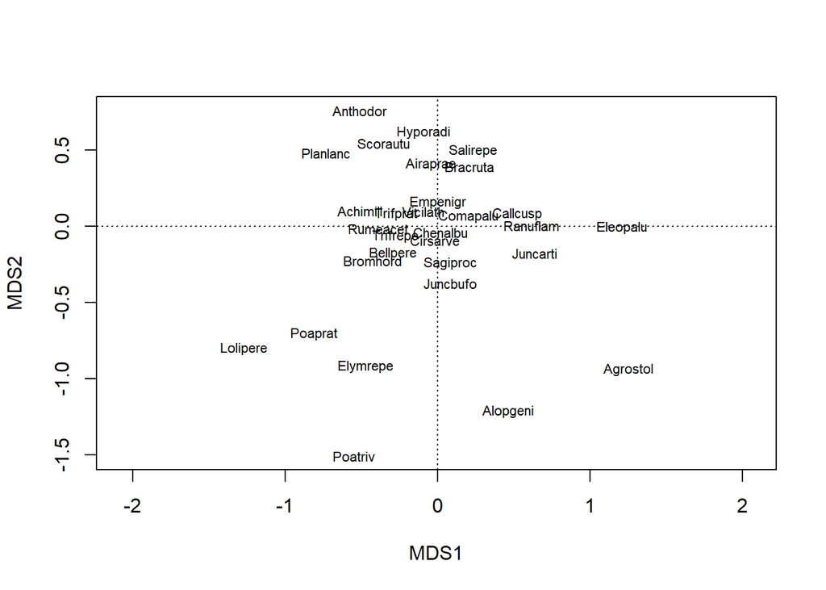

```r
#only show the species/response:
plot(pcoa.out_bray, scaling=1, display="species")
```

```r
#Summary of results - proportion of variance explained, species scores, PC values for each site.
summary(pcoa.out_bray)
```

```
##
## Call:
## capscale(formula = dune ~ 1, distance = "bray")
##
## Partitioning of squared Bray distance:
##               Inertia Proportion
## Total           4.594          1
## Unconstrained   4.594          1
##
## Eigenvalues, and their contribution to the squared Bray distance
##
## Importance of components:
##                         MDS1   MDS2   MDS3    MDS4    MDS5    MDS6    MDS7
## Eigenvalue            1.7163 1.0224 0.4615 0.38225 0.27913 0.23663 0.16912
## Proportion Explained  0.3736 0.2226 0.1005 0.08321 0.06076 0.05151 0.03681
## Cumulative Proportion 0.3736 0.5961 0.6966 0.77980 0.84057 0.89207 0.92889
##                          MDS8    MDS9   MDS10   MDS11    MDS12    MDS13
## Eigenvalue            0.09625 0.07449 0.06171 0.05494 0.019174 0.016119
## Proportion Explained  0.02095 0.01622 0.01343 0.01196 0.004174 0.003509
## Cumulative Proportion 0.94984 0.96605 0.97949 0.99145 0.995620 0.999129
##                           MDS14
## Eigenvalue            0.0040009
## Proportion Explained  0.0008709
## Cumulative Proportion 1.0000000
##
## Scaling 2 for species and site scores
## * Species are scaled proportional to eigenvalues
## * Sites are unscaled: weighted dispersion equal on all dimensions
## * General scaling constant of scores:  3.00629
##
##
## Species scores
##
##               MDS1      MDS2      MDS3     MDS4      MDS5      MDS6
## Achimill -0.320652  0.050785 -0.045297  0.21985  0.111932 -0.005217
## Agrostol  0.792011 -0.456459  0.081159  0.03248 -0.117220  0.014240
## Airaprae -0.028212  0.200637  0.085968  0.02860 -0.112276 -0.029322
## Alopgeni  0.292625 -0.589600  0.454199 -0.07724 -0.072491 -0.025047
## Anthodor -0.323418  0.371692  0.130578  0.23158  0.047438  0.100978
## Bellpere -0.185697 -0.084954 -0.023038 -0.02997  0.062929 -0.109871
```

[output cut: 34 more lines]

```
## 6  -0.58064  0.28010 -0.12455  0.08067  1.30909  0.98289
## 7  -0.71055 -0.05671  0.22347  0.17585  0.60184  0.85465
## 8   0.40677 -0.50573 -0.18837 -0.26789  0.02922 -0.01364
## 9   0.03999 -0.73336  0.55679 -0.26637 -0.27337  0.45933
## 10 -0.71422  0.16245 -0.34006  0.34694  0.71410 -0.61786
## 11 -0.46426  0.41960 -0.44870 -1.16090 -0.27186 -0.50454
## 12  0.44857 -0.37442  1.53975 -0.42119  0.32454  0.20611
## 13  0.41276 -0.63974  1.21236  0.57438 -0.30954 -0.57961
## 14  0.98699  0.25606 -0.62525  1.06297  0.99713 -1.34406
## 15  1.11920  0.34190 -0.48204 -0.08416  0.33357  0.31712
## 16  1.17312 -0.32968 -0.44952  0.24935 -0.45323  0.85663
## 17 -0.44708  1.47632  0.21535  1.55708 -1.08913  0.27338
## 18 -0.30611  0.71670 -0.40938 -1.45936  0.52338 -0.14760
## 19 -0.01238  1.39477  0.96179 -0.72748 -0.92154 -0.60413
## 20  1.16849  0.46836 -0.64341 -0.32499 -0.23180  0.47921
```

## Non-metric multidimensional scaling

Like PCA, CA, and PCoA, non-metric multidimensional scaling (NMDS) represents multi-dimensional response data in reduced dimensions (typically 2). Unlike PCA, CA, and PCoA, which preserve certain distances, NMDS uses rank orders (ie it preserves the order of data points), making it flexible for wide variety of data types. The program keeps moving the data points in the reduced dimensions until the stress (a representation of how well the representation represents the original data) is low (best <0.1, okay <0.2). The process starts with a matrix of distances (ie Bray-Curtis) and compares the rank-based ordination to those distances to compute the stress using regression.

The package is “vegan” and the function metaMDS().

For more info: https://jonlefcheck.net/2012/10/24/nmds-tutorial-in-r/

```r
#Run the NMDS


set.seed(2) #NMDS has some randomness, so set the seed to be consistent each time you run.

NMDS.out<-metaMDS(dune, # Our community-by-species matrix
                  distance = "bray", #compute Bray-Curtis distance matrix for use in NMDS
                     k=2, # The number of reduced dimensions
                  trymax=100) #maximum number of iterations tried
```

```
## *** Solution reached
```

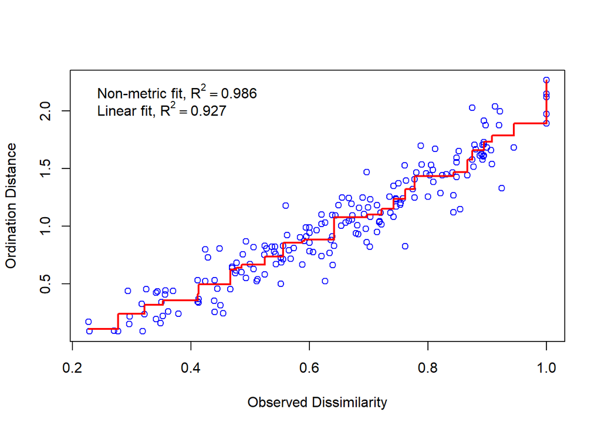

```r
#if it fails to converge, try increasing the number of iterations (trymax). If the stress is too high, maybe it cannot be accurately represented in two dimensions, so increase k.

#Examine Shepard (stress) plot - large scatter around the line indicates lots of stress (NMDS is a poor representation of the data)
stressplot(NMDS.out)
```

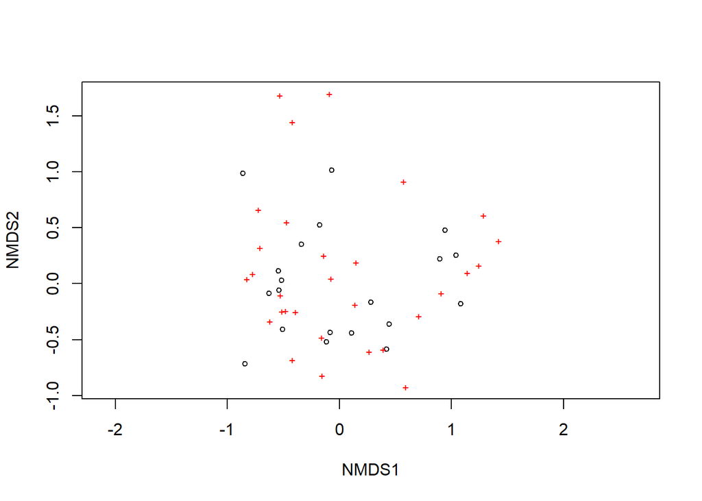

```r
#Examine plots
#can use plot: open circles are sites, red crosses are species:
plot(NMDS.out)
```

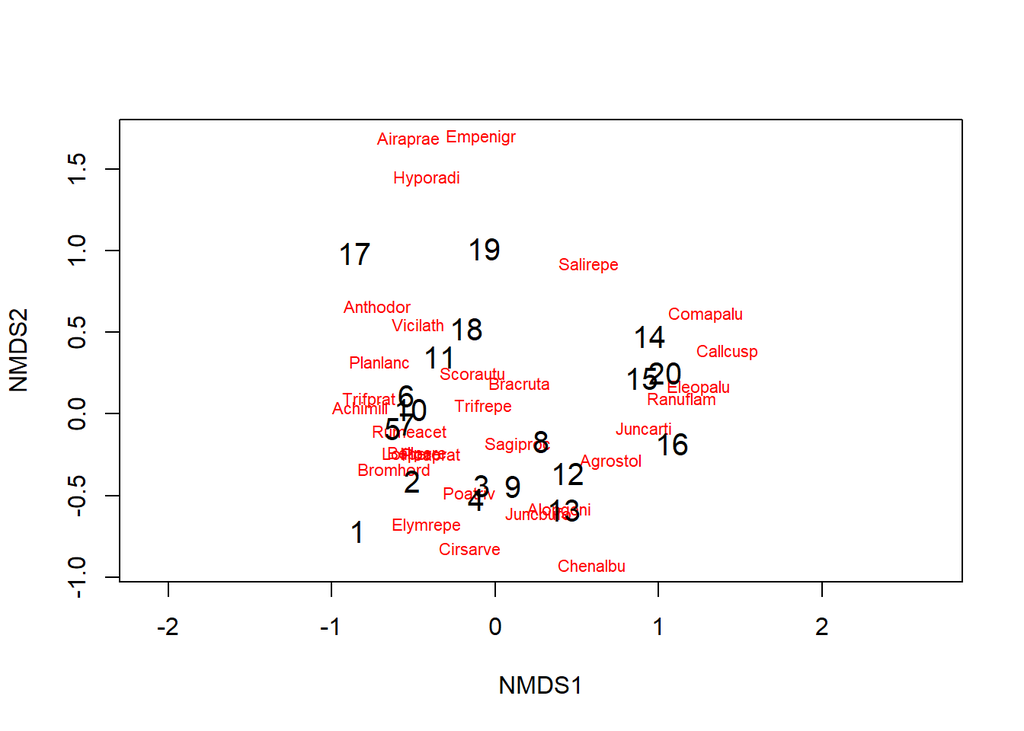

```r
#Plots with labels: first make empty plot with ordiplot() (type="n" specifies the plot is empty) then add the labels for species and sites using orditorp().
ordiplot(NMDS.out,type="n")
orditorp(NMDS.out,display="species",col="red",air=0.01)
orditorp(NMDS.out,display="sites",cex=1.25,air=0.01)
```

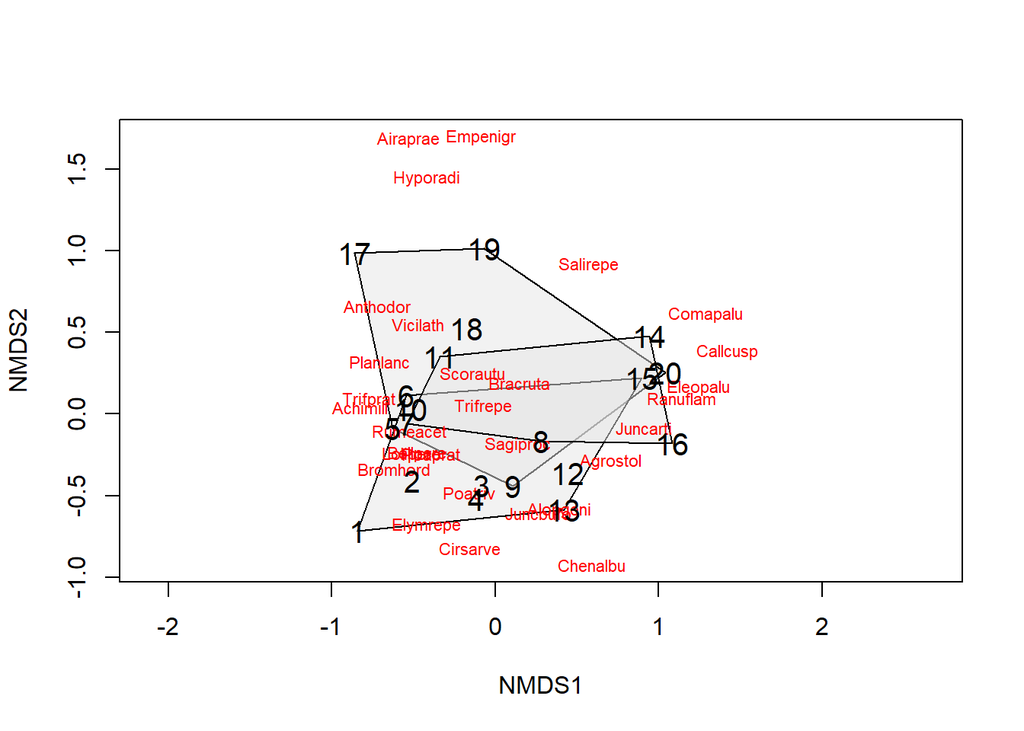

```r
#Is there clustering associated with a factor/treatment/categorical variable:
#example: visualizing effects of land use on ecological community composition:

#look at convex hulls containing all the points for each group:
ordiplot(NMDS.out,type="n")
ordihull(NMDS.out,groups=dune.env$Use,draw="polygon",col="grey90",label=F)
orditorp(NMDS.out,display="species",col="red",air=0.01)
orditorp(NMDS.out,display="sites",air=0.01,cex=1.25)
```

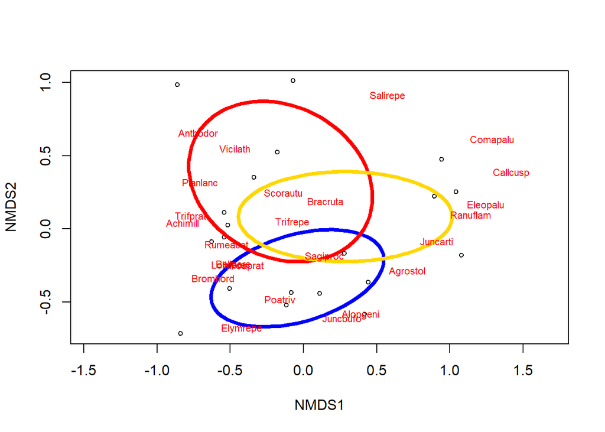

```r
#95% confidence ellipse based on a grouping/factor/treatment/categorical variable:

colors<-c("red","blue", "gold") #the colours for the ellipses. Should be as many as you have groups. Goes in same order as levels(dune.env$Use) - so red for Hayfield, blue for Hay pasture and gold for Pasture.
ordiplot(NMDS.out,display="sites") #special function for making pretty ordination plots (works for PCAs, etc. too)
#Plot convex hulls with colors baesd on treatment
for (i in unique (as.numeric(dune.env$Use))) { #for loop going through and making an ellipse for each level of your group (land use in this case)
  ordiellipse(NMDS.out, #function for the ellipse
  groups = as.numeric(dune.env$Use), show.group = i, col = colors[i],
    kind="sd", label = F, scaling=1, lwd=4)}
orditorp(NMDS.out,display="species",col="red",air=0.01) #puts species names on the plot
```

```r
#Summary of results - proportion of variance explained, species scores, PC values for each site.
summary(pcoa.out_bray)
```

```
##
## Call:
## capscale(formula = dune ~ 1, distance = "bray")
##
## Partitioning of squared Bray distance:
##               Inertia Proportion
## Total           4.594          1
## Unconstrained   4.594          1
##
## Eigenvalues, and their contribution to the squared Bray distance
##
## Importance of components:
##                         MDS1   MDS2   MDS3    MDS4    MDS5    MDS6    MDS7
## Eigenvalue            1.7163 1.0224 0.4615 0.38225 0.27913 0.23663 0.16912
## Proportion Explained  0.3736 0.2226 0.1005 0.08321 0.06076 0.05151 0.03681
## Cumulative Proportion 0.3736 0.5961 0.6966 0.77980 0.84057 0.89207 0.92889
##                          MDS8    MDS9   MDS10   MDS11    MDS12    MDS13
## Eigenvalue            0.09625 0.07449 0.06171 0.05494 0.019174 0.016119
## Proportion Explained  0.02095 0.01622 0.01343 0.01196 0.004174 0.003509
## Cumulative Proportion 0.94984 0.96605 0.97949 0.99145 0.995620 0.999129
##                           MDS14
## Eigenvalue            0.0040009
## Proportion Explained  0.0008709
## Cumulative Proportion 1.0000000
##
## Scaling 2 for species and site scores
## * Species are scaled proportional to eigenvalues
## * Sites are unscaled: weighted dispersion equal on all dimensions
## * General scaling constant of scores:  3.00629
##
##
## Species scores
##
##               MDS1      MDS2      MDS3     MDS4      MDS5      MDS6
## Achimill -0.320652  0.050785 -0.045297  0.21985  0.111932 -0.005217
## Agrostol  0.792011 -0.456459  0.081159  0.03248 -0.117220  0.014240
## Airaprae -0.028212  0.200637  0.085968  0.02860 -0.112276 -0.029322
## Alopgeni  0.292625 -0.589600  0.454199 -0.07724 -0.072491 -0.025047
## Anthodor -0.323418  0.371692  0.130578  0.23158  0.047438  0.100978
## Bellpere -0.185697 -0.084954 -0.023038 -0.02997  0.062929 -0.109871
```

[output cut: 34 more lines]

```
## 6  -0.58064  0.28010 -0.12455  0.08067  1.30909  0.98289
## 7  -0.71055 -0.05671  0.22347  0.17585  0.60184  0.85465
## 8   0.40677 -0.50573 -0.18837 -0.26789  0.02922 -0.01364
## 9   0.03999 -0.73336  0.55679 -0.26637 -0.27337  0.45933
## 10 -0.71422  0.16245 -0.34006  0.34694  0.71410 -0.61786
## 11 -0.46426  0.41960 -0.44870 -1.16090 -0.27186 -0.50454
## 12  0.44857 -0.37442  1.53975 -0.42119  0.32454  0.20611
## 13  0.41276 -0.63974  1.21236  0.57438 -0.30954 -0.57961
## 14  0.98699  0.25606 -0.62525  1.06297  0.99713 -1.34406
## 15  1.11920  0.34190 -0.48204 -0.08416  0.33357  0.31712
## 16  1.17312 -0.32968 -0.44952  0.24935 -0.45323  0.85663
## 17 -0.44708  1.47632  0.21535  1.55708 -1.08913  0.27338
## 18 -0.30611  0.71670 -0.40938 -1.45936  0.52338 -0.14760
## 19 -0.01238  1.39477  0.96179 -0.72748 -0.92154 -0.60413
## 20  1.16849  0.46836 -0.64341 -0.32499 -0.23180  0.47921
```

## Canonical analyses - RDA, CCA, db-RDA

Canonical or constrained ordinations show variation explained by explanatory variables. Each canonical axis is a linear combination (regression model) of all explanatory variabes. Unconstrained axes are also computed to represent remaining residual variation unaccounted for by explanatory variables.

Canonical analysis examines relationship between a response matrix and exlanatory matrix, using both ordination techniques (ie PCA) and linear regression.

Use the same functions in vegan as for unconstrainted ordination above, but include explanatory variables in place of the “~1” ie CommunityData~EnvData

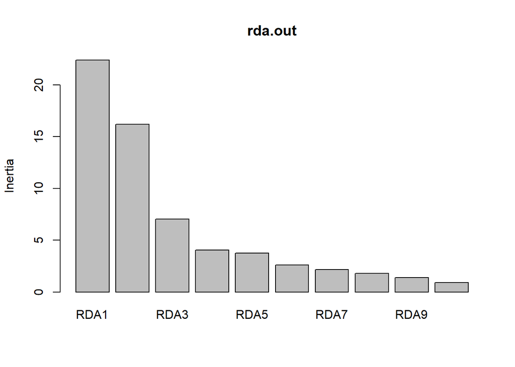

```r
#Run redundancy (RDA) - constrained PCA
rda.out<-rda(dune~Use+Management+A1+Moisture+Manure, data=dune.env) #Run the RDA on the dune community using explanatory variabes in the dune.env data set.

#Run constrained correspondance analysis (CCA)
cca.out<-cca(dune~Use+Management+A1+Moisture+Manure, data=dune.env) #Run the CCA on the dune community using explanatory variabes in the dune.env data set.

#Run distanced-based redundancy analysis - constrained PCoA
dbRDA.out<-capscale(dune~Use+Management+A1+Moisture+Manure, distance="bray", data=dune.env) #Run the CCA on the dune community using explanatory variabes in the dune.env data set.

#Code below is for all constrained analyses, although example is for RDA:

#Scree plots (percentage of variation explained by each principal component axis):
screeplot(rda.out) #drop-off after second canonical axis, suggesting only first two axes need examining
```

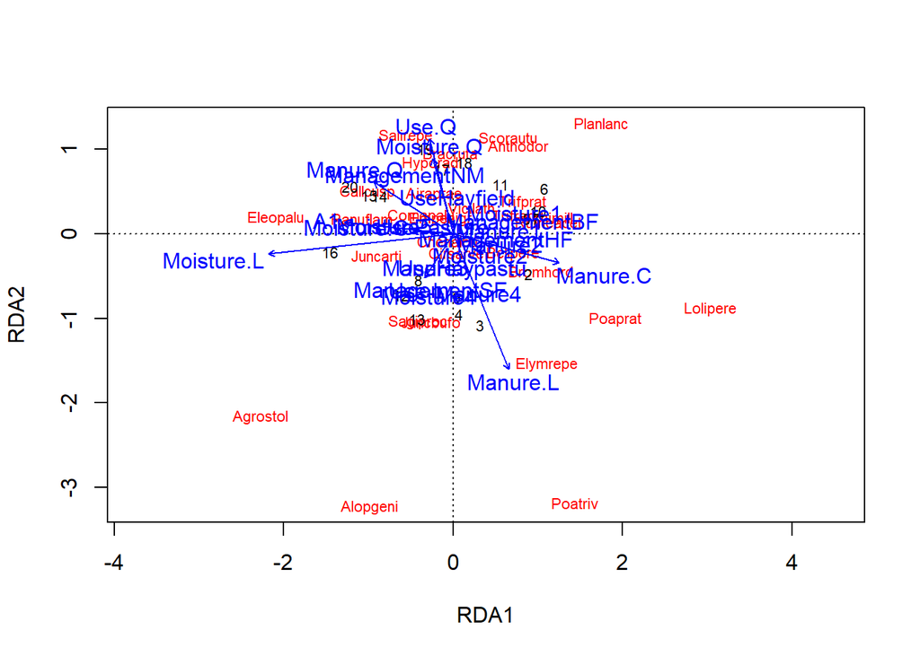

```r
#Examine biplots - NOTE use plot() here:
#scaling=1 (for individuals/sites/samples):
plot(rda.out, scaling=1)
```

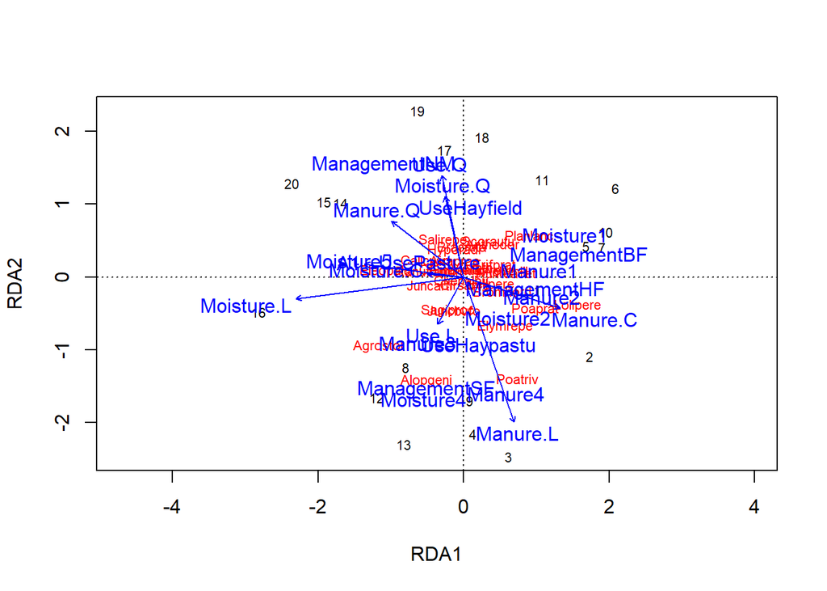

```r
#scaling=2 (for species/response):
plot(rda.out, scaling=2)
```

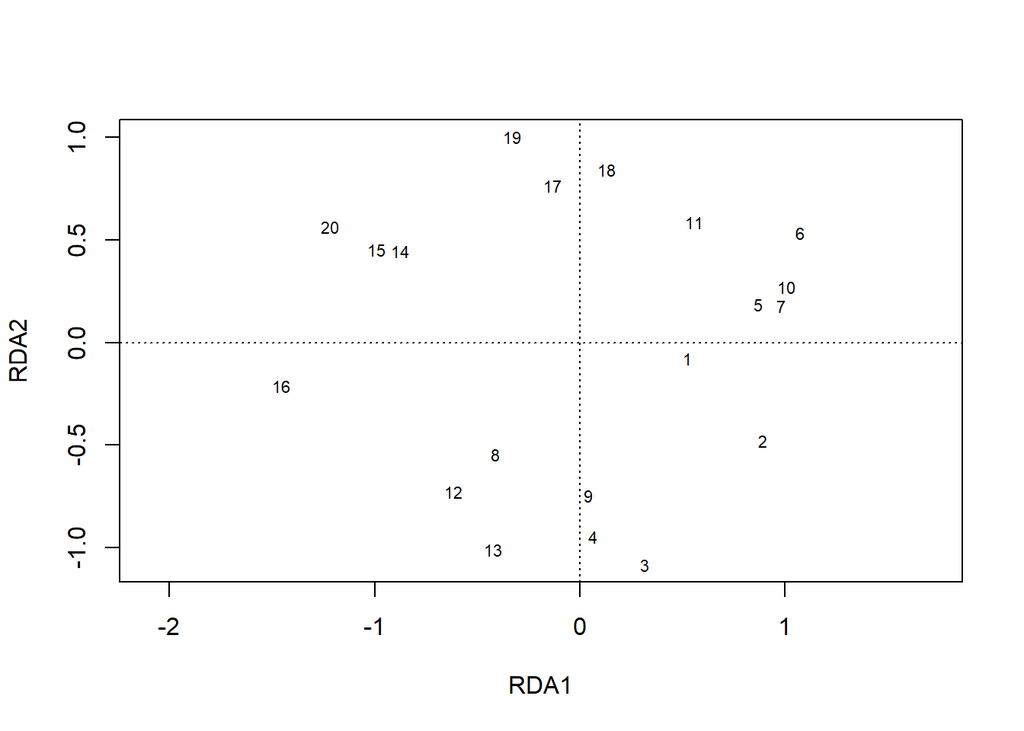

```r
#only show the individuals/sites/samples:
plot(rda.out, scaling=1, display="sites")
```

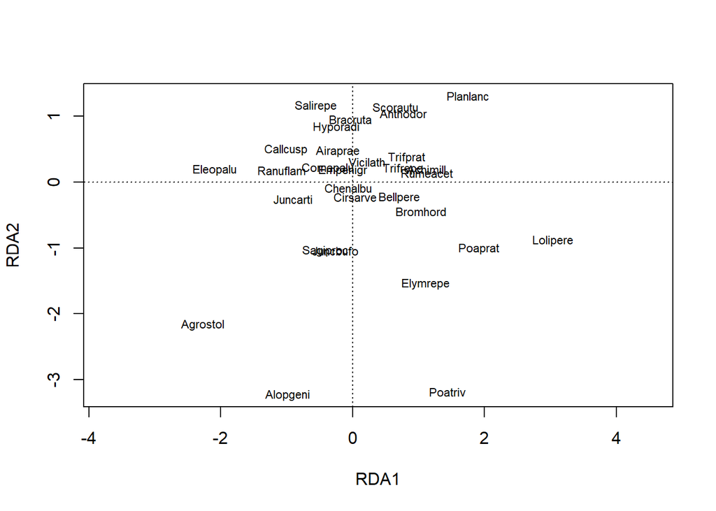

```r
#only show the species/response:
plot(rda.out, scaling=1, display="species")
```

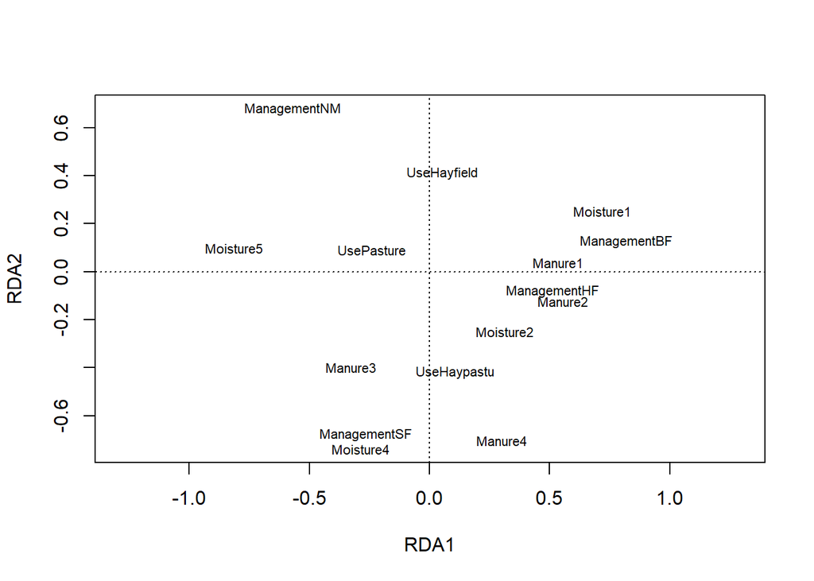

```r
#only show the constraints/explanatory variables:
plot(rda.out, scaling=1, display="cn")
```

```r
#Summary of results - proportion of variance explained, species scores, PC values for each site.
summary(rda.out)
```

```
##
## Call:
## rda(formula = dune ~ Use + Management + A1 + Moisture + Manure,      data = dune.env)
##
## Partitioning of variance:
##               Inertia Proportion
## Total           84.12     1.0000
## Constrained     63.21     0.7513
## Unconstrained   20.92     0.2487
##
## Eigenvalues, and their contribution to the variance
##
## Importance of components:
##                          RDA1    RDA2    RDA3   RDA4   RDA5    RDA6    RDA7
## Eigenvalue            22.3955 16.2076 7.03891 4.0380 3.7602 2.60874 2.16693
## Proportion Explained   0.2662  0.1927 0.08367 0.0480 0.0447 0.03101 0.02576
## Cumulative Proportion  0.2662  0.4589 0.54256 0.5906 0.6353 0.66627 0.69203
##                          RDA8    RDA9   RDA10    RDA11    RDA12     PC1     PC2
## Eigenvalue            1.80327 1.40421 0.91739 0.581545 0.283927 6.62687 4.30914
## Proportion Explained  0.02144 0.01669 0.01091 0.006913 0.003375 0.07878 0.05122
## Cumulative Proportion 0.71346 0.73015 0.74106 0.747973 0.751348 0.83012 0.88135
##                           PC3     PC4     PC5    PC6      PC7
## Eigenvalue            3.54913 2.54648 2.34027 0.9335 0.612096
## Proportion Explained  0.04219 0.03027 0.02782 0.0111 0.007276
## Cumulative Proportion 0.92354 0.95381 0.98163 0.9927 1.000000
##
## Accumulated constrained eigenvalues
## Importance of components:
##                          RDA1    RDA2   RDA3    RDA4    RDA5    RDA6    RDA7
## Eigenvalue            22.3955 16.2076 7.0389 4.03795 3.76017 2.60874 2.16693
## Proportion Explained   0.3543  0.2564 0.1114 0.06389 0.05949 0.04127 0.03428
## Cumulative Proportion  0.3543  0.6107 0.7221 0.78600 0.84549 0.88676 0.92105
##                          RDA8    RDA9   RDA10    RDA11    RDA12
## Eigenvalue            1.80327 1.40421 0.91739 0.581545 0.283927
## Proportion Explained  0.02853 0.02222 0.01451 0.009201 0.004492
## Cumulative Proportion 0.94958 0.97179 0.98631 0.995508 1.000000
##
## Scaling 2 for species and site scores
## * Species are scaled proportional to eigenvalues
## * Sites are unscaled: weighted dispersion equal on all dimensions
```

[output cut: 108 more lines]

```
## UseHayfield   0.1009  0.93851 -0.196574 -1.23634 -0.3134  0.44957
## UseHaypastu   0.2031 -0.95047  0.007901 -0.04993  0.1730 -0.07517
## UsePasture   -0.4661  0.20684  0.262562  1.81077  0.1621 -0.50914
## ManagementBF  1.5865  0.29136  1.195323  0.30521 -1.4873 -1.90809
## ManagementHF  0.9900 -0.18143 -1.310046  0.53268  0.5222  0.47038
## ManagementNM -1.1045  1.54698  0.307294 -0.53680 -0.1390  0.22008
## ManagementSF -0.5138 -1.54147  0.186749 -0.05971  0.4474  0.34198
## Moisture1     1.3911  0.57720 -0.079190  0.20780  0.3709  0.01816
## Moisture2     0.6061 -0.56605  0.813569 -0.31856 -0.7359  0.47388
## Moisture4    -0.5562 -1.67959 -1.393063 -1.95824  1.5257 -1.87223
## Moisture5    -1.5785  0.22614  0.012311  0.53373 -0.3863  0.24598
## Manure1       1.0377  0.08608  0.616318 -0.06403  0.2982 -1.54300
## Manure2       1.0750 -0.27727 -1.654376 -0.28962 -0.4585 -0.47659
## Manure3      -0.6339 -0.90628 -0.618849  1.20845 -0.3538  0.21135
## Manure4       0.5832 -1.60196  1.800060 -0.08747  1.0629  1.45649
```

# If else statements

Resource: https://www.datamentor.io/r-programming/if-else-statement/

If else statements are used to run code based on conditions. A Boolean statement is supplied (something that can be evaluated as TRUE or FALSE), and if TRUE, the code following the if statement is run. An optional else statement runs if the Boolean is FALSE.

There are two ways to run if else statements.

Simple if else statements can be run using the ifelse() function. The ifelse function takes three arguments: the first is the Boolean (TRUE/FALSE) statement to evaluate, the second is what to do if it returns TRUE, the third what to do if it returns FALSE.

ifelse() is often used on vectors to run functions to parts of the vector, but a different function (or nothing) on the rest.

Example: if the mammal is big (greater than 100 kgs), log its brain mass, otherwise take the square root of brain mass, and save results to a new column in the data frame.

```r
data(mammals)

mammals$log_sqrt <- ifelse(mammals$body>100, log(mammals$brain), sqrt(mammals$brain))
```

You can also construct if else statements for more complicated computations like this:

if (test that returns TRUE/FALSE) { code/function to run }

You can specify what to do when FALSE using else:

if (test that returns TRUE/FALSE) { code/function to run when TRUE } else { code/function to run when FALSE }

You can chain multiple if else statements:

if (test that returns TRUE/FALSE) {

code/function to run

} else {

```
if (second condition) {

code/function to run

} else {

  code/function to run

}
```

}

```r
size <- 855
type <- "bird"

if (size > 1000) {
  print("That's a big animal!")
}

if (size < 1000) {
  print("That's a small animal!")
}
```

```
## [1] "That's a small animal!"
```

```r
if (size >= 1000 & type == "bird") {
  print("That's a big bird")
} else {
  if (size >= 1000 & type == "mammal") {
    print("that's a big mammal")
  } else {
    if (size < 1000 & type!="bird") {
      print("That's a small animal, can't tell what, but I know it's not a bird")
    } else {
      print("Wow that's a small bird!")
    }
  }
}
```

```
## [1] "Wow that's a small bird!"
```

```r
#Try changing size and type and see what happens
```

# Make your own function in R

If you find yourself repeating (copying and pasting) code many times with only minor tweaks, it might be useful to make that code a function - then you only need to repeat the function name, with arguments representing those minor tweaks or the data used.

You give the function a name and assign (using <- or =) the actual function to that name.

Here’s the function for calculating standard error

```r
se_func <- function(x) { #put the arguments for your function in the (). This function takes a vector "x"
  return(sd(x)/sqrt(length(x))) #use return to specify what the function should output. Using return is not always necessary, if the function is simple
} #enclose the body of your function in brackets
```

This function takes a data frame and another function as argument and calculates that function over each column of the data frame. It also includes an example of a for loop (see For loops section below).

```r
col_summary <- function(df, fun) {
  result <- vector("numeric", length(df)) #initialize an empty vector to store results of for loop
  for (i in seq_along(df)) {
    result[i] <- fun(df[[i]])
  }
  return(result)
}

#use the function to calculate the mean, median of every column of the dune data set
#NOTE this re-creates functionality from summary() and apply()

col_summary(dune, mean)
```

```
##  [1] 0.80 2.40 0.25 1.80 1.05 0.65 0.75 0.05 0.10 0.20 1.25 1.30 0.10 0.45 0.90
## [16] 0.65 2.90 1.30 2.40 3.15 0.70 0.90 1.00 0.55 2.70 0.45 2.35 0.20 2.45 0.50
```

```r
col_summary(dune, median)
```

```
##  [1] 0.0 1.5 0.0 0.0 0.0 0.0 0.0 0.0 0.0 0.0 0.0 0.0 0.0 0.0 0.0 0.0 2.0 0.0 3.0
## [20] 4.0 0.0 0.0 0.0 0.0 2.0 0.0 2.0 0.0 2.0 0.0
```

# If else statements in functions

If else statements can be used in functions. A TRUE/FALSE condition can be coded as an argument if you have different variations to run for different conditions.

Example: calculate SE for continuous numbers that can vary from negative infinity to infinity versus SE for proportions that vary between 0 and 1. Uses a nested if/else statement – one statement within another

```r
se_func_complete <- function(x, prop=FALSE) {

  if (prop==TRUE) {

    #check if numbers are between 0 and 1:

    if (min(x) < 0 | max(x) > 1) {
      print("Error: Data should be bounded by 0 and 1")
    }
    else {
      return(sqrt(x*(1-x)/length(x))) #SE of proportion data (bounded by 0 and 1)
    }

  } else {

      return(sd(x)/sqrt(length(x))) # SE of count/continuous data

  }

}

se_func_complete(c(2,3.3,4.5,99.2), prop=FALSE)
```

```
## [1] 23.98876
```

```r
se_func_complete(c(0.5,0.77,0.6,0.2,0.99), prop=TRUE)
```

```
## [1] 0.22360680 0.18820202 0.21908902 0.17888544 0.04449719
```

```r
se_func_complete(c(2,3.3,4.5,99.2), prop=TRUE)
```

```
## [1] "Error: Data should be bounded by 0 and 1"
```

# Repetitive tasks in R

Check out this resource: https://r4ds.had.co.nz/iteration.html

If you need to run some function or code repeatedly, there are a few options to save you time and coding effort.

1. Make use of vectorization in R.

R is vectorized, meaning running a function on a vector applies that function to each element of that vector. Remember, columns of data frames are vectors! You can make use of your own functions this way too!

2. Use the apply family.

The apply family of functions applies a function to every row, column, or element in a list. You can use these with your own custom functions. You can make use of your own functions this way too!

3. Use aggregate
4. For loops

For example:

```r
mammals$brain+1
```

```
##  [1]   45.50   16.50    9.10  424.00  120.50  116.00   99.20    6.50   59.00
## [10]    7.40    5.00    6.70    7.60    1.14    2.00   11.80   13.30    7.30
## [19] 4604.00    1.30  420.00  656.00    4.50  116.00   26.60    6.00   18.50
## [28]  681.00  407.00  326.00   13.30 1321.00 5713.00    4.90  180.00   57.00
## [37]   18.00    2.00    1.40    1.25   13.50  491.00   13.10  176.00  158.00
## [46]  441.00  180.50    3.40   82.00   22.00   40.20    2.90    2.20    4.00
## [55]    1.33  181.00   26.00  170.00    3.60   12.40    3.50   51.40
```

Adds 1 to every element of mammals$brain.

Another example: Calculate the Shannon diversity for every row of the dune community data set:

```r
library(vegan)
data(dune)
data(dune.env)

diversity(dune, index="shannon")
```

```
##        1        2        3        4        5        6        7        8
## 1.440482 2.252516 2.193749 2.426779 2.544421 2.345946 2.471733 2.434898
##        9       10       11       12       13       14       15       16
## 2.493568 2.398613 2.106065 2.114495 2.099638 1.863680 1.979309 1.959795
##       17       18       19       20
## 1.876274 2.079387 2.134024 2.048270
```

## The apply family

The “apply” family of functions applies a function to every element of a row or column (apply) or for every element in a list (lapply, sapply). There are other functions in the family (vapply, tapply) but these are the ones you are most likely to use. NOTE: aggregate() (see below) is a good function to use instead of tapply().

```r
#Apply a function to every column of a data frame:
apply(dune,2,function(x) sd(x)/sqrt(length(x))) #find the standard error of each species - 2 means apply to each column
```

```
##  Achimill  Agrostol  Airaprae  Alopgeni  Anthodor  Bellpere  Bromhord  Chenalbu
## 0.2772041 0.6000000 0.1758438 0.5875910 0.3802700 0.2325488 0.3151858 0.0500000
##  Cirsarve  Comapalu  Eleopalu  Elymrepe  Empenigr  Hyporadi  Juncarti  Juncbufo
## 0.1000000 0.1376494 0.5275315 0.4650976 0.1000000 0.2760149 0.3620119 0.3101358
##  Lolipere  Planlanc   Poaprat   Poatriv  Ranuflam  Rumeacet  Sagiproc  Salirepe
## 0.6320393 0.4358899 0.4129483 0.6294317 0.2625783 0.4032761 0.3479262 0.3118282
##  Scorautu  Trifprat  Trifrepe  Vicilath  Bracruta  Callcusp
## 0.3486817 0.2760149 0.4247290 0.1169795 0.4259664 0.2762531
```

```r
#Apply a function to every row of a data frame:
apply(dune,1,function(x) sd(x)/sqrt(length(x))) #find the standard error of species counts at each site - 1 means apply to each row.
```

```
##         1         2         3         4         5         6         7         8
## 0.2940013 0.3942110 0.4021018 0.3917247 0.3345381 0.4196331 0.3298670 0.3263639
##         9        10        11        12        13        14        15        16
## 0.3342516 0.3672931 0.3421814 0.3716485 0.3785939 0.2971125 0.2655869 0.3934814
##        17        18        19        20
## 0.1841414 0.2969190 0.3197820 0.3303893
```

```r
#Apply a function to every element of a list
#lapply will return a list
#sapply will return a "prettier" array, matrix, or data frame to manipulate

#first I'm going to make a list using the lapply function
#remember data frames are lists of columns, so can also use lapply to apply function to every column and return a list:
#I want to run a regression of abundance against A1 (a measure of soil thickness at the A1 horizon) for each species:
regressions.out<-lapply(dune, function(x) lm(x~dune.env$A1)) #remember a data frame is a list of columns

#Now I have a list of the regressions, one for each species. Remember - use $ or [[]] to retrieve elements of a list
regressions.out[[1]] #gives me first regression in the list
```

```
##
## Call:
## lm(formula = x ~ dune.env$A1)
##
## Coefficients:
## (Intercept)  dune.env$A1
##      1.6761      -0.1806
```

```r
regressions.out$Anthodor #gives me the regression for Anthodor
```

```
##
## Call:
## lm(formula = x ~ dune.env$A1)
##
## Coefficients:
## (Intercept)  dune.env$A1
##      1.8106      -0.1568
```

```r
#I can use this list of regressions with lapply or sapply to retrieve just the coefficients for each species
intercept_slopes<-lapply(regressions.out, coef) #get intercept and slope as a list accessible with $
intercept_slopes_df<-sapply(regressions.out, coef) #get intercept and slope as a matrix/array
#coef gets the coefficients from a regression object


#NOTE: use colSums(), rowSums(), colMeans(), or rowMeans() for sums and means for columns and rows.
colSums(dune)
```

```
## Achimill Agrostol Airaprae Alopgeni Anthodor Bellpere Bromhord Chenalbu
##       16       48        5       36       21       13       15        1
## Cirsarve Comapalu Eleopalu Elymrepe Empenigr Hyporadi Juncarti Juncbufo
##        2        4       25       26        2        9       18       13
## Lolipere Planlanc  Poaprat  Poatriv Ranuflam Rumeacet Sagiproc Salirepe
##       58       26       48       63       14       18       20       11
## Scorautu Trifprat Trifrepe Vicilath Bracruta Callcusp
##       54        9       47        4       49       10
```

```r
rowMeans(dune)
```

```
##         1         2         3         4         5         6         7         8
## 0.6000000 1.4000000 1.3333333 1.5000000 1.4333333 1.6000000 1.3333333 1.3333333
##         9        10        11        12        13        14        15        16
## 1.4000000 1.4333333 1.0666667 1.1666667 1.1000000 0.8000000 0.7666667 1.1000000
##        17        18        19        20
## 0.5000000 0.9000000 1.0333333 1.0333333
```

## Aggregate

Use aggregate to apply a function over groups/levels of a factor (eg mean weight in each treatment).

```r
#Find mean abundance of Anthodor by pasture type
aggregate(dune$Anthodor, by=list(dune.env$Use), mean)
```

```
##    Group.1        x
## 1 Hayfield 2.285714
## 2 Haypastu 0.375000
## 3  Pasture 0.400000
```

```r
#if the response and factor are in the same data frame:
data.example<-data.frame(Anthodor=dune$Anthodor, Use=dune.env$Use)
aggregate(Anthodor~Use, data=data.example, mean) #mean
```

```
##        Use Anthodor
## 1 Hayfield 2.285714
## 2 Haypastu 0.375000
## 3  Pasture 0.400000
```

```r
aggregate(Anthodor~Use, data=data.example, min) #minimum
```

```
##        Use Anthodor
## 1 Hayfield        0
## 2 Haypastu        0
## 3  Pasture        0
```

## For loops

The simplest way to achieve a repetitive task is to have R run the code for you in a loop. However, for loops are not very efficient, and most things can be achieved using R’s vectorization, the apply family, and making your own functions.

A for loop designates a variable that changes each time the looped code is run.

Here’s a for loop basic example:

Take a list of numbers and find their square:

```r
#make the data
numberList <- c(22, 33,12,13,5,7,9)

#Initialize an empty vector to store the results of your for loop
squaredNumbers <- vector(mode = "numeric", length = length(numberList))

#as the for loop runs, "i" in the code below will change, one after the other, to every element specified after "in". In this case, we use seq_along to generate the list of indices (ie positions) for numberList (the first element in numberList had index 1, the second has index 2, etc.). We then use the [] operator to extract the element at that position. So in the code below, the as the "i" is changed from 1 to 2 to 3, etc., in extract in turn the first, then the second, then the third, etc. element of numberList. Then we square that element and put it in the ith position (ie first, then second, then third position) of squaredNumbers, where we are storing the results. The point is: "i" in the code of the for loop changes to each value specified after "in", one after the other.

for (i in seq_along(numberList)) {
  squaredNumbers[i] <- numberList[i]^2
}

squaredNumbers
```

```
## [1]  484 1089  144  169   25   49   81
```

NOTE this could be better achieved with simple vectorization:

```r
squaredNumbersVectorization <- numberList^2

squaredNumbers
```

```
## [1]  484 1089  144  169   25   49   81
```

```r
squaredNumbersVectorization
```

```
## [1]  484 1089  144  169   25   49   81
```

Here’s another example that prints out various statements. I used two for loops, one nested in the other:

NOTE for the second for loop, I use “j” rather than “i” so they do not get confused. You can pick any letter, but the standard is “i” for the outer loop, then “j” for the inner loop. I also make use of an if else statement.

```r
nouns <- c("roses", "violets", "daisies", "sugar cubes", "onions", "oranges")

colours <- c("red", "blue", "white")

tastes <- c("sweet", "gross", "juicy")

for (i in seq_along(nouns)) {
  if (i <= 3) {
    for (j in seq_along(colours)) {
      print(paste(nouns[i], "are", colours[j]))
    }
  } else {
    for (j in seq_along(tastes)) {
      print(paste(nouns[i], "are", tastes[j]))
      ifelse((tastes[j]=="gross" & nouns[i]=="sugar cubes") | (tastes[j]=="sweet" & nouns[i]=="onions"), print("That's a lie"), print("That's so true!"))  #change if it is sugar cubes are gross or if onions are sweet
    }

  }
}
```

```
## [1] "roses are red"
## [1] "roses are blue"
## [1] "roses are white"
## [1] "violets are red"
## [1] "violets are blue"
## [1] "violets are white"
## [1] "daisies are red"
## [1] "daisies are blue"
## [1] "daisies are white"
## [1] "sugar cubes are sweet"
## [1] "That's so true!"
## [1] "sugar cubes are gross"
## [1] "That's a lie"
## [1] "sugar cubes are juicy"
## [1] "That's so true!"
## [1] "onions are sweet"
## [1] "That's a lie"
## [1] "onions are gross"
## [1] "That's so true!"
## [1] "onions are juicy"
## [1] "That's so true!"
## [1] "oranges are sweet"
## [1] "That's so true!"
## [1] "oranges are gross"
## [1] "That's so true!"
## [1] "oranges are juicy"
## [1] "That's so true!"
```

NOTE something similar can be achieved with a function:

```r
printNouns <- function(noun, adjective, truth=TRUE) {
  print(paste(noun, adjective, "Stop!", ifelse(truth, "That's so true!", "That's a lie!")))
}

#Notice each "noun" is getting its corresponding adjective in "c(colours, taste)" BUT every colour or taste is NOT being applied to every noun - the first noun gets the first colour, etc. I enough TRUE/FALSE statements for every noun. If you want every combination, the for loop is a good tool.
printNouns(nouns, c(colours, tastes), truth=c(FALSE, FALSE, TRUE, FALSE, FALSE, TRUE))
```

```
## [1] "roses red Stop! That's a lie!"
## [2] "violets blue Stop! That's a lie!"
## [3] "daisies white Stop! That's so true!"
## [4] "sugar cubes sweet Stop! That's a lie!"
## [5] "onions gross Stop! That's a lie!"
## [6] "oranges juicy Stop! That's so true!"
```

```r
#can also use just one FALSE. The number of TRUE/FALSE's should be 1 or the same number as the length of nouns.
printNouns(nouns, c(colours, tastes), truth=FALSE)
```

```
## [1] "roses red Stop! That's a lie!"
## [2] "violets blue Stop! That's a lie!"
## [3] "daisies white Stop! That's a lie!"
## [4] "sugar cubes sweet Stop! That's a lie!"
## [5] "onions gross Stop! That's a lie!"
## [6] "oranges juicy Stop! That's a lie!"
```

For loop to make multiple plots:

Sometimes you want to make the same plot multiple times for different data.

```r
#This will produce a plot for each dune species, and give a y-axis based on the name of that species

dim(dune)
```

```
## [1] 20 30
```

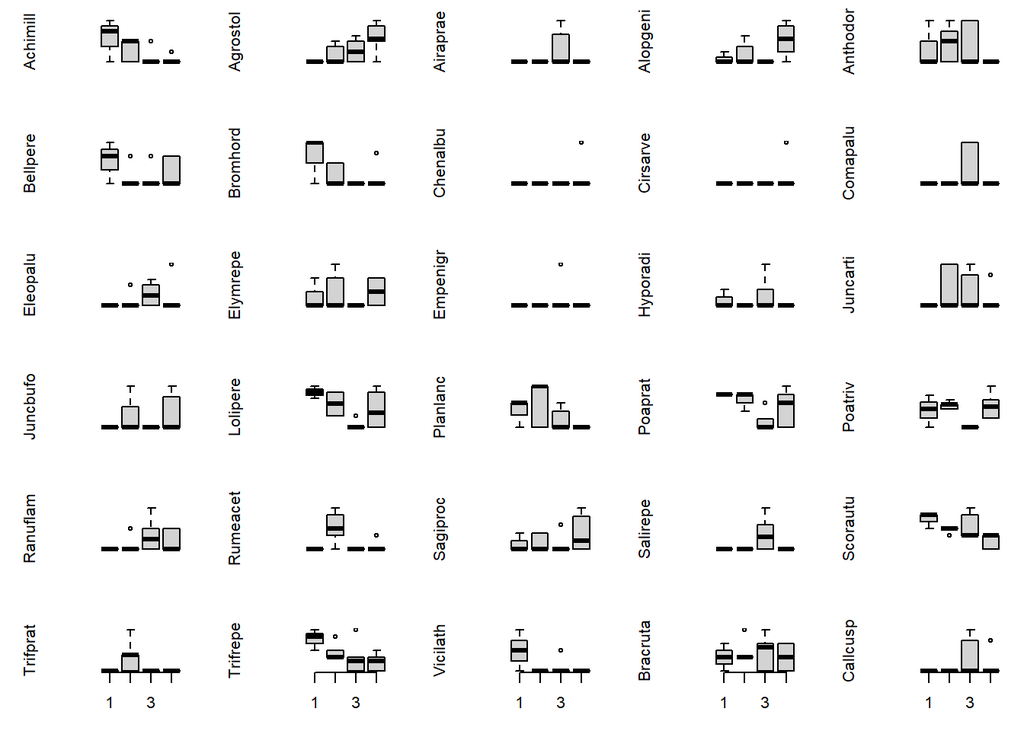

```r
par(mfrow=c(6,5), mar=c(3,5,1,1)) #set up plotting window - six rows, five columns for all thirty species

#I generate a sequence from 1 to the number of columns in dune (ie number of species in dune; there is one species per column)
#I use if else statements to ensure that the x-axis is drawn only on the bottom plots - the last five plots.
for (i in 1:ncol(dune)) {
    plot(dune[,i]~dune.env$Management, ylab=names(dune)[i], xlab="Management level", axes=F)

    if (i > 25) {
      axis(1) # add x-axis
    }

}
```

NOTE: this can be better achieved by making your own function:

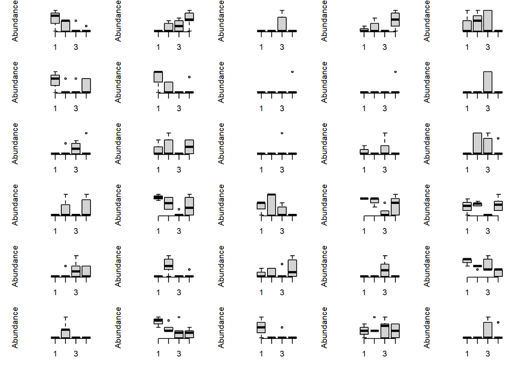

```
##      Achimill Agrostol Airaprae Alopgeni Anthodor Bellpere Bromhord Chenalbu
## [1,]        1        1        1        1        1        1        1        1
## [2,]        2        2        2        2        2        2        2        2
## [3,]        3        3        3        3        3        3        3        3
## [4,]        4        4        4        4        4        4        4        4
##      Cirsarve Comapalu Eleopalu Elymrepe Empenigr Hyporadi Juncarti Juncbufo
## [1,]        1        1        1        1        1        1        1        1
## [2,]        2        2        2        2        2        2        2        2
## [3,]        3        3        3        3        3        3        3        3
## [4,]        4        4        4        4        4        4        4        4
##      Lolipere Planlanc Poaprat Poatriv Ranuflam Rumeacet Sagiproc Salirepe
## [1,]        1        1       1       1        1        1        1        1
## [2,]        2        2       2       2        2        2        2        2
## [3,]        3        3       3       3        3        3        3        3
## [4,]        4        4       4       4        4        4        4        4
##      Scorautu Trifprat Trifrepe Vicilath Bracruta Callcusp
## [1,]        1        1        1        1        1        1
## [2,]        2        2        2        2        2        2
## [3,]        3        3        3        3        3        3
## [4,]        4        4        4        4        4        4
```

```r
#This will make a function to make a box plot of a variable against Management

plotDune <- function(x, x_axis=FALSE) {
  plot(x~dune.env$Management, ylab="Abundance", xlab="Management level", axes=F)
   if (x_axis) {
      axis(1) # add x-axis
    }
}


#apply the function to every column:

par(mfrow=c(6,5), mar=c(3,5,1,1)) #set up plotting window - six rows, five columns for all thirty species

apply(dune, 2, plotDune, x_axis=TRUE)
```

For loop to add lines or points to a plot:

Example: shark abundance relative to depth at sites around two marine protected areas in South Africa.

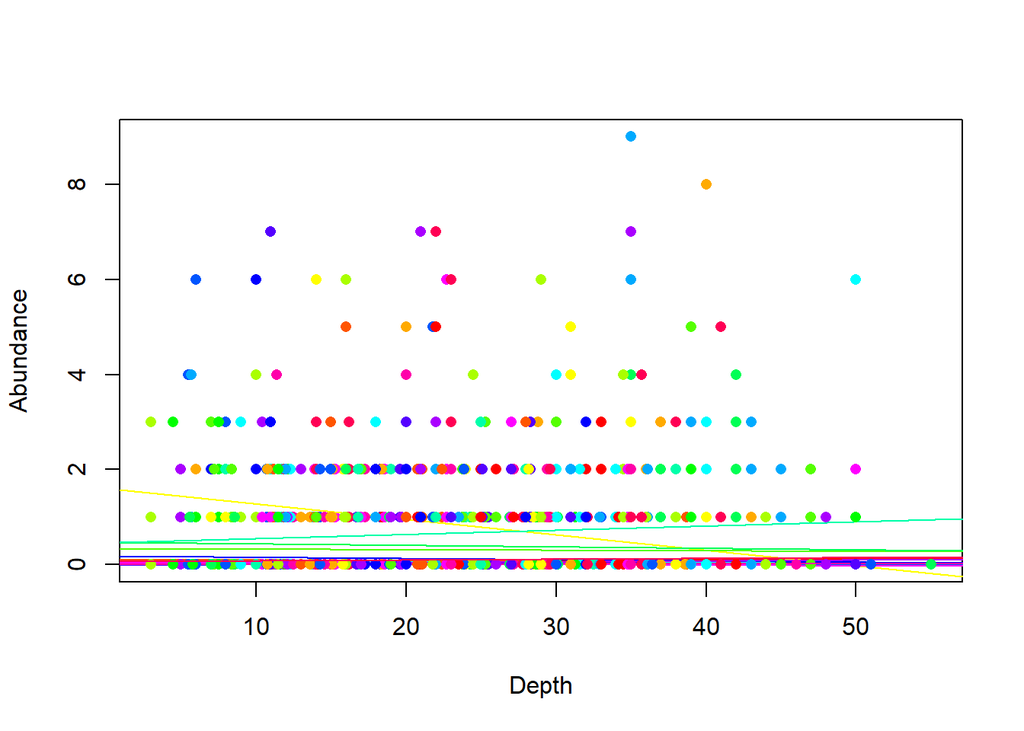

```r
#Read in the data:

env <- read.csv("c:/Users/gjosg/Dropbox/R_Handbook_2020_UVic/Data/BRUV_environmentals.csv") #environmental data
abundance <- read.csv("c:/Users/gjosg/Dropbox/R_Handbook_2020_UVic/Data/BRUV_abundance.csv") # shark and ray abundance

sharkCounts <- abundance[,-c(1:4)] #remove extra columns from abundance data so it is only counts

#establish colour palette to pull from, one colour for each shark:
colours <- rainbow(ncol(sharkCounts)) #look up different colour palettes and try different ones

#find the max abundance over all species to set plot's y limit:

max <- max(sharkCounts)

#for loop to plot relationship between each species and depth, as well as the regression line

plot(sharkCounts[,1]~env$Depth, col=colours[1], pch=16, ylab="Abundance", xlab="Depth", ylim=c(0, max))#initialize plot with one species
abline(lm(sharkCounts[,1]~env$Depth), col=colours[1],)

#use for loop for remaining species
for (i in 2:ncol(sharkCounts)) {
  points(sharkCounts[,i]~env$Depth, col=colours[], pch=16, ylab="Abundance", xlab="Depth")#initialize plot with one species
  abline(lm(sharkCounts[,i]~env$Depth), col=colours[i],)
}
```

Nested for loops to make multiple plots and add multiple lines to those plots:

Example: separate plot for each protection level in each area, with different coloured lines and points for each species:

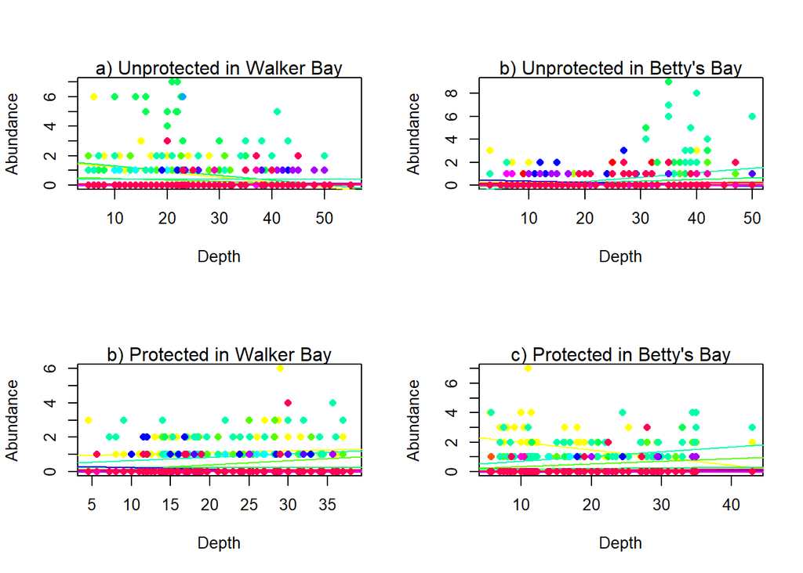

```r
#Read in the data:

env <- read.csv("c:/Users/gjosg/Dropbox/R_Handbook_2020_UVic/Data/BRUV_environmentals.csv") #environmental data
abundance <- read.csv("c:/Users/gjosg/Dropbox/R_Handbook_2020_UVic/Data/BRUV_abundance.csv") # shark and ray abundance

sharkCounts <- abundance[,-c(1:4)] #remove extra columns from abundance data so it is only counts

#establish colour palette to pull from, one colour for each shark:
colours <- rainbow(ncol(sharkCounts)) #look up different colour palettes and try different ones

#find the max abundance over all species to set plot's y limit:

#for loop to plot relationship between each species and depth, as well as the regression line, in both protection levels of both areas:

letters <- c("a)", "b)", "c)", "d)") #set up letters for plot titles
RegionList <- unique(env$Region) # get unique regions
ProtectionList <- unique(env$Protection) #get unique protection levels


par(mfrow=c(2,2)) #set up place to put the plot

for (i in seq_along(RegionList)) {# each unique region
  for (j in seq_along(ProtectionList)) { #each unique protection level
    temp.env <- subset(env, Region == RegionList[i] & Protection == ProtectionList[j]) #subset environmental variables
    temp <- subset(sharkCounts, env$Region == RegionList[i] & env$Protection == ProtectionList[j])
    max <- max(temp)

    plot(temp[,1]~temp.env$Depth, col=colours[1], pch=16, ylab="Abundance", xlab="Depth", ylim=c(0, max)) #initialize plot with one species
    abline(lm(temp[,1]~temp.env$Depth), col=colours[1])
    mtext(side=3, paste(letters[(i+j-1)], ProtectionList[i], "in", RegionList[j], sep=" ")) #title for each plot, the letters, followed by region and protection level separated by a space"

    #use for loop for remaining species
    for (k in 2:ncol(temp)) {
      points(temp[,k]~temp.env$Depth, col=colours[k], pch=16, ylab="Abundance", xlab="Depth") #initialize plot with one species
      abline(lm(temp[,k]~temp.env$Depth), col=colours[k],)
    }

  }

}
```